# Project: Wrangle and Analyze Data

> A source for professional dog ratings, WeRateDogs' Twitter account is brought into focus in this project. Here, datasets pertaining to this Twitter account have been wrangled and analyzed to bring to light insights that are then visualized.

> WeRateDogs can be viewed here :https://twitter.com/dog_rates
- This project has two sections where section 1 is within this notebook. Section 1 is divided into two, data wrangling and data visualization.

## Section 1

Note: Section 1 workings are contained here, wrangle_act.ipynb Jupyter Notebook

### Part 1 : Data Wrangling

Data wrangling, which consists of:

- Gathering data
- Assessing data
- Cleaning data
- Store the clean DataFrame(s) in a CSV file with the main one named twitter_archive_master.csv

### Part 2 : Data Visualizations

1. Analyzing, and visualizing wrangled data

## Section 2

Note: This will be covered in a separate pdf and will not appear in this notebook

## 1. Reporting on data wrangling efforts and, data analyses and visualizations

# LIST OF CONTENTS

1. Part 1 : Data wrangling
   - Part 1 : Data wrangling - Gathering Data
   - Part 1 : Data wrangling - Assessing Data
   - Part 1 : FINDINGS
   - Part 1 : Data wrangling - Cleaning Data
2. Part 2 : Data Visualizations
   - Part 2 : Data Visualizations - Assessing data
   - Part 2 : Data Visualizations - Analyzing : Insights & Visualizations
3. Bibliography

## Part 1 : Data wrangling

## Part 1 : Data wrangling - Gathering Data

- Gather data from three sources
  1. WeRateDogs Twitter archive : twitter_archive_enhanced.csv (Provided by Udacity)
  2. tweet image prediction : image_predictions.tsv (Hosted on Udacity's servers)
  3. Query the Twitter API and store in tweet_json.txt (Use tweet_id from twitter archive to link with Twitter API and retrieve retweet count & favorite count)

Go back to list of contents

```python
# Import libraries

# basic
import pandas as pd
import numpy as np
import datetime as dt

from timeit import default_timer as timer
from bs4 import BeautifulSoup
import json
import os
from os.path import splitext
import re        #regular expressions
import requests
import tweepy
import wptools
import heapq # importing "heapq" to implement heap queue

# visualization
import matplotlib.pyplot as plt
%matplotlib inline
import seaborn as sns; sns.set(color_codes=True)
from wordcloud import WordCloud, STOPWORDS, ImageColorGenerator
from PIL import Image
from IPython.display import display
from IPython.display import Image as _Imgdis
import shutil
```

#### Gathering Data: Twitter Archive

- Read tweets from WeRateDogs Twitter archive gathered from Nov 2015 to Aug 2017
- This CSV file (twitter_archive_enhanced.csv) was provided by Udacity and it was manually uploaded into the directory using JupyterNotebook's dashboard (orange icon at the top of this notebook)

```python
# Read CSV file(twitter_archive_enhanced.csv)
twitter_archive = pd.read_csv('twitter-archive-enhanced.csv', sep=',')
twitter_archive.head(1)
```

|  | tweet_id | in_reply_to_status_id | in_reply_to_user_id | timestamp | source | text | retweeted_status_id | retweeted_status_user_id | retweeted_status_timestamp | expanded_urls | rating_numerator | rating_denominator | name | doggo | floofer | pupper | puppo |
| --- | --- | --- | --- | --- | --- | --- | --- | --- | --- | --- | --- | --- | --- | --- | --- | --- | --- |
| 0 | 892420643555336193 | NaN | NaN | 2017-08-01 16:23:56 +0000 | <a href="http://twitter.com/download/iphone" rel="nofollow">Twitter for iPhone</a> | This is Phineas. He's a mystical boy. Only ever appears in the hole of a donut. 13/10 https://t.co/MgUWQ76dJU | NaN | NaN | NaN | https://twitter.com/dog_rates/status/892420643555336193/photo/1 | 13 | 10 | Phineas | None | None | None | None |

#### Gathering Data: Image Predictions

- tweet image predictions, i.e., what breed of dog (or other object, animal, etc.)
- File (image_predictions.tsv) is hosted on Udacity's servers and programmatically downloaded using the Requests library

```python
# Retrieve data from URL programatically
url = "https://d17h27t6h515a5.cloudfront.net/topher/2017/August/599fd2ad_image-predictions/image-predictions.tsv"
response = requests.get(url)
response

# Create/Download TSV file
with open('./image-predictions.tsv', mode ='wb') as file:
    file.write(response.content)
```

```python
#Read TSV file
image_prediction = pd.read_csv('image-predictions.tsv', sep='\t')
image_prediction.head()
```

|  | tweet_id | jpg_url | img_num | p1 | p1_conf | p1_dog | p2 | p2_conf | p2_dog | p3 | p3_conf | p3_dog |
| --- | --- | --- | --- | --- | --- | --- | --- | --- | --- | --- | --- | --- |
| 0 | 666020888022790149 | https://pbs.twimg.com/media/CT4udn0WwAA0aMy.jpg | 1 | Welsh_springer_spaniel | 0.465074 | True | collie | 0.156665 | True | Shetland_sheepdog | 0.061428 | True |
| 1 | 666029285002620928 | https://pbs.twimg.com/media/CT42GRgUYAA5iDo.jpg | 1 | redbone | 0.506826 | True | miniature_pinscher | 0.074192 | True | Rhodesian_ridgeback | 0.072010 | True |
| 2 | 666033412701032449 | https://pbs.twimg.com/media/CT4521TWwAEvMyu.jpg | 1 | German_shepherd | 0.596461 | True | malinois | 0.138584 | True | bloodhound | 0.116197 | True |
| 3 | 666044226329800704 | https://pbs.twimg.com/media/CT5Dr8HUEAA-lEu.jpg | 1 | Rhodesian_ridgeback | 0.408143 | True | redbone | 0.360687 | True | miniature_pinscher | 0.222752 | True |
| 4 | 666049248165822465 | https://pbs.twimg.com/media/CT5IQmsXIAAKY4A.jpg | 1 | miniature_pinscher | 0.560311 | True | Rottweiler | 0.243682 | True | Doberman | 0.154629 | True |

#### Gathering Data: Twitter API

- Use tweet_id from twitter archive to link with Twitter API and retrieve both fields
  1. Declare Twitter consumer API keys, access tokens, access secrets
  2. Using the tweet IDs in the WeRateDogs Twitter archive, query the Twitter API for each tweet's JSON data using Python's Tweepy library
  3. store each tweet's entire set of JSON data in a file called tweet_json.txt file
  4. Each tweet's JSON data should be written to its own line.
  5. read this .txt file line by line into a pandas DataFrame with (at minimum) tweet ID, retweet count, and favorite count

```python
#Declare Twitter consumer API keys, access tokens, access secrets
consumer_key = '****'
consumer_secret = '****'
access_token = '****'
access_secret = '****'

auth = tweepy.OAuthHandler(consumer_key, consumer_secret)
auth.set_access_token(access_token, access_secret)

api = tweepy.API(auth, wait_on_rate_limit=True, wait_on_rate_limit_notify=True)
```

```python
# Using the tweet IDs in the WeRateDogs Twitter archive,
#  query the Twitter API for each tweet's JSON data using Python's Tweepy library

#   If the tweet json file does not exist, create it
tweet_json_file = 'tweet_json.txt'
exists = os.path.isfile(tweet_json_file)
if exists:
    print('{} already exists, no need to build the file again.'.format(tweet_json_file))
else:
# below code retrieved from instructor notes (twitter-api.py)
    count = 0
    fails_dict = {}
    start = timer()
    # Save each tweet's returned JSON as a new line in a .txt file
    with open('tweet_json.txt', 'w') as outfile:
        # This loop will likely take 20-30 minutes to run because of Twitter's rate limit
        for tweet_id in tweet_ids:
            count += 1
            print(str(count) + ": " + str(tweet_id))
            try:
                tweet = api.get_status(tweet_id, tweet_mode='extended')
                print("Success")
                json.dump(tweet._json, outfile)
                outfile.write('\n')
            except tweepy.TweepError as e:
                print("Fail")
                fails_dict[tweet_id] = e
                pass
    end = timer()
    print("Time taken to process loop: {} minutes".format((end - start)/60))
    print(fails_dict)
```

```
tweet_json.txt already exists, no need to build the file again.
```

```python
# load json data into pandas DataFrame

text_file_path = 'tweet_json.txt'
tweet_json_df = pd.read_json(text_file_path, encoding = 'utf-8', lines = True)

# extract columns that pertain to like and favorite counts
columns_of_interest = ['id', 'retweet_count', 'favorite_count']
tweet_json = tweet_json_df[columns_of_interest]
tweet_json.head()
```

|  | id | retweet_count | favorite_count |
| --- | --- | --- | --- |
| 0 | 892420643555336193 | 8008 | 37333 |
| 1 | 892177421306343426 | 5940 | 32088 |
| 2 | 891815181378084864 | 3928 | 24188 |
| 3 | 891689557279858688 | 8167 | 40635 |
| 4 | 891327558926688256 | 8848 | 38867 |

## Part 1 : Data wrangling - Assessing Data

- Assess data from three dataframes
  1. twitter_archive: WeRateDogs Twitter archive : twitter_archive_enhanced.csv (Provided by Udacity)
  2. image_prediction: tweet image prediction : image_predictions.tsv (Hosted on Udacity's servers)
  3. tweet_json: tweet_json.txt

Go back to list of contents

```python
# Diplay full values in column instead of truncated values
pd.set_option('display.max_colwidth', -1)
```

```python
# View  twitter_archive dataset for assessment
twitter_archive
```

|  | tweet_id | in_reply_to_status_id | in_reply_to_user_id | timestamp | source | text | retweeted_status_id | retweeted_status_user_id | retweeted_status_timestamp | expanded_urls | rating_numerator | rating_denominator | name | doggo | floofer | pupper | puppo |
| --- | --- | --- | --- | --- | --- | --- | --- | --- | --- | --- | --- | --- | --- | --- | --- | --- | --- |
| 0 | 892420643555336193 | NaN | NaN | 2017-08-01 16:23:56 +0000 | <a href="http://twitter.com/download/iphone" rel="nofollow">Twitter for iPhone</a> | This is Phineas. He's a mystical boy. Only ever appears in the hole of a donut. 13/10 https://t.co/MgUWQ76dJU | NaN | NaN | NaN | https://twitter.com/dog_rates/status/892420643555336193/photo/1 | 13 | 10 | Phineas | None | None | None | None |
| 1 | 892177421306343426 | NaN | NaN | 2017-08-01 00:17:27 +0000 | <a href="http://twitter.com/download/iphone" rel="nofollow">Twitter for iPhone</a> | This is Tilly. She's just checking pup on you. Hopes you're doing ok. If not, she's available for pats, snugs, boops, the whole bit. 13/10 https://t.co/0Xxu71qeIV | NaN | NaN | NaN | https://twitter.com/dog_rates/status/892177421306343426/photo/1 | 13 | 10 | Tilly | None | None | None | None |
| 2 | 891815181378084864 | NaN | NaN | 2017-07-31 00:18:03 +0000 | <a href="http://twitter.com/download/iphone" rel="nofollow">Twitter for iPhone</a> | This is Archie. He is a rare Norwegian Pouncing Corgo. Lives in the tall grass. You never know when one may strike. 12/10 https://t.co/wUnZnhtVJB | NaN | NaN | NaN | https://twitter.com/dog_rates/status/891815181378084864/photo/1 | 12 | 10 | Archie | None | None | None | None |
| 3 | 891689557279858688 | NaN | NaN | 2017-07-30 15:58:51 +0000 | <a href="http://twitter.com/download/iphone" rel="nofollow">Twitter for iPhone</a> | This is Darla. She commenced a snooze mid meal. 13/10 happens to the best of us https://t.co/tD36da7qLQ | NaN | NaN | NaN | https://twitter.com/dog_rates/status/891689557279858688/photo/1 | 13 | 10 | Darla | None | None | None | None |
| 4 | 891327558926688256 | NaN | NaN | 2017-07-29 16:00:24 +0000 | <a href="http://twitter.com/download/iphone" rel="nofollow">Twitter for iPhone</a> | This is Franklin. He would like you to stop calling him "cute." He is a very fierce shark and should be respected as such. 12/10 #BarkWeek https://t.co/AtUZn91f7f | NaN | NaN | NaN | https://twitter.com/dog_rates/status/891327558926688256/photo/1,https://twitter.com/dog_rates/status/891327558926688256/photo/1 | 12 | 10 | Franklin | None | None | None | None |
| 5 | 891087950875897856 | NaN | NaN | 2017-07-29 00:08:17 +0000 | <a href="http://twitter.com/download/iphone" rel="nofollow">Twitter for iPhone</a> | Here we have a majestic great white breaching off South Africa's coast. Absolutely h*ckin breathtaking. 13/10 (IG: tucker_marlo) #BarkWeek https://t.co/kQ04fDDRmh | NaN | NaN | NaN | https://twitter.com/dog_rates/status/891087950875897856/photo/1 | 13 | 10 | None | None | None | None | None |
| 6 | 890971913173991426 | NaN | NaN | 2017-07-28 16:27:12 +0000 | <a href="http://twitter.com/download/iphone" rel="nofollow">Twitter for iPhone</a> | Meet Jax. He enjoys ice cream so much he gets nervous around it. 13/10 help Jax enjoy more things by clicking below\n\nhttps://t.co/Zr4hWfAs1H https://t.co/tVJBRMnhxl | NaN | NaN | NaN | https://gofundme.com/ydvmve-surgery-for-jax,https://twitter.com/dog_rates/status/890971913173991426/photo/1 | 13 | 10 | Jax | None | None | None | None |
| 7 | 890729181411237888 | NaN | NaN | 2017-07-28 00:22:40 +0000 | <a href="http://twitter.com/download/iphone" rel="nofollow">Twitter for iPhone</a> | When you watch your owner call another dog a good boy but then they turn back to you and say you're a great boy. 13/10 https://t.co/v0nONBcwxq | NaN | NaN | NaN | https://twitter.com/dog_rates/status/890729181411237888/photo/1,https://twitter.com/dog_rates/status/890729181411237888/photo/1 | 13 | 10 | None | None | None | None | None |
| 8 | 890609185150312448 | NaN | NaN | 2017-07-27 16:25:51 +0000 | <a href="http://twitter.com/download/iphone" rel="nofollow">Twitter for iPhone</a> | This is Zoey. She doesn't want to be one of the scary sharks. Just wants to be a snuggly pettable boatpet. 13/10 #BarkWeek https://t.co/9TwLuAGH0b | NaN | NaN | NaN | https://twitter.com/dog_rates/status/890609185150312448/photo/1 | 13 | 10 | Zoey | None | None | None | None |
| 9 | 890240255349198849 | NaN | NaN | 2017-07-26 15:59:51 +0000 | <a href="http://twitter.com/download/iphone" rel="nofollow">Twitter for iPhone</a> | This is Cassie. She is a college pup. Studying international doggo communication and stick theory. 14/10 so elegant much sophisticate https://t.co/t1bfwz5S2A | NaN | NaN | NaN | https://twitter.com/dog_rates/status/890240255349198849/photo/1 | 14 | 10 | Cassie | doggo | None | None | None |
| 10 | 890006608113172480 | NaN | NaN | 2017-07-26 00:31:25 +0000 | <a href="http://twitter.com/download/iphone" rel="nofollow">Twitter for iPhone</a> | This is Koda. He is a South Australian deckshark. Deceptively deadly. Frighteningly majestic. 13/10 would risk a petting #BarkWeek https://t.co/dVPW0B0Mme | NaN | NaN | NaN | https://twitter.com/dog_rates/status/890006608113172480/photo/1,https://twitter.com/dog_rates/status/890006608113172480/photo/1 | 13 | 10 | Koda | None | None | None | None |
| 11 | 889880896479866881 | NaN | NaN | 2017-07-25 16:11:53 +0000 | <a href="http://twitter.com/download/iphone" rel="nofollow">Twitter for iPhone</a> | This is Bruno. He is a service shark. Only gets out of the water to assist you. 13/10 terrifyingly good boy https://t.co/u1XPQMl29g | NaN | NaN | NaN | https://twitter.com/dog_rates/status/889880896479866881/photo/1 | 13 | 10 | Bruno | None | None | None | None |
| 12 | 889665388333682689 | NaN | NaN | 2017-07-25 01:55:32 +0000 | <a href="http://twitter.com/download/iphone" rel="nofollow">Twitter for iPhone</a> | Here's a puppo that seems to be on the fence about something haha no but seriously someone help her. 13/10 https://t.co/BxvuXk0UCm | NaN | NaN | NaN | https://twitter.com/dog_rates/status/889665388333682689/photo/1 | 13 | 10 | None | None | None | None | puppo |
| 13 | 889638837579907072 | NaN | NaN | 2017-07-25 00:10:02 +0000 | <a href="http://twitter.com/download/iphone" rel="nofollow">Twitter for iPhone</a> | This is Ted. He does his best. Sometimes that's not enough. But it's ok. 12/10 would assist https://t.co/f8dEDcrKSR | NaN | NaN | NaN | https://twitter.com/dog_rates/status/889638837579907072/photo/1,https://twitter.com/dog_rates/status/889638837579907072/photo/1 | 12 | 10 | Ted | None | None | None | None |
| 14 | 889531135344209921 | NaN | NaN | 2017-07-24 17:02:04 +0000 | <a href="http://twitter.com/download/iphone" rel="nofollow">Twitter for iPhone</a> | This is Stuart. He's sporting his favorite fanny pack. Secretly filled with bones only. 13/10 puppared puppo #BarkWeek https://t.co/y70o6h3isq | NaN | NaN | NaN | https://twitter.com/dog_rates/status/889531135344209921/photo/1 | 13 | 10 | Stuart | None | None | None | puppo |
| 15 | 889278841981685760 | NaN | NaN | 2017-07-24 00:19:32 +0000 | <a href="http://twitter.com/download/iphone" rel="nofollow">Twitter for iPhone</a> | This is Oliver. You're witnessing one of his many brutal attacks. Seems to be playing with his victim. 13/10 fr*ckin frightening #BarkWeek https://t.co/WpHvrQedPb | NaN | NaN | NaN | https://twitter.com/dog_rates/status/889278841981685760/video/1 | 13 | 10 | Oliver | None | None | None | None |
| 16 | 888917238123831296 | NaN | NaN | 2017-07-23 00:22:39 +0000 | <a href="http://twitter.com/download/iphone" rel="nofollow">Twitter for iPhone</a> | This is Jim. He found a fren. Taught him how to sit like the good boys. 12/10 for both https://t.co/chxruIOUJN | NaN | NaN | NaN | https://twitter.com/dog_rates/status/888917238123831296/photo/1 | 12 | 10 | Jim | None | None | None | None |
| 17 | 888804989199671297 | NaN | NaN | 2017-07-22 16:56:37 +0000 | <a href="http://twitter.com/download/iphone" rel="nofollow">Twitter for iPhone</a> | This is Zeke. He has a new stick. Very proud of it. Would like you to throw it for him without taking it. 13/10 would do my best https://t.co/HTQ77yNQ5K | NaN | NaN | NaN | https://twitter.com/dog_rates/status/888804989199671297/photo/1,https://twitter.com/dog_rates/status/888804989199671297/photo/1 | 13 | 10 | Zeke | None | None | None | None |
| 18 | 888554962724278272 | NaN | NaN | 2017-07-22 00:23:06 +0000 | <a href="http://twitter.com/download/iphone" rel="nofollow">Twitter for iPhone</a> | This is Ralphus. He's powering up. Attempting maximum borkdrive. 13/10 inspirational af https://t.co/YnYAFCTTiK | NaN | NaN | NaN | https://twitter.com/dog_rates/status/888554962724278272/photo/1,https://twitter.com/dog_rates/status/888554962724278272/photo/1,https://twitter.com/dog_rates/status/888554962724278272/photo/1,https://… | 13 | 10 | Ralphus | None | None | None | None |
| 19 | 888202515573088257 | NaN | NaN | 2017-07-21 01:02:36 +0000 | <a href="http://twitter.com/download/iphone" rel="nofollow">Twitter for iPhone</a> | RT @dog_rates: This is Canela. She attempted some fancy porch pics. They were unsuccessful. 13/10 someone help her https://t.co/cLyzpcUcMX | 8.874740e+17 | 4.196984e+09 | 2017-07-19 00:47:34 +0000 | https://twitter.com/dog_rates/status/887473957103951883/photo/1,https://twitter.com/dog_rates/status/887473957103951883/photo/1,https://twitter.com/dog_rates/status/887473957103951883/photo/1,https://… | 13 | 10 | Canela | None | None | None | None |
| 20 | 888078434458587136 | NaN | NaN | 2017-07-20 16:49:33 +0000 | <a href="http://twitter.com/download/iphone" rel="nofollow">Twitter for iPhone</a> | This is Gerald. He was just told he didn't get the job he interviewed for. A h*ckin injustice. 12/10 didn't want the job anyway https://t.co/DK7iDPfuRX | NaN | NaN | NaN | https://twitter.com/dog_rates/status/888078434458587136/photo/1,https://twitter.com/dog_rates/status/888078434458587136/photo/1 | 12 | 10 | Gerald | None | None | None | None |
| 21 | 887705289381826560 | NaN | NaN | 2017-07-19 16:06:48 +0000 | <a href="http://twitter.com/download/iphone" rel="nofollow">Twitter for iPhone</a> | This is Jeffrey. He has a monopoly on the pool noodles. Currently running a 'boop for two' midweek sale. 13/10 h*ckin strategic https://t.co/PhrUk20Q64 | NaN | NaN | NaN | https://twitter.com/dog_rates/status/887705289381826560/photo/1 | 13 | 10 | Jeffrey | None | None | None | None |
| 22 | 887517139158093824 | NaN | NaN | 2017-07-19 03:39:09 +0000 | <a href="http://twitter.com/download/iphone" rel="nofollow">Twitter for iPhone</a> | I've yet to rate a Venezuelan Hover Wiener. This is such an honor. 14/10 paw-inspiring af (IG: roxy.thedoxy) https://t.co/20VrLAA8ba | NaN | NaN | NaN | https://twitter.com/dog_rates/status/887517139158093824/video/1 | 14 | 10 | such | None | None | None | None |
| 23 | 887473957103951883 | NaN | NaN | 2017-07-19 00:47:34 +0000 | <a href="http://twitter.com/download/iphone" rel="nofollow">Twitter for iPhone</a> | This is Canela. She attempted some fancy porch pics. They were unsuccessful. 13/10 someone help her https://t.co/cLyzpcUcMX | NaN | NaN | NaN | https://twitter.com/dog_rates/status/887473957103951883/photo/1,https://twitter.com/dog_rates/status/887473957103951883/photo/1 | 13 | 10 | Canela | None | None | None | None |
| 24 | 887343217045368832 | NaN | NaN | 2017-07-18 16:08:03 +0000 | <a href="http://twitter.com/download/iphone" rel="nofollow">Twitter for iPhone</a> | You may not have known you needed to see this today. 13/10 please enjoy (IG: emmylouroo) https://t.co/WZqNqygEyV | NaN | NaN | NaN | https://twitter.com/dog_rates/status/887343217045368832/video/1 | 13 | 10 | None | None | None | None | None |
| 25 | 887101392804085760 | NaN | NaN | 2017-07-18 00:07:08 +0000 | <a href="http://twitter.com/download/iphone" rel="nofollow">Twitter for iPhone</a> | This... is a Jubilant Antarctic House Bear. We only rate dogs. Please only send dogs. Thank you... 12/10 would suffocate in floof https://t.co/4Ad1jzJSdp | NaN | NaN | NaN | https://twitter.com/dog_rates/status/887101392804085760/photo/1 | 12 | 10 | None | None | None | None | None |
| 26 | 886983233522544640 | NaN | NaN | 2017-07-17 16:17:36 +0000 | <a href="http://twitter.com/download/iphone" rel="nofollow">Twitter for iPhone</a> | This is Maya. She's very shy. Rarely leaves her cup. 13/10 would find her an environment to thrive in https://t.co/I6oNy0CgiT | NaN | NaN | NaN | https://twitter.com/dog_rates/status/886983233522544640/photo/1,https://twitter.com/dog_rates/status/886983233522544640/photo/1 | 13 | 10 | Maya | None | None | None | None |
| 27 | 886736880519319552 | NaN | NaN | 2017-07-16 23:58:41 +0000 | <a href="http://twitter.com/download/iphone" rel="nofollow">Twitter for iPhone</a> | This is Mingus. He's a wonderful father to his smol pup. Confirmed 13/10, but he needs your help\n\nhttps://t.co/bVi0Yr4Cff https://t.co/ISvKOSkd5b | NaN | NaN | NaN | https://www.gofundme.com/mingusneedsus,https://twitter.com/dog_rates/status/886736880519319552/photo/1,https://twitter.com/dog_rates/status/886736880519319552/photo/1 | 13 | 10 | Mingus | None | None | None | None |
| 28 | 886680336477933568 | NaN | NaN | 2017-07-16 20:14:00 +0000 | <a href="http://twitter.com/download/iphone" rel="nofollow">Twitter for iPhone</a> | This is Derek. He's late for a dog meeting. 13/10 pet...al to the metal https://t.co/BCoWue0abA | NaN | NaN | NaN | https://twitter.com/dog_rates/status/886680336477933568/photo/1 | 13 | 10 | Derek | None | None | None | None |
| 29 | 886366144734445568 | NaN | NaN | 2017-07-15 23:25:31 +0000 | <a href="http://twitter.com/download/iphone" rel="nofollow">Twitter for iPhone</a> | This is Roscoe. Another pupper fallen victim to spontaneous tongue ejections. Get the BlepiPen immediate. 12/10 deep breaths Roscoe https://t.co/RGE08MIJox | NaN | NaN | NaN | https://twitter.com/dog_rates/status/886366144734445568/photo/1,https://twitter.com/dog_rates/status/886366144734445568/photo/1 | 12 | 10 | Roscoe | None | None | pupper | None |
| ... | ... | ... | ... | ... | ... | ... | ... | ... | ... | ... | ... | ... | ... | ... | ... | ... | ... |
| 2326 | 666411507551481857 | NaN | NaN | 2015-11-17 00:24:19 +0000 | <a href="http://twitter.com/download/iphone" rel="nofollow">Twitter for iPhone</a> | This is quite the dog. Gets really excited when not in water. Not very soft tho. Bad at fetch. Can't do tricks. 2/10 https://t.co/aMCTNWO94t | NaN | NaN | NaN | https://twitter.com/dog_rates/status/666411507551481857/photo/1 | 2 | 10 | quite | None | None | None | None |
| 2327 | 666407126856765440 | NaN | NaN | 2015-11-17 00:06:54 +0000 | <a href="http://twitter.com/download/iphone" rel="nofollow">Twitter for iPhone</a> | This is a southern Vesuvius bumblegruff. Can drive a truck (wow). Made friends with 5 other nifty dogs (neat). 7/10 https://t.co/LopTBkKa8h | NaN | NaN | NaN | https://twitter.com/dog_rates/status/666407126856765440/photo/1 | 7 | 10 | a | None | None | None | None |
| 2328 | 666396247373291520 | NaN | NaN | 2015-11-16 23:23:41 +0000 | <a href="http://twitter.com/download/iphone" rel="nofollow">Twitter for iPhone</a> | Oh goodness. A super rare northeast Qdoba kangaroo mix. Massive feet. No pouch (disappointing). Seems alert. 9/10 https://t.co/Dc7b0E8qFE | NaN | NaN | NaN | https://twitter.com/dog_rates/status/666396247373291520/photo/1 | 9 | 10 | None | None | None | None | None |
| 2329 | 666373753744588802 | NaN | NaN | 2015-11-16 21:54:18 +0000 | <a href="http://twitter.com/download/iphone" rel="nofollow">Twitter for iPhone</a> | Those are sunglasses and a jean jacket. 11/10 dog cool af https://t.co/uHXrPkUEyl | NaN | NaN | NaN | https://twitter.com/dog_rates/status/666373753744588802/photo/1 | 11 | 10 | None | None | None | None | None |
| 2330 | 666362758909284353 | NaN | NaN | 2015-11-16 21:10:36 +0000 | <a href="http://twitter.com/download/iphone" rel="nofollow">Twitter for iPhone</a> | Unique dog here. Very small. Lives in container of Frosted Flakes (?). Short legs. Must be rare 6/10 would still pet https://t.co/XMD9CwjEnM | NaN | NaN | NaN | https://twitter.com/dog_rates/status/666362758909284353/photo/1 | 6 | 10 | None | None | None | None | None |
| 2331 | 666353288456101888 | NaN | NaN | 2015-11-16 20:32:58 +0000 | <a href="http://twitter.com/download/iphone" rel="nofollow">Twitter for iPhone</a> | Here we have a mixed Asiago from the Galápagos Islands. Only one ear working. Big fan of marijuana carpet. 8/10 https://t.co/tltQ5w9aUO | NaN | NaN | NaN | https://twitter.com/dog_rates/status/666353288456101888/photo/1 | 8 | 10 | None | None | None | None | None |
| 2332 | 666345417576210432 | NaN | NaN | 2015-11-16 20:01:42 +0000 | <a href="http://twitter.com/download/iphone" rel="nofollow">Twitter for iPhone</a> | Look at this jokester thinking seat belt laws don't apply to him. Great tongue tho 10/10 https://t.co/VFKG1vxGjB | NaN | NaN | NaN | https://twitter.com/dog_rates/status/666345417576210432/photo/1 | 10 | 10 | None | None | None | None | None |
| 2333 | 666337882303524864 | NaN | NaN | 2015-11-16 19:31:45 +0000 | <a href="http://twitter.com/download/iphone" rel="nofollow">Twitter for iPhone</a> | This is an extremely rare horned Parthenon. Not amused. Wears shoes. Overall very nice. 9/10 would pet aggressively https://t.co/QpRjllzWAL | NaN | NaN | NaN | https://twitter.com/dog_rates/status/666337882303524864/photo/1 | 9 | 10 | an | None | None | None | None |
| 2334 | 666293911632134144 | NaN | NaN | 2015-11-16 16:37:02 +0000 | <a href="http://twitter.com/download/iphone" rel="nofollow">Twitter for iPhone</a> | This is a funny dog. Weird toes. Won't come down. Loves branch. Refuses to eat his food. Hard to cuddle with. 3/10 https://t.co/IIXis0zta0 | NaN | NaN | NaN | https://twitter.com/dog_rates/status/666293911632134144/photo/1 | 3 | 10 | a | None | None | None | None |
| 2335 | 666287406224695296 | NaN | NaN | 2015-11-16 16:11:11 +0000 | <a href="http://twitter.com/download/iphone" rel="nofollow">Twitter for iPhone</a> | This is an Albanian 3 1/2 legged Episcopalian. Loves well-polished hardwood flooring. Penis on the collar. 9/10 https://t.co/d9NcXFKwLv | NaN | NaN | NaN | https://twitter.com/dog_rates/status/666287406224695296/photo/1 | 1 | 2 | an | None | None | None | None |
| 2336 | 666273097616637952 | NaN | NaN | 2015-11-16 15:14:19 +0000 | <a href="http://twitter.com/download/iphone" rel="nofollow">Twitter for iPhone</a> | Can take selfies 11/10 https://t.co/ws2AMaNwPW | NaN | NaN | NaN | https://twitter.com/dog_rates/status/666273097616637952/photo/1 | 11 | 10 | None | None | None | None | None |
| 2337 | 666268910803644416 | NaN | NaN | 2015-11-16 14:57:41 +0000 | <a href="http://twitter.com/download/iphone" rel="nofollow">Twitter for iPhone</a> | Very concerned about fellow dog trapped in computer. 10/10 https://t.co/0yxApIikpk | NaN | NaN | NaN | https://twitter.com/dog_rates/status/666268910803644416/photo/1 | 10 | 10 | None | None | None | None | None |
| 2338 | 666104133288665088 | NaN | NaN | 2015-11-16 04:02:55 +0000 | <a href="http://twitter.com/download/iphone" rel="nofollow">Twitter for iPhone</a> | Not familiar with this breed. No tail (weird). Only 2 legs. Doesn't bark. Surprisingly quick. Shits eggs. 1/10 https://t.co/Asgdc6kuLX | NaN | NaN | NaN | https://twitter.com/dog_rates/status/666104133288665088/photo/1 | 1 | 10 | None | None | None | None | None |
| 2339 | 666102155909144576 | NaN | NaN | 2015-11-16 03:55:04 +0000 | <a href="http://twitter.com/download/iphone" rel="nofollow">Twitter for iPhone</a> | Oh my. Here you are seeing an Adobe Setter giving birth to twins!!! The world is an amazing place. 11/10 https://t.co/11LvqN4WLq | NaN | NaN | NaN | https://twitter.com/dog_rates/status/666102155909144576/photo/1 | 11 | 10 | None | None | None | None | None |
| 2340 | 666099513787052032 | NaN | NaN | 2015-11-16 03:44:34 +0000 | <a href="http://twitter.com/download/iphone" rel="nofollow">Twitter for iPhone</a> | Can stand on stump for what seems like a while. Built that birdhouse? Impressive. Made friends with a squirrel. 8/10 https://t.co/Ri4nMTLq5C | NaN | NaN | NaN | https://twitter.com/dog_rates/status/666099513787052032/photo/1 | 8 | 10 | None | None | None | None | None |
| 2341 | 666094000022159362 | NaN | NaN | 2015-11-16 03:22:39 +0000 | <a href="http://twitter.com/download/iphone" rel="nofollow">Twitter for iPhone</a> | This appears to be a Mongolian Presbyterian mix. Very tired. Tongue slip confirmed. 9/10 would lie down with https://t.co/mnioXo3IfP | NaN | NaN | NaN | https://twitter.com/dog_rates/status/666094000022159362/photo/1 | 9 | 10 | None | None | None | None | None |
| 2342 | 666082916733198337 | NaN | NaN | 2015-11-16 02:38:37 +0000 | <a href="http://twitter.com/download/iphone" rel="nofollow">Twitter for iPhone</a> | Here we have a well-established sunblockerspaniel. Lost his other flip-flop. 6/10 not very waterproof https://t.co/3RU6x0vHB7 | NaN | NaN | NaN | https://twitter.com/dog_rates/status/666082916733198337/photo/1 | 6 | 10 | None | None | None | None | None |
| 2343 | 666073100786774016 | NaN | NaN | 2015-11-16 01:59:36 +0000 | <a href="http://twitter.com/download/iphone" rel="nofollow">Twitter for iPhone</a> | Let's hope this flight isn't Malaysian (lol). What a dog! Almost completely camouflaged. 10/10 I trust this pilot https://t.co/Yk6GHE9tOY | NaN | NaN | NaN | https://twitter.com/dog_rates/status/666073100786774016/photo/1 | 10 | 10 | None | None | None | None | None |
| 2344 | 666071193221509120 | NaN | NaN | 2015-11-16 01:52:02 +0000 | <a href="http://twitter.com/download/iphone" rel="nofollow">Twitter for iPhone</a> | Here we have a northern speckled Rhododendron. Much sass. Gives 0 fucks. Good tongue. 9/10 would caress sensually https://t.co/ZoL8kq2XFx | NaN | NaN | NaN | https://twitter.com/dog_rates/status/666071193221509120/photo/1 | 9 | 10 | None | None | None | None | None |
| 2345 | 666063827256086533 | NaN | NaN | 2015-11-16 01:22:45 +0000 | <a href="http://twitter.com/download/iphone" rel="nofollow">Twitter for iPhone</a> | This is the happiest dog you will ever see. Very committed owner. Nice couch. 10/10 https://t.co/RhUEAloehK | NaN | NaN | NaN | https://twitter.com/dog_rates/status/666063827256086533/photo/1 | 10 | 10 | the | None | None | None | None |
| 2346 | 666058600524156928 | NaN | NaN | 2015-11-16 01:01:59 +0000 | <a href="http://twitter.com/download/iphone" rel="nofollow">Twitter for iPhone</a> | Here is the Rand Paul of retrievers folks! He's probably good at poker. Can drink beer (lol rad). 8/10 good dog https://t.co/pYAJkAe76p | NaN | NaN | NaN | https://twitter.com/dog_rates/status/666058600524156928/photo/1 | 8 | 10 | the | None | None | None | None |
| 2347 | 666057090499244032 | NaN | NaN | 2015-11-16 00:55:59 +0000 | <a href="http://twitter.com/download/iphone" rel="nofollow">Twitter for iPhone</a> | My oh my. This is a rare blond Canadian terrier on wheels. Only $8.98. Rather docile. 9/10 very rare https://t.co/yWBqbrzy8O | NaN | NaN | NaN | https://twitter.com/dog_rates/status/666057090499244032/photo/1 | 9 | 10 | a | None | None | None | None |
| 2348 | 666055525042405380 | NaN | NaN | 2015-11-16 00:49:46 +0000 | <a href="http://twitter.com/download/iphone" rel="nofollow">Twitter for iPhone</a> | Here is a Siberian heavily armored polar bear mix. Strong owner. 10/10 I would do unspeakable things to pet this dog https://t.co/rdivxLiqEt | NaN | NaN | NaN | https://twitter.com/dog_rates/status/666055525042405380/photo/1 | 10 | 10 | a | None | None | None | None |
| 2349 | 666051853826850816 | NaN | NaN | 2015-11-16 00:35:11 +0000 | <a href="http://twitter.com/download/iphone" rel="nofollow">Twitter for iPhone</a> | This is an odd dog. Hard on the outside but loving on the inside. Petting still fun. Doesn't play catch well. 2/10 https://t.co/v5A4vzSDdc | NaN | NaN | NaN | https://twitter.com/dog_rates/status/666051853826850816/photo/1 | 2 | 10 | an | None | None | None | None |
| 2350 | 666050758794694657 | NaN | NaN | 2015-11-16 00:30:50 +0000 | <a href="http://twitter.com/download/iphone" rel="nofollow">Twitter for iPhone</a> | This is a truly beautiful English Wilson Staff retriever. Has a nice phone. Privileged. 10/10 would trade lives with https://t.co/fvIbQfHjIe | NaN | NaN | NaN | https://twitter.com/dog_rates/status/666050758794694657/photo/1 | 10 | 10 | a | None | None | None | None |
| 2351 | 666049248165822465 | NaN | NaN | 2015-11-16 00:24:50 +0000 | <a href="http://twitter.com/download/iphone" rel="nofollow">Twitter for iPhone</a> | Here we have a 1949 1st generation vulpix. Enjoys sweat tea and Fox News. Cannot be phased. 5/10 https://t.co/4B7cOc1EDq | NaN | NaN | NaN | https://twitter.com/dog_rates/status/666049248165822465/photo/1 | 5 | 10 | None | None | None | None | None |
| 2352 | 666044226329800704 | NaN | NaN | 2015-11-16 00:04:52 +0000 | <a href="http://twitter.com/download/iphone" rel="nofollow">Twitter for iPhone</a> | This is a purebred Piers Morgan. Loves to Netflix and chill. Always looks like he forgot to unplug the iron. 6/10 https://t.co/DWnyCjf2mx | NaN | NaN | NaN | https://twitter.com/dog_rates/status/666044226329800704/photo/1 | 6 | 10 | a | None | None | None | None |
| 2353 | 666033412701032449 | NaN | NaN | 2015-11-15 23:21:54 +0000 | <a href="http://twitter.com/download/iphone" rel="nofollow">Twitter for iPhone</a> | Here is a very happy pup. Big fan of well-maintained decks. Just look at that tongue. 9/10 would cuddle af https://t.co/y671yMhoiR | NaN | NaN | NaN | https://twitter.com/dog_rates/status/666033412701032449/photo/1 | 9 | 10 | a | None | None | None | None |
| 2354 | 666029285002620928 | NaN | NaN | 2015-11-15 23:05:30 +0000 | <a href="http://twitter.com/download/iphone" rel="nofollow">Twitter for iPhone</a> | This is a western brown Mitsubishi terrier. Upset about leaf. Actually 2 dogs here. 7/10 would walk the shit out of https://t.co/r7mOb2m0UI | NaN | NaN | NaN | https://twitter.com/dog_rates/status/666029285002620928/photo/1 | 7 | 10 | a | None | None | None | None |
| 2355 | 666020888022790149 | NaN | NaN | 2015-11-15 22:32:08 +0000 | <a href="http://twitter.com/download/iphone" rel="nofollow">Twitter for iPhone</a> | Here we have a Japanese Irish Setter. Lost eye in Vietnam (?). Big fan of relaxing on stair. 8/10 would pet https://t.co/BLDqew2Ijj | NaN | NaN | NaN | https://twitter.com/dog_rates/status/666020888022790149/photo/1 | 8 | 10 | None | None | None | None | None |

2356 rows × 17 columns

```python
# View image_prediction dataset for assessment
image_prediction
```

|  | tweet_id | jpg_url | img_num | p1 | p1_conf | p1_dog | p2 | p2_conf | p2_dog | p3 | p3_conf | p3_dog |
| --- | --- | --- | --- | --- | --- | --- | --- | --- | --- | --- | --- | --- |
| 0 | 666020888022790149 | https://pbs.twimg.com/media/CT4udn0WwAA0aMy.jpg | 1 | Welsh_springer_spaniel | 0.465074 | True | collie | 0.156665 | True | Shetland_sheepdog | 0.061428 | True |
| 1 | 666029285002620928 | https://pbs.twimg.com/media/CT42GRgUYAA5iDo.jpg | 1 | redbone | 0.506826 | True | miniature_pinscher | 0.074192 | True | Rhodesian_ridgeback | 0.072010 | True |
| 2 | 666033412701032449 | https://pbs.twimg.com/media/CT4521TWwAEvMyu.jpg | 1 | German_shepherd | 0.596461 | True | malinois | 0.138584 | True | bloodhound | 0.116197 | True |
| 3 | 666044226329800704 | https://pbs.twimg.com/media/CT5Dr8HUEAA-lEu.jpg | 1 | Rhodesian_ridgeback | 0.408143 | True | redbone | 0.360687 | True | miniature_pinscher | 0.222752 | True |
| 4 | 666049248165822465 | https://pbs.twimg.com/media/CT5IQmsXIAAKY4A.jpg | 1 | miniature_pinscher | 0.560311 | True | Rottweiler | 0.243682 | True | Doberman | 0.154629 | True |
| 5 | 666050758794694657 | https://pbs.twimg.com/media/CT5Jof1WUAEuVxN.jpg | 1 | Bernese_mountain_dog | 0.651137 | True | English_springer | 0.263788 | True | Greater_Swiss_Mountain_dog | 0.016199 | True |
| 6 | 666051853826850816 | https://pbs.twimg.com/media/CT5KoJ1WoAAJash.jpg | 1 | box_turtle | 0.933012 | False | mud_turtle | 0.045885 | False | terrapin | 0.017885 | False |
| 7 | 666055525042405380 | https://pbs.twimg.com/media/CT5N9tpXIAAifs1.jpg | 1 | chow | 0.692517 | True | Tibetan_mastiff | 0.058279 | True | fur_coat | 0.054449 | False |
| 8 | 666057090499244032 | https://pbs.twimg.com/media/CT5PY90WoAAQGLo.jpg | 1 | shopping_cart | 0.962465 | False | shopping_basket | 0.014594 | False | golden_retriever | 0.007959 | True |
| 9 | 666058600524156928 | https://pbs.twimg.com/media/CT5Qw94XAAA_2dP.jpg | 1 | miniature_poodle | 0.201493 | True | komondor | 0.192305 | True | soft-coated_wheaten_terrier | 0.082086 | True |
| 10 | 666063827256086533 | https://pbs.twimg.com/media/CT5Vg_wXIAAXfnj.jpg | 1 | golden_retriever | 0.775930 | True | Tibetan_mastiff | 0.093718 | True | Labrador_retriever | 0.072427 | True |
| 11 | 666071193221509120 | https://pbs.twimg.com/media/CT5cN_3WEAAlOoZ.jpg | 1 | Gordon_setter | 0.503672 | True | Yorkshire_terrier | 0.174201 | True | Pekinese | 0.109454 | True |
| 12 | 666073100786774016 | https://pbs.twimg.com/media/CT5d9DZXAAALcwe.jpg | 1 | Walker_hound | 0.260857 | True | English_foxhound | 0.175382 | True | Ibizan_hound | 0.097471 | True |
| 13 | 666082916733198337 | https://pbs.twimg.com/media/CT5m4VGWEAAtKc8.jpg | 1 | pug | 0.489814 | True | bull_mastiff | 0.404722 | True | French_bulldog | 0.048960 | True |
| 14 | 666094000022159362 | https://pbs.twimg.com/media/CT5w9gUW4AAsBNN.jpg | 1 | bloodhound | 0.195217 | True | German_shepherd | 0.078260 | True | malinois | 0.075628 | True |
| 15 | 666099513787052032 | https://pbs.twimg.com/media/CT51-JJUEAA6hV8.jpg | 1 | Lhasa | 0.582330 | True | Shih-Tzu | 0.166192 | True | Dandie_Dinmont | 0.089688 | True |
| 16 | 666102155909144576 | https://pbs.twimg.com/media/CT54YGiWUAEZnoK.jpg | 1 | English_setter | 0.298617 | True | Newfoundland | 0.149842 | True | borzoi | 0.133649 | True |
| 17 | 666104133288665088 | https://pbs.twimg.com/media/CT56LSZWoAAlJj2.jpg | 1 | hen | 0.965932 | False | cock | 0.033919 | False | partridge | 0.000052 | False |
| 18 | 666268910803644416 | https://pbs.twimg.com/media/CT8QCd1WEAADXws.jpg | 1 | desktop_computer | 0.086502 | False | desk | 0.085547 | False | bookcase | 0.079480 | False |
| 19 | 666273097616637952 | https://pbs.twimg.com/media/CT8T1mtUwAA3aqm.jpg | 1 | Italian_greyhound | 0.176053 | True | toy_terrier | 0.111884 | True | basenji | 0.111152 | True |
| 20 | 666287406224695296 | https://pbs.twimg.com/media/CT8g3BpUEAAuFjg.jpg | 1 | Maltese_dog | 0.857531 | True | toy_poodle | 0.063064 | True | miniature_poodle | 0.025581 | True |
| 21 | 666293911632134144 | https://pbs.twimg.com/media/CT8mx7KW4AEQu8N.jpg | 1 | three-toed_sloth | 0.914671 | False | otter | 0.015250 | False | great_grey_owl | 0.013207 | False |
| 22 | 666337882303524864 | https://pbs.twimg.com/media/CT9OwFIWEAMuRje.jpg | 1 | ox | 0.416669 | False | Newfoundland | 0.278407 | True | groenendael | 0.102643 | True |
| 23 | 666345417576210432 | https://pbs.twimg.com/media/CT9Vn7PWoAA_ZCM.jpg | 1 | golden_retriever | 0.858744 | True | Chesapeake_Bay_retriever | 0.054787 | True | Labrador_retriever | 0.014241 | True |
| 24 | 666353288456101888 | https://pbs.twimg.com/media/CT9cx0tUEAAhNN_.jpg | 1 | malamute | 0.336874 | True | Siberian_husky | 0.147655 | True | Eskimo_dog | 0.093412 | True |
| 25 | 666362758909284353 | https://pbs.twimg.com/media/CT9lXGsUcAAyUFt.jpg | 1 | guinea_pig | 0.996496 | False | skunk | 0.002402 | False | hamster | 0.000461 | False |
| 26 | 666373753744588802 | https://pbs.twimg.com/media/CT9vZEYWUAAlZ05.jpg | 1 | soft-coated_wheaten_terrier | 0.326467 | True | Afghan_hound | 0.259551 | True | briard | 0.206803 | True |
| 27 | 666396247373291520 | https://pbs.twimg.com/media/CT-D2ZHWIAA3gK1.jpg | 1 | Chihuahua | 0.978108 | True | toy_terrier | 0.009397 | True | papillon | 0.004577 | True |
| 28 | 666407126856765440 | https://pbs.twimg.com/media/CT-NvwmW4AAugGZ.jpg | 1 | black-and-tan_coonhound | 0.529139 | True | bloodhound | 0.244220 | True | flat-coated_retriever | 0.173810 | True |
| 29 | 666411507551481857 | https://pbs.twimg.com/media/CT-RugiWIAELEaq.jpg | 1 | coho | 0.404640 | False | barracouta | 0.271485 | False | gar | 0.189945 | False |
| ... | ... | ... | ... | ... | ... | ... | ... | ... | ... | ... | ... | ... |
| 2045 | 886366144734445568 | https://pbs.twimg.com/media/DE0BTnQUwAApKEH.jpg | 1 | French_bulldog | 0.999201 | True | Chihuahua | 0.000361 | True | Boston_bull | 0.000076 | True |
| 2046 | 886680336477933568 | https://pbs.twimg.com/media/DE4fEDzWAAAyHMM.jpg | 1 | convertible | 0.738995 | False | sports_car | 0.139952 | False | car_wheel | 0.044173 | False |
| 2047 | 886736880519319552 | https://pbs.twimg.com/media/DE5Se8FXcAAJFx4.jpg | 1 | kuvasz | 0.309706 | True | Great_Pyrenees | 0.186136 | True | Dandie_Dinmont | 0.086346 | True |
| 2048 | 886983233522544640 | https://pbs.twimg.com/media/DE8yicJW0AAAvBJ.jpg | 2 | Chihuahua | 0.793469 | True | toy_terrier | 0.143528 | True | can_opener | 0.032253 | False |
| 2049 | 887101392804085760 | https://pbs.twimg.com/media/DE-eAq6UwAA-jaE.jpg | 1 | Samoyed | 0.733942 | True | Eskimo_dog | 0.035029 | True | Staffordshire_bullterrier | 0.029705 | True |
| 2050 | 887343217045368832 | https://pbs.twimg.com/ext_tw_video_thumb/887343120832229379/pu/img/6HSuFrW1lzI_9Mht.jpg | 1 | Mexican_hairless | 0.330741 | True | sea_lion | 0.275645 | False | Weimaraner | 0.134203 | True |
| 2051 | 887473957103951883 | https://pbs.twimg.com/media/DFDw2tyUQAAAFke.jpg | 2 | Pembroke | 0.809197 | True | Rhodesian_ridgeback | 0.054950 | True | beagle | 0.038915 | True |
| 2052 | 887517139158093824 | https://pbs.twimg.com/ext_tw_video_thumb/887517108413886465/pu/img/WanJKwssZj4VJvL9.jpg | 1 | limousine | 0.130432 | False | tow_truck | 0.029175 | False | shopping_cart | 0.026321 | False |
| 2053 | 887705289381826560 | https://pbs.twimg.com/media/DFHDQBbXgAEqY7t.jpg | 1 | basset | 0.821664 | True | redbone | 0.087582 | True | Weimaraner | 0.026236 | True |
| 2054 | 888078434458587136 | https://pbs.twimg.com/media/DFMWn56WsAAkA7B.jpg | 1 | French_bulldog | 0.995026 | True | pug | 0.000932 | True | bull_mastiff | 0.000903 | True |
| 2055 | 888202515573088257 | https://pbs.twimg.com/media/DFDw2tyUQAAAFke.jpg | 2 | Pembroke | 0.809197 | True | Rhodesian_ridgeback | 0.054950 | True | beagle | 0.038915 | True |
| 2056 | 888554962724278272 | https://pbs.twimg.com/media/DFTH_O-UQAACu20.jpg | 3 | Siberian_husky | 0.700377 | True | Eskimo_dog | 0.166511 | True | malamute | 0.111411 | True |
| 2057 | 888804989199671297 | https://pbs.twimg.com/media/DFWra-3VYAA2piG.jpg | 1 | golden_retriever | 0.469760 | True | Labrador_retriever | 0.184172 | True | English_setter | 0.073482 | True |
| 2058 | 888917238123831296 | https://pbs.twimg.com/media/DFYRgsOUQAARGhO.jpg | 1 | golden_retriever | 0.714719 | True | Tibetan_mastiff | 0.120184 | True | Labrador_retriever | 0.105506 | True |
| 2059 | 889278841981685760 | https://pbs.twimg.com/ext_tw_video_thumb/889278779352338437/pu/img/VlbFB3v8H8VwzVNY.jpg | 1 | whippet | 0.626152 | True | borzoi | 0.194742 | True | Saluki | 0.027351 | True |
| 2060 | 889531135344209921 | https://pbs.twimg.com/media/DFg_2PVW0AEHN3p.jpg | 1 | golden_retriever | 0.953442 | True | Labrador_retriever | 0.013834 | True | redbone | 0.007958 | True |
| 2061 | 889638837579907072 | https://pbs.twimg.com/media/DFihzFfXsAYGDPR.jpg | 1 | French_bulldog | 0.991650 | True | boxer | 0.002129 | True | Staffordshire_bullterrier | 0.001498 | True |
| 2062 | 889665388333682689 | https://pbs.twimg.com/media/DFi579UWsAAatzw.jpg | 1 | Pembroke | 0.966327 | True | Cardigan | 0.027356 | True | basenji | 0.004633 | True |
| 2063 | 889880896479866881 | https://pbs.twimg.com/media/DFl99B1WsAITKsg.jpg | 1 | French_bulldog | 0.377417 | True | Labrador_retriever | 0.151317 | True | muzzle | 0.082981 | False |
| 2064 | 890006608113172480 | https://pbs.twimg.com/media/DFnwSY4WAAAMliS.jpg | 1 | Samoyed | 0.957979 | True | Pomeranian | 0.013884 | True | chow | 0.008167 | True |
| 2065 | 890240255349198849 | https://pbs.twimg.com/media/DFrEyVuW0AAO3t9.jpg | 1 | Pembroke | 0.511319 | True | Cardigan | 0.451038 | True | Chihuahua | 0.029248 | True |
| 2066 | 890609185150312448 | https://pbs.twimg.com/media/DFwUU__XcAEpyXI.jpg | 1 | Irish_terrier | 0.487574 | True | Irish_setter | 0.193054 | True | Chesapeake_Bay_retriever | 0.118184 | True |
| 2067 | 890729181411237888 | https://pbs.twimg.com/media/DFyBahAVwAAhUTd.jpg | 2 | Pomeranian | 0.566142 | True | Eskimo_dog | 0.178406 | True | Pembroke | 0.076507 | True |
| 2068 | 890971913173991426 | https://pbs.twimg.com/media/DF1eOmZXUAALUcq.jpg | 1 | Appenzeller | 0.341703 | True | Border_collie | 0.199287 | True | ice_lolly | 0.193548 | False |
| 2069 | 891087950875897856 | https://pbs.twimg.com/media/DF3HwyEWsAABqE6.jpg | 1 | Chesapeake_Bay_retriever | 0.425595 | True | Irish_terrier | 0.116317 | True | Indian_elephant | 0.076902 | False |
| 2070 | 891327558926688256 | https://pbs.twimg.com/media/DF6hr6BUMAAzZgT.jpg | 2 | basset | 0.555712 | True | English_springer | 0.225770 | True | German_short-haired_pointer | 0.175219 | True |
| 2071 | 891689557279858688 | https://pbs.twimg.com/media/DF_q7IAWsAEuuN8.jpg | 1 | paper_towel | 0.170278 | False | Labrador_retriever | 0.168086 | True | spatula | 0.040836 | False |
| 2072 | 891815181378084864 | https://pbs.twimg.com/media/DGBdLU1WsAANxJ9.jpg | 1 | Chihuahua | 0.716012 | True | malamute | 0.078253 | True | kelpie | 0.031379 | True |
| 2073 | 892177421306343426 | https://pbs.twimg.com/media/DGGmoV4XsAAUL6n.jpg | 1 | Chihuahua | 0.323581 | True | Pekinese | 0.090647 | True | papillon | 0.068957 | True |
| 2074 | 892420643555336193 | https://pbs.twimg.com/media/DGKD1-bXoAAIAUK.jpg | 1 | orange | 0.097049 | False | bagel | 0.085851 | False | banana | 0.076110 | False |

2075 rows × 12 columns

```python
# View tweet_json dataset for assessment
tweet_json
```

|  | id | retweet_count | favorite_count |
| --- | --- | --- | --- |
| 0 | 892420643555336193 | 8008 | 37333 |
| 1 | 892177421306343426 | 5940 | 32088 |
| 2 | 891815181378084864 | 3928 | 24188 |
| 3 | 891689557279858688 | 8167 | 40635 |
| 4 | 891327558926688256 | 8848 | 38867 |
| 5 | 891087950875897856 | 2944 | 19537 |
| 6 | 890971913173991426 | 1946 | 11406 |
| 7 | 890729181411237888 | 17841 | 62945 |
| 8 | 890609185150312448 | 4044 | 26870 |
| 9 | 890240255349198849 | 6966 | 30795 |
| 10 | 890006608113172480 | 6932 | 29616 |
| 11 | 889880896479866881 | 4715 | 26860 |
| 12 | 889665388333682689 | 9489 | 46408 |
| 13 | 889638837579907072 | 4257 | 26150 |
| 14 | 889531135344209921 | 2133 | 14599 |
| 15 | 889278841981685760 | 5071 | 24349 |
| 16 | 888917238123831296 | 4251 | 28117 |
| 17 | 888804989199671297 | 4031 | 24679 |
| 18 | 888554962724278272 | 3331 | 19114 |
| 19 | 888078434458587136 | 3284 | 21000 |
| 20 | 887705289381826560 | 5092 | 29131 |
| 21 | 887517139158093824 | 11085 | 44690 |
| 22 | 887473957103951883 | 17073 | 66446 |
| 23 | 887343217045368832 | 9869 | 32477 |
| 24 | 887101392804085760 | 5640 | 29505 |
| 25 | 886983233522544640 | 7272 | 33859 |
| 26 | 886736880519319552 | 3066 | 11595 |
| 27 | 886680336477933568 | 4209 | 21646 |
| 28 | 886366144734445568 | 3015 | 20424 |
| 29 | 886267009285017600 | 4 | 116 |
| ... | ... | ... | ... |
| 2303 | 666411507551481857 | 316 | 425 |
| 2304 | 666407126856765440 | 36 | 103 |
| 2305 | 666396247373291520 | 80 | 161 |
| 2306 | 666373753744588802 | 86 | 179 |
| 2307 | 666362758909284353 | 542 | 750 |
| 2308 | 666353288456101888 | 71 | 211 |
| 2309 | 666345417576210432 | 130 | 281 |
| 2310 | 666337882303524864 | 87 | 188 |
| 2311 | 666293911632134144 | 334 | 482 |
| 2312 | 666287406224695296 | 63 | 141 |
| 2313 | 666273097616637952 | 74 | 166 |
| 2314 | 666268910803644416 | 32 | 99 |
| 2315 | 666104133288665088 | 6216 | 13843 |
| 2316 | 666102155909144576 | 11 | 75 |
| 2317 | 666099513787052032 | 63 | 147 |
| 2318 | 666094000022159362 | 69 | 158 |
| 2319 | 666082916733198337 | 42 | 109 |
| 2320 | 666073100786774016 | 152 | 309 |
| 2321 | 666071193221509120 | 55 | 140 |
| 2322 | 666063827256086533 | 205 | 458 |
| 2323 | 666058600524156928 | 56 | 108 |
| 2324 | 666057090499244032 | 132 | 280 |
| 2325 | 666055525042405380 | 228 | 420 |
| 2326 | 666051853826850816 | 811 | 1178 |
| 2327 | 666050758794694657 | 56 | 129 |
| 2328 | 666049248165822465 | 41 | 103 |
| 2329 | 666044226329800704 | 135 | 285 |
| 2330 | 666033412701032449 | 43 | 121 |
| 2331 | 666029285002620928 | 46 | 124 |
| 2332 | 666020888022790149 | 486 | 2485 |

2333 rows × 3 columns

```python
twitter_archive.info()
```

```
<class 'pandas.core.frame.DataFrame'>
RangeIndex: 2356 entries, 0 to 2355
Data columns (total 17 columns):
tweet_id                      2356 non-null int64
in_reply_to_status_id         78 non-null float64
in_reply_to_user_id           78 non-null float64
timestamp                     2356 non-null object
source                        2356 non-null object
text                          2356 non-null object
retweeted_status_id           181 non-null float64
retweeted_status_user_id      181 non-null float64
retweeted_status_timestamp    181 non-null object
expanded_urls                 2297 non-null object
rating_numerator              2356 non-null int64
rating_denominator            2356 non-null int64
name                          2356 non-null object
doggo                         2356 non-null object
floofer                       2356 non-null object
pupper                        2356 non-null object
puppo                         2356 non-null object
dtypes: float64(4), int64(3), object(10)
memory usage: 313.0+ KB
```

```python
image_prediction.info()
```

```
<class 'pandas.core.frame.DataFrame'>
RangeIndex: 2075 entries, 0 to 2074
Data columns (total 12 columns):
tweet_id    2075 non-null int64
jpg_url     2075 non-null object
img_num     2075 non-null int64
p1          2075 non-null object
p1_conf     2075 non-null float64
p1_dog      2075 non-null bool
p2          2075 non-null object
p2_conf     2075 non-null float64
p2_dog      2075 non-null bool
p3          2075 non-null object
p3_conf     2075 non-null float64
p3_dog      2075 non-null bool
dtypes: bool(3), float64(3), int64(2), object(4)
memory usage: 152.1+ KB
```

```python
tweet_json.info()
```

```
<class 'pandas.core.frame.DataFrame'>
RangeIndex: 2333 entries, 0 to 2332
Data columns (total 3 columns):
id                2333 non-null int64
retweet_count     2333 non-null int64
favorite_count    2333 non-null int64
dtypes: int64(3)
memory usage: 54.8 KB
```

```python
twitter_archive.describe()
```

|  | tweet_id | in_reply_to_status_id | in_reply_to_user_id | retweeted_status_id | retweeted_status_user_id | rating_numerator | rating_denominator |
| --- | --- | --- | --- | --- | --- | --- | --- |
| count | 2.356000e+03 | 7.800000e+01 | 7.800000e+01 | 1.810000e+02 | 1.810000e+02 | 2356.000000 | 2356.000000 |
| mean | 7.427716e+17 | 7.455079e+17 | 2.014171e+16 | 7.720400e+17 | 1.241698e+16 | 13.126486 | 10.455433 |
| std | 6.856705e+16 | 7.582492e+16 | 1.252797e+17 | 6.236928e+16 | 9.599254e+16 | 45.876648 | 6.745237 |
| min | 6.660209e+17 | 6.658147e+17 | 1.185634e+07 | 6.661041e+17 | 7.832140e+05 | 0.000000 | 0.000000 |
| 25% | 6.783989e+17 | 6.757419e+17 | 3.086374e+08 | 7.186315e+17 | 4.196984e+09 | 10.000000 | 10.000000 |
| 50% | 7.196279e+17 | 7.038708e+17 | 4.196984e+09 | 7.804657e+17 | 4.196984e+09 | 11.000000 | 10.000000 |
| 75% | 7.993373e+17 | 8.257804e+17 | 4.196984e+09 | 8.203146e+17 | 4.196984e+09 | 12.000000 | 10.000000 |
| max | 8.924206e+17 | 8.862664e+17 | 8.405479e+17 | 8.874740e+17 | 7.874618e+17 | 1776.000000 | 170.000000 |

```python
image_prediction.describe()
```

|  | tweet_id | img_num | p1_conf | p2_conf | p3_conf |
| --- | --- | --- | --- | --- | --- |
| count | 2.075000e+03 | 2075.000000 | 2075.000000 | 2.075000e+03 | 2.075000e+03 |
| mean | 7.384514e+17 | 1.203855 | 0.594548 | 1.345886e-01 | 6.032417e-02 |
| std | 6.785203e+16 | 0.561875 | 0.271174 | 1.006657e-01 | 5.090593e-02 |
| min | 6.660209e+17 | 1.000000 | 0.044333 | 1.011300e-08 | 1.740170e-10 |
| 25% | 6.764835e+17 | 1.000000 | 0.364412 | 5.388625e-02 | 1.622240e-02 |
| 50% | 7.119988e+17 | 1.000000 | 0.588230 | 1.181810e-01 | 4.944380e-02 |
| 75% | 7.932034e+17 | 1.000000 | 0.843855 | 1.955655e-01 | 9.180755e-02 |
| max | 8.924206e+17 | 4.000000 | 1.000000 | 4.880140e-01 | 2.734190e-01 |

```python
tweet_json.describe()
```

|  | id | retweet_count | favorite_count |
| --- | --- | --- | --- |
| count | 2.333000e+03 | 2333.000000 | 2333.000000 |
| mean | 7.419023e+17 | 2815.953708 | 7783.350193 |
| std | 6.818084e+16 | 4763.307952 | 12075.065473 |
| min | 6.660209e+17 | 1.000000 | 0.000000 |
| 25% | 6.782786e+17 | 566.000000 | 1356.000000 |
| 50% | 7.184547e+17 | 1317.000000 | 3389.000000 |
| 75% | 7.986440e+17 | 3283.000000 | 9547.000000 |
| max | 8.924206e+17 | 80853.000000 | 161229.000000 |

```python
# Check for duplicated columns in all 3 datasets
all_columns = pd.Series(list(twitter_archive) + list(image_prediction) + list(tweet_json))
all_columns[all_columns.duplicated()]
```

```
17    tweet_id
dtype: object
```

```python
# Find null values for all columns in twitter_archive
null_columns=twitter_archive.columns[twitter_archive.isnull().any()]
twitter_archive[null_columns].isnull().sum()
```

```
in_reply_to_status_id         2278
in_reply_to_user_id           2278
retweeted_status_id           2175
retweeted_status_user_id      2175
retweeted_status_timestamp    2175
expanded_urls                 59
dtype: int64
```

```python
# Column text has links attached to text
twitter_archive.text.sample(5)
```

```
649     Here is a perfect example of someone who has their priorities in order. 13/10 for both owner and Forrest https://t.co/LRyMrU7Wfq
2021    This is Patch. He wants to be a Christmas tree. 11/10 https://t.co/WTJtf9O8Jg
2256    This is Calvin. He is a Luxembourgian Mayo. Having issues with truck. Has it under control tho. 9/10 responsible af https://t.co/3Bbba7y8Xe
734     This is Oakley. He just got yelled at for going 46 in a 45. Churlish af. 11/10 would still pet so well https://t.co/xIYsa6LPA4
2270    Say hello to Hall and Oates. Oates is winking and Hall is contemplating the artistic entropy of the universe. 11/10s https://t.co/n5Wtb5Hvsl
Name: text, dtype: object
```

```python
# Check on names
twitter_archive.name.unique()
```

```
array(['Phineas', 'Tilly', 'Archie', 'Darla', 'Franklin', 'None', 'Jax',
       'Zoey', 'Cassie', 'Koda', 'Bruno', 'Ted', 'Stuart', 'Oliver', 'Jim',
       'Zeke', 'Ralphus', 'Canela', 'Gerald', 'Jeffrey', 'such', 'Maya',
       'Mingus', 'Derek', 'Roscoe', 'Waffles', 'Jimbo', 'Maisey', 'Lilly',
       'Earl', 'Lola', 'Kevin', 'Yogi', 'Noah', 'Bella', 'Grizzwald',
       'Rusty', 'Gus', 'Stanley', 'Alfy', 'Koko', 'Rey', 'Gary', 'a',
       'Elliot', 'Louis', 'Jesse', 'Romeo', 'Bailey', 'Duddles', 'Jack',
       'Emmy', 'Steven', 'Beau', 'Snoopy', 'Shadow', 'Terrance', 'Aja',
       'Penny', 'Dante', 'Nelly', 'Ginger', 'Benedict', 'Venti', 'Goose',
       'Nugget', 'Cash', 'Coco', 'Jed', 'Sebastian', 'Walter', 'Sierra',
       'Monkey', 'Harry', 'Kody', 'Lassie', 'Rover', 'Napolean', 'Dawn',
       'Boomer', 'Cody', 'Rumble', 'Clifford', 'quite', 'Dewey', 'Scout',
       'Gizmo', 'Cooper', 'Harold', 'Shikha', 'Jamesy', 'Lili', 'Sammy',
       'Meatball', 'Paisley', 'Albus', 'Neptune', 'Quinn', 'Belle',
       'Zooey', 'Dave', 'Jersey', 'Hobbes', 'Burt', 'Lorenzo', 'Carl',
       'Jordy', 'Milky', 'Trooper', 'Winston', 'Sophie', 'Wyatt', 'Rosie',
       'Thor', 'Oscar', 'Luna', 'Callie', 'Cermet', 'George', 'Marlee',
       'Arya', 'Einstein', 'Alice', 'Rumpole', 'Benny', 'Aspen', 'Jarod',
       'Wiggles', 'General', 'Sailor', 'Astrid', 'Iggy', 'Snoop', 'Kyle',
       'Leo', 'Riley', 'Gidget', 'Noosh', 'Odin', 'Jerry', 'Charlie',
       'Georgie', 'Rontu', 'Cannon', 'Furzey', 'Daisy', 'Tuck', 'Barney',
       'Vixen', 'Jarvis', 'Mimosa', 'Pickles', 'Bungalo', 'Brady', 'Margo',
       'Sadie', 'Hank', 'Tycho', 'Stephan', 'Indie', 'Winnie', 'Bentley',
       'Ken', 'Max', 'Maddie', 'Pipsy', 'Monty', 'Sojourner', 'Odie',
       'Arlo', 'Sunny', 'Vincent', 'Lucy', 'Clark', 'Mookie', 'Meera',
       'Buddy', 'Ava', 'Rory', 'Eli', 'Ash', 'Tucker', 'Tobi', 'Chester',
       'Wilson', 'Sunshine', 'Lipton', 'Gabby', 'Bronte', 'Poppy', 'Rhino',
       'Willow', 'not', 'Orion', 'Eevee', 'Smiley', 'Logan', 'Moreton',
       'Klein', 'Miguel', 'Emanuel', 'Kuyu', 'Dutch', 'Pete', 'Scooter',
       'Reggie', 'Kyro', 'Samson', 'Loki', 'Mia', 'Malcolm', 'Dexter',
       'Alfie', 'Fiona', 'one', 'Mutt', 'Bear', 'Doobert', 'Beebop',
       'Alexander', 'Sailer', 'Brutus', 'Kona', 'Boots', 'Ralphie', 'Phil',
       'Cupid', 'Pawnd', 'Pilot', 'Ike', 'Mo', 'Toby', 'Sweet', 'Pablo',
       'Nala', 'Balto', 'Crawford', 'Gabe', 'Mattie', 'Jimison',
       'Hercules', 'Duchess', 'Harlso', 'Sampson', 'Sundance', 'Luca',
       'Flash', 'Finn', 'Peaches', 'Howie', 'Jazzy', 'Anna', 'Bo',
       'Seamus', 'Wafer', 'Chelsea', 'Tom', 'Moose', 'Florence', 'Autumn',
       'Dido', 'Eugene', 'Herschel', 'Strudel', 'Tebow', 'Chloe', 'Betty',
       'Timber', 'Binky', 'Dudley', 'Comet', 'Larry', 'Levi', 'Akumi',
       'Titan', 'Olivia', 'Alf', 'Oshie', 'Bruce', 'Chubbs', 'Sky',
```

[output cut: 85 more lines]

```
       'Julius', 'Tanner', 'Sparky', 'Anthony', 'Holly', 'Jett', 'Amy',
       'Sage', 'Andy', 'Mason', 'Trigger', 'Antony', 'Creg', 'Traviss',
       'Gin', 'Jeffrie', 'Danny', 'Ester', 'Pluto', 'Bloo', 'Edd', 'Willy',
       'Herb', 'Damon', 'Peanut', 'Nigel', 'Butters', 'Sandra', 'Fabio',
       'Randall', 'Liam', 'Tommy', 'Ben', 'Raphael', 'Julio', 'Andru',
       'Kloey', 'Shawwn', 'Skye', 'Kollin', 'Ronduh', 'Billl', 'Saydee',
       'Dug', 'Tessa', 'Sully', 'Kirk', 'Ralf', 'Clarq', 'Jaspers',
       'Samsom', 'Harrison', 'Chaz', 'Jeremy', 'Jaycob', 'Lambeau',
       'Ruffles', 'Amélie', 'Bobb', 'Banditt', 'Kevon', 'Winifred', 'Hanz',
       'Churlie', 'Zeek', 'Timofy', 'Maks', 'Jomathan', 'Kallie', 'Marvin',
       'Spark', 'Gòrdón', 'Jo', 'DayZ', 'Jareld', 'Torque', 'Ron',
       'Skittles', 'Cleopatricia', 'Erik', 'Stu', 'Tedrick', 'Filup',
       'Kial', 'Naphaniel', 'Dook', 'Hall', 'Philippe', 'Biden', 'Fwed',
       'Genevieve', 'Joshwa', 'Bradlay', 'Clybe', 'Keet', 'Carll',
       'Jockson', 'Josep', 'Lugan', 'Christoper'], dtype=object)
```

```python
# Check for names stored in lowercase
s= twitter_archive.name
lowercase_letters = [c for c in s if c.islower()]
weird_names=[np.unique(lowercase_letters)]
weird_names
```

```
[array(['a', 'actually', 'all', 'an', 'by', 'getting', 'his', 'incredibly',
        'infuriating', 'just', 'life', 'light', 'mad', 'my', 'not',
        'officially', 'old', 'one', 'quite', 'space', 'such', 'the', 'this',
        'unacceptable', 'very'],
       dtype='<U12')]
```

```python
# Check number of records of retweets in twitter_archive table
#twitter_archive.retweeted_status_id.value_counts().sum()
twitter_archive.retweeted_status_id.notnull().sum()
```

```
181
```

```python
# Check number of replies to status
twitter_archive.in_reply_to_status_id.value_counts().sum()
```

```
78
```

```python
# Check number of replies to user
twitter_archive.in_reply_to_user_id.notnull().sum()
```

```
78
```

```python
# Look for null favorite and retweets in twitter_archive
twitter_archive[((twitter_archive.in_reply_to_user_id.isnull()) & twitter_archive.retweeted_status_id.isnull())].count()
```

```
tweet_id                      2097
in_reply_to_status_id         0
in_reply_to_user_id           0
timestamp                     2097
source                        2097
text                          2097
retweeted_status_id           0
retweeted_status_user_id      0
retweeted_status_timestamp    0
expanded_urls                 2094
rating_numerator              2097
rating_denominator            2097
name                          2097
doggo                         2097
floofer                       2097
pupper                        2097
puppo                         2097
dtype: int64
```

```python
# Find for duplicated tweet_id in twitter_archive
sum(twitter_archive['tweet_id'].duplicated())
```

```
0
```

```python
# Lookout for number of records that are not none
(twitter_archive.loc[:,'doggo':'puppo'] != 'None').sum()
```

```
doggo      97
floofer    10
pupper     257
puppo      30
dtype: int64
```

```python
# Lookout for number of records that are blank/none
(twitter_archive.loc[:,'doggo':'puppo'] == 'None').sum()
```

```
doggo      2259
floofer    2346
pupper     2099
puppo      2326
dtype: int64
```

```python
#  Display combinations of the various dog stages
(twitter_archive.doggo + twitter_archive.floofer +
                         twitter_archive.pupper +
                         twitter_archive.puppo).value_counts()
```

```
NoneNoneNoneNone        1976
NoneNonepupperNone      245
doggoNoneNoneNone       83
NoneNoneNonepuppo       29
doggoNonepupperNone     12
NoneflooferNoneNone     9
doggoflooferNoneNone    1
doggoNoneNonepuppo      1
dtype: int64
```

```python
twitter_archive.query("floofer != 'None' & doggo != 'None'")
twitter_archive.query("doggo!= 'None' & pupper != 'None'")
```

|  | tweet_id | in_reply_to_status_id | in_reply_to_user_id | timestamp | source | text | retweeted_status_id | retweeted_status_user_id | retweeted_status_timestamp | expanded_urls | rating_numerator | rating_denominator | name | doggo | floofer | pupper | puppo |
| --- | --- | --- | --- | --- | --- | --- | --- | --- | --- | --- | --- | --- | --- | --- | --- | --- | --- |
| 460 | 817777686764523521 | NaN | NaN | 2017-01-07 16:59:28 +0000 | <a href="http://twitter.com/download/iphone" rel="nofollow">Twitter for iPhone</a> | This is Dido. She's playing the lead role in "Pupper Stops to Catch Snow Before Resuming Shadow Box with Dried Apple." 13/10 (IG: didodoggo) https://t.co/m7isZrOBX7 | NaN | NaN | NaN | https://twitter.com/dog_rates/status/817777686764523521/video/1 | 13 | 10 | Dido | doggo | None | pupper | None |
| 531 | 808106460588765185 | NaN | NaN | 2016-12-12 00:29:28 +0000 | <a href="http://twitter.com/download/iphone" rel="nofollow">Twitter for iPhone</a> | Here we have Burke (pupper) and Dexter (doggo). Pupper wants to be exactly like doggo. Both 12/10 would pet at same time https://t.co/ANBpEYHaho | NaN | NaN | NaN | https://twitter.com/dog_rates/status/808106460588765185/photo/1 | 12 | 10 | None | doggo | None | pupper | None |
| 565 | 802265048156610565 | 7.331095e+17 | 4.196984e+09 | 2016-11-25 21:37:47 +0000 | <a href="http://twitter.com/download/iphone" rel="nofollow">Twitter for iPhone</a> | Like doggo, like pupper version 2. Both 11/10 https://t.co/9IxWAXFqze | NaN | NaN | NaN | https://twitter.com/dog_rates/status/802265048156610565/photo/1 | 11 | 10 | None | doggo | None | pupper | None |
| 575 | 801115127852503040 | NaN | NaN | 2016-11-22 17:28:25 +0000 | <a href="http://twitter.com/download/iphone" rel="nofollow">Twitter for iPhone</a> | This is Bones. He's being haunted by another doggo of roughly the same size. 12/10 deep breaths pupper everything's fine https://t.co/55Dqe0SJNj | NaN | NaN | NaN | https://twitter.com/dog_rates/status/801115127852503040/photo/1,https://twitter.com/dog_rates/status/801115127852503040/photo/1 | 12 | 10 | Bones | doggo | None | pupper | None |
| 705 | 785639753186217984 | NaN | NaN | 2016-10-11 00:34:48 +0000 | <a href="http://twitter.com/download/iphone" rel="nofollow">Twitter for iPhone</a> | This is Pinot. He's a sophisticated doggo. You can tell by the hat. Also pointier than your average pupper. Still 10/10 would pet cautiously https://t.co/f2wmLZTPHd | NaN | NaN | NaN | https://twitter.com/dog_rates/status/785639753186217984/photo/1,https://twitter.com/dog_rates/status/785639753186217984/photo/1 | 10 | 10 | Pinot | doggo | None | pupper | None |
| 733 | 781308096455073793 | NaN | NaN | 2016-09-29 01:42:20 +0000 | <a href="http://vine.co" rel="nofollow">Vine - Make a Scene</a> | Pupper butt 1, Doggo 0. Both 12/10 https://t.co/WQvcPEpH2u | NaN | NaN | NaN | https://vine.co/v/5rgu2Law2ut | 12 | 10 | None | doggo | None | pupper | None |
| 778 | 775898661951791106 | NaN | NaN | 2016-09-14 03:27:11 +0000 | <a href="http://twitter.com/download/iphone" rel="nofollow">Twitter for iPhone</a> | RT @dog_rates: Like father (doggo), like son (pupper). Both 12/10 https://t.co/pG2inLaOda | 7.331095e+17 | 4.196984e+09 | 2016-05-19 01:38:16 +0000 | https://twitter.com/dog_rates/status/733109485275860992/photo/1,https://twitter.com/dog_rates/status/733109485275860992/photo/1 | 12 | 10 | None | doggo | None | pupper | None |
| 822 | 770093767776997377 | NaN | NaN | 2016-08-29 03:00:36 +0000 | <a href="http://twitter.com/download/iphone" rel="nofollow">Twitter for iPhone</a> | RT @dog_rates: This is just downright precious af. 12/10 for both pupper and doggo https://t.co/o5J479bZUC | 7.410673e+17 | 4.196984e+09 | 2016-06-10 00:39:48 +0000 | https://twitter.com/dog_rates/status/741067306818797568/photo/1,https://twitter.com/dog_rates/status/741067306818797568/photo/1 | 12 | 10 | just | doggo | None | pupper | None |
| 889 | 759793422261743616 | NaN | NaN | 2016-07-31 16:50:42 +0000 | <a href="http://twitter.com/download/iphone" rel="nofollow">Twitter for iPhone</a> | Meet Maggie &amp; Lila. Maggie is the doggo, Lila is the pupper. They are sisters. Both 12/10 would pet at the same time https://t.co/MYwR4DQKll | NaN | NaN | NaN | https://twitter.com/dog_rates/status/759793422261743616/photo/1,https://twitter.com/dog_rates/status/759793422261743616/photo/1 | 12 | 10 | Maggie | doggo | None | pupper | None |
| 956 | 751583847268179968 | NaN | NaN | 2016-07-09 01:08:47 +0000 | <a href="http://twitter.com/download/iphone" rel="nofollow">Twitter for iPhone</a> | Please stop sending it pictures that don't even have a doggo or pupper in them. Churlish af. 5/10 neat couch tho https://t.co/u2c9c7qSg8 | NaN | NaN | NaN | https://twitter.com/dog_rates/status/751583847268179968/photo/1 | 5 | 10 | None | doggo | None | pupper | None |
| 1063 | 741067306818797568 | NaN | NaN | 2016-06-10 00:39:48 +0000 | <a href="http://twitter.com/download/iphone" rel="nofollow">Twitter for iPhone</a> | This is just downright precious af. 12/10 for both pupper and doggo https://t.co/o5J479bZUC | NaN | NaN | NaN | https://twitter.com/dog_rates/status/741067306818797568/photo/1 | 12 | 10 | just | doggo | None | pupper | None |
| 1113 | 733109485275860992 | NaN | NaN | 2016-05-19 01:38:16 +0000 | <a href="http://twitter.com/download/iphone" rel="nofollow">Twitter for iPhone</a> | Like father (doggo), like son (pupper). Both 12/10 https://t.co/pG2inLaOda | NaN | NaN | NaN | https://twitter.com/dog_rates/status/733109485275860992/photo/1 | 12 | 10 | None | doggo | None | pupper | None |

```python
# Check for rating denominator not equal to 10
twitter_archive.query("rating_denominator != 10").shape[0]
```

```
23
```

```python
# Check for null rating denominator
twitter_archive.rating_denominator.isnull().sum()
```

```
0
```

```python
# Check for null rating numerator
twitter_archive.rating_numerator.isnull().sum()
```

```
0
```

```python
# A closer look at rating denominators larger than 18 and less than 100
num=twitter_archive.query("rating_numerator > 18 and rating_numerator < 100")
num[['tweet_id','text','rating_numerator']]
```

|  | tweet_id | text | rating_numerator |
| --- | --- | --- | --- |
| 340 | 832215909146226688 | RT @dog_rates: This is Logan, the Chow who lived. He solemnly swears he's up to lots of good. H*ckin magical af 9.75/10 https://t.co/yBO5wu… | 75 |
| 433 | 820690176645140481 | The floofs have been released I repeat the floofs have been released. 84/70 https://t.co/NIYC820tmd | 84 |
| 516 | 810984652412424192 | Meet Sam. She smiles 24/7 &amp; secretly aspires to be a reindeer. \nKeep Sam smiling by clicking and sharing this link:\nhttps://t.co/98tB8y7y7t https://t.co/LouL5vdvxx | 24 |
| 695 | 786709082849828864 | This is Logan, the Chow who lived. He solemnly swears he's up to lots of good. H*ckin magical af 9.75/10 https://t.co/yBO5wuqaPS | 75 |
| 763 | 778027034220126208 | This is Sophie. She's a Jubilant Bush Pupper. Super h*ckin rare. Appears at random just to smile at the locals. 11.27/10 would smile back https://t.co/QFaUiIHxHq | 27 |
| 1202 | 716439118184652801 | This is Bluebert. He just saw that both #FinalFur match ups are split 50/50. Amazed af. 11/10 https://t.co/Kky1DPG4iq | 50 |
| 1228 | 713900603437621249 | Happy Saturday here's 9 puppers on a bench. 99/90 good work everybody https://t.co/mpvaVxKmc1 | 99 |
| 1254 | 710658690886586372 | Here's a brigade of puppers. All look very prepared for whatever happens next. 80/80 https://t.co/0eb7R1Om12 | 80 |
| 1274 | 709198395643068416 | From left to right:\nCletus, Jerome, Alejandro, Burp, &amp; Titson\nNone know where camera is. 45/50 would hug all at once https://t.co/sedre1ivTK | 45 |
| 1351 | 704054845121142784 | Here is a whole flock of puppers. 60/50 I'll take the lot https://t.co/9dpcw6MdWa | 60 |
| 1433 | 697463031882764288 | Happy Wednesday here's a bucket of pups. 44/40 would pet all at once https://t.co/HppvrYuamZ | 44 |
| 1663 | 682808988178739200 | I'm aware that I could've said 20/16, but here at WeRateDogs we are very professional. An inconsistent rating scale is simply irresponsible | 20 |
| 1712 | 680494726643068929 | Here we have uncovered an entire battalion of holiday puppers. Average of 11.26/10 https://t.co/eNm2S6p9BD | 26 |
| 1843 | 675853064436391936 | Here we have an entire platoon of puppers. Total score: 88/80 would pet all at once https://t.co/y93p6FLvVw | 88 |

```python
# Check for rating denominator with decimals in column text
#twitter_archive[['tweet_id','text','rating_numerator']]
twitter_archive[twitter_archive.text.str.contains(r"(\d+\.\d*\/\d)")]
```

|  | tweet_id | in_reply_to_status_id | in_reply_to_user_id | timestamp | source | text | retweeted_status_id | retweeted_status_user_id | retweeted_status_timestamp | expanded_urls | rating_numerator | rating_denominator | name | doggo | floofer | pupper | puppo |
| --- | --- | --- | --- | --- | --- | --- | --- | --- | --- | --- | --- | --- | --- | --- | --- | --- | --- |
| 45 | 883482846933004288 | NaN | NaN | 2017-07-08 00:28:19 +0000 | <a href="http://twitter.com/download/iphone" rel="nofollow">Twitter for iPhone</a> | This is Bella. She hopes her smile made you smile. If not, she is also offering you her favorite monkey. 13.5/10 https://t.co/qjrljjt948 | NaN | NaN | NaN | https://twitter.com/dog_rates/status/883482846933004288/photo/1,https://twitter.com/dog_rates/status/883482846933004288/photo/1 | 5 | 10 | Bella | None | None | None | None |
| 340 | 832215909146226688 | NaN | NaN | 2017-02-16 13:11:49 +0000 | <a href="http://twitter.com/download/iphone" rel="nofollow">Twitter for iPhone</a> | RT @dog_rates: This is Logan, the Chow who lived. He solemnly swears he's up to lots of good. H*ckin magical af 9.75/10 https://t.co/yBO5wu… | 7.867091e+17 | 4.196984e+09 | 2016-10-13 23:23:56 +0000 | https://twitter.com/dog_rates/status/786709082849828864/photo/1 | 75 | 10 | Logan | None | None | None | None |
| 695 | 786709082849828864 | NaN | NaN | 2016-10-13 23:23:56 +0000 | <a href="http://twitter.com/download/iphone" rel="nofollow">Twitter for iPhone</a> | This is Logan, the Chow who lived. He solemnly swears he's up to lots of good. H*ckin magical af 9.75/10 https://t.co/yBO5wuqaPS | NaN | NaN | NaN | https://twitter.com/dog_rates/status/786709082849828864/photo/1 | 75 | 10 | Logan | None | None | None | None |
| 763 | 778027034220126208 | NaN | NaN | 2016-09-20 00:24:34 +0000 | <a href="http://twitter.com/download/iphone" rel="nofollow">Twitter for iPhone</a> | This is Sophie. She's a Jubilant Bush Pupper. Super h*ckin rare. Appears at random just to smile at the locals. 11.27/10 would smile back https://t.co/QFaUiIHxHq | NaN | NaN | NaN | https://twitter.com/dog_rates/status/778027034220126208/photo/1 | 27 | 10 | Sophie | None | None | pupper | None |
| 1689 | 681340665377193984 | 6.813394e+17 | 4.196984e+09 | 2015-12-28 05:07:27 +0000 | <a href="http://twitter.com/download/iphone" rel="nofollow">Twitter for iPhone</a> | I've been told there's a slight possibility he's checking his mirror. We'll bump to 9.5/10. Still a menace | NaN | NaN | NaN | NaN | 5 | 10 | None | None | None | None | None |
| 1712 | 680494726643068929 | NaN | NaN | 2015-12-25 21:06:00 +0000 | <a href="http://twitter.com/download/iphone" rel="nofollow">Twitter for iPhone</a> | Here we have uncovered an entire battalion of holiday puppers. Average of 11.26/10 https://t.co/eNm2S6p9BD | NaN | NaN | NaN | https://twitter.com/dog_rates/status/680494726643068929/photo/1 | 26 | 10 | None | None | None | None | None |

```python
# Check values in rating_numerator
#twitter_archive.rating_numerator.value_counts()
twitter_archive.rating_numerator.sort_values().unique()
```

```
array([   0,    1,    2,    3,    4,    5,    6,    7,    8,    9,   10,
         11,   12,   13,   14,   15,   17,   20,   24,   26,   27,   44,
         45,   50,   60,   75,   80,   84,   88,   99,  121,  143,  144,
        165,  182,  204,  420,  666,  960, 1776])
```

```python
# Find null values for all columns in image_prediction
null_columns=image_prediction.columns[image_prediction.isnull().any()]
image_prediction[null_columns].isnull().sum()
```

```
Series([], dtype: float64)
```

```python
#Check for duplicated tweet_id in image prediction
sum(image_prediction['tweet_id'].duplicated())
```

```
0
```

```python
# Check for duplicated images (jpg_url) in image_prediction
image_prediction.sort_values("jpg_url", inplace = True)
image_prediction[image_prediction.jpg_url.duplicated(keep=False)]
```

|  | tweet_id | jpg_url | img_num | p1 | p1_conf | p1_dog | p2 | p2_conf | p2_dog | p3 | p3_conf | p3_dog |
| --- | --- | --- | --- | --- | --- | --- | --- | --- | --- | --- | --- | --- |
| 1297 | 752309394570878976 | https://pbs.twimg.com/ext_tw_video_thumb/675354114423808004/pu/img/qL1R_nGLqa6lmkOx.jpg | 1 | upright | 0.303415 | False | golden_retriever | 0.181351 | True | Brittany_spaniel | 0.162084 | True |
| 480 | 675354435921575936 | https://pbs.twimg.com/ext_tw_video_thumb/675354114423808004/pu/img/qL1R_nGLqa6lmkOx.jpg | 1 | upright | 0.303415 | False | golden_retriever | 0.181351 | True | Brittany_spaniel | 0.162084 | True |
| 1864 | 842892208864923648 | https://pbs.twimg.com/ext_tw_video_thumb/807106774843039744/pu/img/8XZg1xW35Xp2J6JW.jpg | 1 | Chihuahua | 0.505370 | True | Pomeranian | 0.120358 | True | toy_terrier | 0.077008 | True |
| 1641 | 807106840509214720 | https://pbs.twimg.com/ext_tw_video_thumb/807106774843039744/pu/img/8XZg1xW35Xp2J6JW.jpg | 1 | Chihuahua | 0.505370 | True | Pomeranian | 0.120358 | True | toy_terrier | 0.077008 | True |
| 1703 | 817181837579653120 | https://pbs.twimg.com/ext_tw_video_thumb/815965888126062592/pu/img/JleSw4wRhgKDWQj5.jpg | 1 | Tibetan_mastiff | 0.506312 | True | Tibetan_terrier | 0.295690 | True | otterhound | 0.036251 | True |
| 1691 | 815966073409433600 | https://pbs.twimg.com/ext_tw_video_thumb/815965888126062592/pu/img/JleSw4wRhgKDWQj5.jpg | 1 | Tibetan_mastiff | 0.506312 | True | Tibetan_terrier | 0.295690 | True | otterhound | 0.036251 | True |
| 1858 | 841833993020538882 | https://pbs.twimg.com/ext_tw_video_thumb/817423809049493505/pu/img/5OFW0yueFu9oTUiQ.jpg | 1 | ice_bear | 0.336200 | False | Samoyed | 0.201358 | True | Eskimo_dog | 0.186789 | True |
| 1705 | 817423860136083457 | https://pbs.twimg.com/ext_tw_video_thumb/817423809049493505/pu/img/5OFW0yueFu9oTUiQ.jpg | 1 | ice_bear | 0.336200 | False | Samoyed | 0.201358 | True | Eskimo_dog | 0.186789 | True |
| 1718 | 819015337530290176 | https://pbs.twimg.com/media/C12whDoVEAALRxa.jpg | 1 | standard_poodle | 0.351308 | True | toy_poodle | 0.271929 | True | Tibetan_terrier | 0.094759 | True |
| 1715 | 819004803107983360 | https://pbs.twimg.com/media/C12whDoVEAALRxa.jpg | 1 | standard_poodle | 0.351308 | True | toy_poodle | 0.271929 | True | Tibetan_terrier | 0.094759 | True |
| 1717 | 819015331746349057 | https://pbs.twimg.com/media/C12x-JTVIAAzdfl.jpg | 4 | prison | 0.907083 | False | palace | 0.020089 | False | umbrella | 0.007850 | False |
| 1716 | 819006400881917954 | https://pbs.twimg.com/media/C12x-JTVIAAzdfl.jpg | 4 | prison | 0.907083 | False | palace | 0.020089 | False | umbrella | 0.007850 | False |
| 1738 | 822244816520155136 | https://pbs.twimg.com/media/C2kzTGxWEAEOpPL.jpg | 1 | Samoyed | 0.585441 | True | Pomeranian | 0.193654 | True | Arctic_fox | 0.071648 | False |
| 1746 | 823269594223824897 | https://pbs.twimg.com/media/C2kzTGxWEAEOpPL.jpg | 1 | Samoyed | 0.585441 | True | Pomeranian | 0.193654 | True | Arctic_fox | 0.071648 | False |
| 1742 | 822647212903690241 | https://pbs.twimg.com/media/C2oRbOuWEAAbVSl.jpg | 1 | Samoyed | 0.416769 | True | malamute | 0.252706 | True | kuvasz | 0.157028 | True |
| 1740 | 822489057087389700 | https://pbs.twimg.com/media/C2oRbOuWEAAbVSl.jpg | 1 | Samoyed | 0.416769 | True | malamute | 0.252706 | True | kuvasz | 0.157028 | True |
| 1789 | 829878982036299777 | https://pbs.twimg.com/media/C3nygbBWQAAjwcW.jpg | 1 | golden_retriever | 0.617389 | True | Labrador_retriever | 0.337053 | True | tennis_ball | 0.008554 | False |
| 1767 | 826958653328592898 | https://pbs.twimg.com/media/C3nygbBWQAAjwcW.jpg | 1 | golden_retriever | 0.617389 | True | Labrador_retriever | 0.337053 | True | tennis_ball | 0.008554 | False |
| 1903 | 851953902622658560 | https://pbs.twimg.com/media/C4KHj-nWQAA3poV.jpg | 1 | Staffordshire_bullterrier | 0.757547 | True | American_Staffordshire_terrier | 0.149950 | True | Chesapeake_Bay_retriever | 0.047523 | True |
| 1785 | 829374341691346946 | https://pbs.twimg.com/media/C4KHj-nWQAA3poV.jpg | 1 | Staffordshire_bullterrier | 0.757547 | True | American_Staffordshire_terrier | 0.149950 | True | Chesapeake_Bay_retriever | 0.047523 | True |
| 2041 | 885311592912609280 | https://pbs.twimg.com/media/C4bTH6nWMAAX_bJ.jpg | 1 | Labrador_retriever | 0.908703 | True | seat_belt | 0.057091 | False | pug | 0.011933 | True |
| 1791 | 830583320585068544 | https://pbs.twimg.com/media/C4bTH6nWMAAX_bJ.jpg | 1 | Labrador_retriever | 0.908703 | True | seat_belt | 0.057091 | False | pug | 0.011933 | True |
| 224 | 670319130621435904 | https://pbs.twimg.com/media/CU1zsMSUAAAS0qW.jpg | 1 | Irish_terrier | 0.254856 | True | briard | 0.227716 | True | soft-coated_wheaten_terrier | 0.223263 | True |
| 1345 | 759159934323924993 | https://pbs.twimg.com/media/CU1zsMSUAAAS0qW.jpg | 1 | Irish_terrier | 0.254856 | True | briard | 0.227716 | True | soft-coated_wheaten_terrier | 0.223263 | True |
| 241 | 670444955656130560 | https://pbs.twimg.com/media/CU3mITUWIAAfyQS.jpg | 1 | English_springer | 0.403698 | True | Brittany_spaniel | 0.347609 | True | Welsh_springer_spaniel | 0.137186 | True |
| 1590 | 798644042770751489 | https://pbs.twimg.com/media/CU3mITUWIAAfyQS.jpg | 1 | English_springer | 0.403698 | True | Brittany_spaniel | 0.347609 | True | Welsh_springer_spaniel | 0.137186 | True |
| 1589 | 798628517273620480 | https://pbs.twimg.com/media/CUN4Or5UAAAa5K4.jpg | 1 | beagle | 0.636169 | True | Labrador_retriever | 0.119256 | True | golden_retriever | 0.082549 | True |
| 85 | 667509364010450944 | https://pbs.twimg.com/media/CUN4Or5UAAAa5K4.jpg | 1 | beagle | 0.636169 | True | Labrador_retriever | 0.119256 | True | golden_retriever | 0.082549 | True |
| 327 | 671896809300709376 | https://pbs.twimg.com/media/CVMOlMiWwAA4Yxl.jpg | 1 | chow | 0.243529 | True | hamster | 0.227150 | False | Pomeranian | 0.056057 | True |
| 1591 | 798665375516884993 | https://pbs.twimg.com/media/CVMOlMiWwAA4Yxl.jpg | 1 | chow | 0.243529 | True | hamster | 0.227150 | False | Pomeranian | 0.056057 | True |
| ... | ... | ... | ... | ... | ... | ... | ... | ... | ... | ... | ... | ... |
| 1571 | 794983741416415232 | https://pbs.twimg.com/media/CvT6IV6WEAQhhV5.jpg | 3 | schipperke | 0.363272 | True | kelpie | 0.197021 | True | Norwegian_elkhound | 0.151024 | True |
| 1530 | 789530877013393408 | https://pbs.twimg.com/media/CvT6IV6WEAQhhV5.jpg | 3 | schipperke | 0.363272 | True | kelpie | 0.197021 | True | Norwegian_elkhound | 0.151024 | True |
| 1533 | 789986466051088384 | https://pbs.twimg.com/media/CvaYgDOWgAEfjls.jpg | 1 | tub | 0.479477 | False | bathtub | 0.325106 | False | golden_retriever | 0.078530 | True |
| 1538 | 790723298204217344 | https://pbs.twimg.com/media/CvaYgDOWgAEfjls.jpg | 1 | tub | 0.479477 | False | bathtub | 0.325106 | False | golden_retriever | 0.078530 | True |
| 1683 | 813944609378369540 | https://pbs.twimg.com/media/Cveg1-NXgAASaaT.jpg | 1 | Labrador_retriever | 0.427742 | True | Great_Dane | 0.190503 | True | curly-coated_retriever | 0.146427 | True |
| 1534 | 790277117346975746 | https://pbs.twimg.com/media/Cveg1-NXgAASaaT.jpg | 1 | Labrador_retriever | 0.427742 | True | Great_Dane | 0.190503 | True | curly-coated_retriever | 0.146427 | True |
| 1699 | 816829038950027264 | https://pbs.twimg.com/media/CvoBPWRWgAA4het.jpg | 1 | dishwasher | 0.700466 | False | golden_retriever | 0.245773 | True | chow | 0.039012 | True |
| 1539 | 790946055508652032 | https://pbs.twimg.com/media/CvoBPWRWgAA4het.jpg | 1 | dishwasher | 0.700466 | False | golden_retriever | 0.245773 | True | chow | 0.039012 | True |
| 1544 | 791672322847637504 | https://pbs.twimg.com/media/CvyVxQRWEAAdSZS.jpg | 1 | golden_retriever | 0.705092 | True | Labrador_retriever | 0.219721 | True | kuvasz | 0.015965 | True |
| 1564 | 793614319594401792 | https://pbs.twimg.com/media/CvyVxQRWEAAdSZS.jpg | 1 | golden_retriever | 0.705092 | True | Labrador_retriever | 0.219721 | True | kuvasz | 0.015965 | True |
| 1561 | 793286476301799424 | https://pbs.twimg.com/media/CwJR1okWIAA6XMp.jpg | 1 | Afghan_hound | 0.274637 | True | borzoi | 0.142204 | True | doormat | 0.109677 | False |
| 1804 | 832215726631055365 | https://pbs.twimg.com/media/CwJR1okWIAA6XMp.jpg | 1 | Afghan_hound | 0.274637 | True | borzoi | 0.142204 | True | doormat | 0.109677 | False |
| 1652 | 809808892968534016 | https://pbs.twimg.com/media/CwS4aqZXUAAe3IO.jpg | 1 | Labrador_retriever | 0.861651 | True | golden_retriever | 0.044462 | True | Staffordshire_bullterrier | 0.016497 | True |
| 1566 | 793962221541933056 | https://pbs.twimg.com/media/CwS4aqZXUAAe3IO.jpg | 1 | Labrador_retriever | 0.861651 | True | golden_retriever | 0.044462 | True | Staffordshire_bullterrier | 0.016497 | True |
| 1572 | 795076730285391872 | https://pbs.twimg.com/media/CwiuEJmW8AAZnit.jpg | 2 | gas_pump | 0.676439 | False | harvester | 0.049995 | False | swing | 0.044660 | False |
| 1755 | 824796380199809024 | https://pbs.twimg.com/media/CwiuEJmW8AAZnit.jpg | 2 | gas_pump | 0.676439 | False | harvester | 0.049995 | False | swing | 0.044660 | False |
| 1578 | 796149749086875649 | https://pbs.twimg.com/media/Cwx99rpW8AMk_Ie.jpg | 1 | golden_retriever | 0.600276 | True | Labrador_retriever | 0.140798 | True | seat_belt | 0.087355 | False |
| 1579 | 796177847564038144 | https://pbs.twimg.com/media/Cwx99rpW8AMk_Ie.jpg | 1 | golden_retriever | 0.600276 | True | Labrador_retriever | 0.140798 | True | seat_belt | 0.087355 | False |
| 1610 | 801167903437357056 | https://pbs.twimg.com/media/Cx5R8wPVEAALa9r.jpg | 1 | cocker_spaniel | 0.740220 | True | Dandie_Dinmont | 0.061604 | True | English_setter | 0.041331 | True |
| 1645 | 808134635716833280 | https://pbs.twimg.com/media/Cx5R8wPVEAALa9r.jpg | 1 | cocker_spaniel | 0.740220 | True | Dandie_Dinmont | 0.061604 | True | English_setter | 0.041331 | True |
| 1603 | 800141422401830912 | https://pbs.twimg.com/media/CxqsX-8XUAAEvjD.jpg | 3 | golden_retriever | 0.938048 | True | kuvasz | 0.025119 | True | Labrador_retriever | 0.022977 | True |
| 1727 | 820446719150292993 | https://pbs.twimg.com/media/CxqsX-8XUAAEvjD.jpg | 3 | golden_retriever | 0.938048 | True | kuvasz | 0.025119 | True | Labrador_retriever | 0.022977 | True |
| 1944 | 861769973181624320 | https://pbs.twimg.com/media/CzG425nWgAAnP7P.jpg | 2 | Arabian_camel | 0.366248 | False | house_finch | 0.209852 | False | cocker_spaniel | 0.046403 | True |
| 1638 | 806629075125202948 | https://pbs.twimg.com/media/CzG425nWgAAnP7P.jpg | 2 | Arabian_camel | 0.366248 | False | house_finch | 0.209852 | False | cocker_spaniel | 0.046403 | True |
| 1992 | 873697596434513921 | https://pbs.twimg.com/media/DA7iHL5U0AA1OQo.jpg | 1 | laptop | 0.153718 | False | French_bulldog | 0.099984 | True | printer | 0.077130 | False |
| 1970 | 868880397819494401 | https://pbs.twimg.com/media/DA7iHL5U0AA1OQo.jpg | 1 | laptop | 0.153718 | False | French_bulldog | 0.099984 | True | printer | 0.077130 | False |
| 2051 | 887473957103951883 | https://pbs.twimg.com/media/DFDw2tyUQAAAFke.jpg | 2 | Pembroke | 0.809197 | True | Rhodesian_ridgeback | 0.054950 | True | beagle | 0.038915 | True |
| 2055 | 888202515573088257 | https://pbs.twimg.com/media/DFDw2tyUQAAAFke.jpg | 2 | Pembroke | 0.809197 | True | Rhodesian_ridgeback | 0.054950 | True | beagle | 0.038915 | True |
| 1364 | 761371037149827077 | https://pbs.twimg.com/tweet_video_thumb/CeBym7oXEAEWbEg.jpg | 1 | brown_bear | 0.713293 | False | Indian_elephant | 0.172844 | False | water_buffalo | 0.038902 | False |
| 1033 | 711694788429553666 | https://pbs.twimg.com/tweet_video_thumb/CeBym7oXEAEWbEg.jpg | 1 | brown_bear | 0.713293 | False | Indian_elephant | 0.172844 | False | water_buffalo | 0.038902 | False |

132 rows × 12 columns

```python
# Find null values for all columns in tweet_json
null_columns=tweet_json.columns[tweet_json.isnull().any()]
tweet_json[null_columns].isnull().sum()
```

```
Series([], dtype: float64)
```

```python
#Check for duplicated tweet id in tweet_json
tweet_json['id'].duplicated().sum()
```

```
0
```

#### Part 1 : FINDINGS

Go back to list of contents

*Quality*(Completeness, validity, accuracy, consistency (content issues))

- twitter_archive table
  1. Change data type for columns tweet_id to string, timestamp to datetime, both rating numerator and rating denominator to float
  2. Drop timestamp and create new columns, date and day based on column timestamp
  3. This project requires original ratings, and this table includes retweets and replies
  4. Drop columns related to retweets , replies
  5. Remove html tags from column source
  6. Remove links in column text
  7. Ratings numerator with decimal values not captured correctly
  8. Rating denominator include values not equal to 10
  9. dog names contain unlikely values (a, an, the,this, not, none, etc.) and are in mixed cases(lower/upper)
  10. Columns doggo -> puppo: some records contain multiple values and many records with blank value
- image_prediction table
  1. Change data type for columns tweet_id
  2. Multiple / duplicated jpg_url (66 records)
  3. Values in columns p1, p2, p3 contain "-" and "_" for values with more than one word
  4. Values in columns p1, p2, p3 are in mixed cases(lower/upper)
- tweet_json table
  1. Change data type for columns tweet_id
  2. Rename id to tweet_id for uniformity on tweet ID across all dataset

*Tidiness* "A standard way of mapping the meaning of a dataset to its structure. A dataset is messy or tidy depending on how rows, columns and tables are matched up with observations, variables and types. In tidy data: Each variable forms a column Each observation forms a row. Each type of observational unit forms a table."

1. tweet_json_clean should be part of the twitter_archive_clean table
2. jpg_url should be part of the twitter_archive_clean table
3. image_prediction table: Multiple variables in nine columns representing algorithm's respective prediction, confidence, and dog breed for images in tweets
4. image_prediction_clean should be merged with twitter_archive_clean table

## Part 1 : Data wrangling - Cleaning Data

- Copy respective dataframes and rename as "clean"
- Clean the respective dataframes, addressing quality and tidy issues issues in each dataframe
- Address tidy issues, merge dataframes and store in master/secondary dataframes

Go back to list of contents

```python
twitter_archive_clean = twitter_archive.copy()
image_prediction_clean = image_prediction.copy()
tweet_json_clean = tweet_json.copy()
```

#### Addressing Quality Issues

##### *twitter_archive:* Change data type for columns tweet_id, timestamp, rating numerator and rating denominator

**Define**

Change data type: tweet_id to string, timestamp to datetime, both rating numerator and rating denominator to float

**Code**

```python
twitter_archive_clean.tweet_id = twitter_archive_clean.tweet_id.astype(str)
twitter_archive_clean.timestamp = pd.to_datetime(twitter_archive_clean.timestamp)
twitter_archive_clean.rating_numerator = twitter_archive_clean.rating_numerator.astype(float)
twitter_archive_clean.rating_denominator = twitter_archive_clean.rating_denominator.astype(float)
```

**Test**

```python
twitter_archive_clean.info()
```

```
<class 'pandas.core.frame.DataFrame'>
RangeIndex: 2356 entries, 0 to 2355
Data columns (total 17 columns):
tweet_id                      2356 non-null object
in_reply_to_status_id         78 non-null float64
in_reply_to_user_id           78 non-null float64
timestamp                     2356 non-null datetime64[ns]
source                        2356 non-null object
text                          2356 non-null object
retweeted_status_id           181 non-null float64
retweeted_status_user_id      181 non-null float64
retweeted_status_timestamp    181 non-null object
expanded_urls                 2297 non-null object
rating_numerator              2356 non-null float64
rating_denominator            2356 non-null float64
name                          2356 non-null object
doggo                         2356 non-null object
floofer                       2356 non-null object
pupper                        2356 non-null object
puppo                         2356 non-null object
dtypes: datetime64[ns](1), float64(6), object(10)
memory usage: 313.0+ KB
```

**Define**

**Code**

```python
# Get date
twitter_archive_clean['date'] = twitter_archive_clean['timestamp'].apply(lambda x: x.strftime('%m-%d-%Y'))

#Create new columns, day, month, year
twitter_archive_clean['day'] = twitter_archive_clean.timestamp.dt.weekday
#twitter_archive_clean['month'] = twitter_archive_clean.timestamp.dt.month
#twitter_archive_clean['year'] = twitter_archive_clean.timestamp.dt.year

# Drop timestamp
#twitter_archive_clean = twitter_archive_clean.drop(['timestamp'], axis=1)
```

**Test**

```python
twitter_archive_clean.info()
```

```
<class 'pandas.core.frame.DataFrame'>
RangeIndex: 2356 entries, 0 to 2355
Data columns (total 19 columns):
tweet_id                      2356 non-null object
in_reply_to_status_id         78 non-null float64
in_reply_to_user_id           78 non-null float64
timestamp                     2356 non-null datetime64[ns]
source                        2356 non-null object
text                          2356 non-null object
retweeted_status_id           181 non-null float64
retweeted_status_user_id      181 non-null float64
retweeted_status_timestamp    181 non-null object
expanded_urls                 2297 non-null object
rating_numerator              2356 non-null float64
rating_denominator            2356 non-null float64
name                          2356 non-null object
doggo                         2356 non-null object
floofer                       2356 non-null object
pupper                        2356 non-null object
puppo                         2356 non-null object
date                          2356 non-null object
day                           2356 non-null int64
dtypes: datetime64[ns](1), float64(6), int64(1), object(11)
memory usage: 349.8+ KB
```

```python
twitter_archive_clean.sample(2)
```

|  | tweet_id | in_reply_to_status_id | in_reply_to_user_id | timestamp | source | text | retweeted_status_id | retweeted_status_user_id | retweeted_status_timestamp | expanded_urls | rating_numerator | rating_denominator | name | doggo | floofer | pupper | puppo | date | day |
| --- | --- | --- | --- | --- | --- | --- | --- | --- | --- | --- | --- | --- | --- | --- | --- | --- | --- | --- | --- |
| 1873 | 675145476954566656 | NaN | NaN | 2015-12-11 02:49:59 | <a href="http://twitter.com/download/iphone" rel="nofollow">Twitter for iPhone</a> | What an honor. 3 dogs here. Blond one is clearly a gymnast. Other two just confused. Very nifty pups. 9/10 for all https://t.co/YDgstgIDGs | NaN | NaN | NaN | https://twitter.com/dog_rates/status/675145476954566656/photo/1 | 9.0 | 10.0 | None | None | None | None | None | 12-11-2015 | 4 |
| 1059 | 741743634094141440 | NaN | NaN | 2016-06-11 21:27:17 | <a href="http://twitter.com/download/iphone" rel="nofollow">Twitter for iPhone</a> | Meet Aqua. She's a sandy pupper. Not sure how she feels about being so sandy. Radical tongue slip. 11/10 petable af https://t.co/rYxJ0UQtbE | NaN | NaN | NaN | https://twitter.com/dog_rates/status/741743634094141440/photo/1,https://twitter.com/dog_rates/status/741743634094141440/photo/1,https://twitter.com/dog_rates/status/741743634094141440/photo/1 | 11.0 | 10.0 | Aqua | None | None | pupper | None | 06-11-2016 | 5 |

##### *twitter_archive:* This project requires original ratings, and this table includes retweets and replies

**Define**

Remove rows with retweets (181 records) and replies (78 records). Count of retweets is in table json_twitter

**Code**

```python
twitter_archive_clean.shape
```

```
(2356, 19)
```

```python
twitter_archive_clean = twitter_archive_clean[((twitter_archive_clean.in_reply_to_user_id.isnull()) & twitter_archive_clean.retweeted_status_id.isnull())]
```

**Test**

```python
twitter_archive_clean.in_reply_to_user_id.notnull().sum()
```

```
0
```

```python
twitter_archive_clean.retweeted_status_id.notnull().sum()
```

```
0
```

```python
twitter_archive_clean.shape[0]
```

```
2097
```

##### *twitter_archive:* Drop columns related to retweets , replies

**Define**

Drop columns in twitter_archive_clean :

- in_reply_to_status_id
- in_reply_to_user_id
- retweeted_status_id
- retweeted_status_user_id
- retweeted_status_timestamp

**Code**

```python
twitter_archive_clean = twitter_archive_clean.drop(['in_reply_to_status_id',
                                                   'in_reply_to_user_id',
                                                   'retweeted_status_id',
                                                   'retweeted_status_user_id',
                                                   'retweeted_status_timestamp'], axis=1)
```

**Test**

```python
# Confirm 5 columns don't exist in twitter_archive_clean
list(twitter_archive_clean)
```

```
['tweet_id',
 'timestamp',
 'source',
 'text',
 'expanded_urls',
 'rating_numerator',
 'rating_denominator',
 'name',
 'doggo',
 'floofer',
 'pupper',
 'puppo',
 'date',
 'day']
```

##### *twitter_archive:* Remove html tags from column source

**Define**

Remove html tags (<a href="xxx" r) in source column to show text in between the html tags

**Code**

```python
twitter_archive_clean.source = twitter_archive_clean.source.str.replace(r'<(?:a\b[^>]*>|/a>)', '')
```

**Test**

```python
twitter_archive_clean.source.value_counts()
```

```
Twitter for iPhone     1964
Vine - Make a Scene    91
Twitter Web Client     31
TweetDeck              11
Name: source, dtype: int64
```

##### *twitter_archive:* Remove links in column text

**Define**

Remove links that appear at the end of the text by defining and applying a function

**Code**

```python
# function to remove link at the end of column text

def delete_link(x):
        link = x.find("http")
        if link == -1:
            x = x
        else:
            x = x[:link - 1]
        return x

#applying the remove link function to column text
twitter_archive_clean.text = twitter_archive_clean.text.apply(delete_link)
```

**Test**

```python
twitter_archive_clean.text.sample(5)
```

```
1832    These two pups just met and have instantly bonded. Spectacular scene. Mesmerizing af. 10/10 and 7/10 for blue dog
1385    We only rate dogs. Pls stop sending in non-canines like this Mongolian grass snake. This is very frustrating. 11/10
1197    This is Smokey. He's having some sort of existential crisis. 10/10 hang in there pupper
2026    This is Brad. He's a chubby lil pup. Doesn't really need the food he's trying to reach. 5/10 you've had enough Brad
39      This is Lola. It's her first time outside. Must test the earth and taste the atmosphere. 13/10 you're doing great Lola
Name: text, dtype: object
```

##### *twitter_archive:* Ratings numerator with decimal values not captured correctly

**Define**

Evaluate records where rating denominator in decimals and fix them

**Code**

```python
# Check for rating denominator with decimals in column text

twitter_archive_clean[twitter_archive_clean.text.str.contains(r"(\d+\.\d*\/\d)")]
```

|  | tweet_id | timestamp | source | text | expanded_urls | rating_numerator | rating_denominator | name | doggo | floofer | pupper | puppo | date | day |
| --- | --- | --- | --- | --- | --- | --- | --- | --- | --- | --- | --- | --- | --- | --- |
| 45 | 883482846933004288 | 2017-07-08 00:28:19 | Twitter for iPhone | This is Bella. She hopes her smile made you smile. If not, she is also offering you her favorite monkey. 13.5/10 | https://twitter.com/dog_rates/status/883482846933004288/photo/1,https://twitter.com/dog_rates/status/883482846933004288/photo/1 | 5.0 | 10.0 | Bella | None | None | None | None | 07-08-2017 | 5 |
| 695 | 786709082849828864 | 2016-10-13 23:23:56 | Twitter for iPhone | This is Logan, the Chow who lived. He solemnly swears he's up to lots of good. H*ckin magical af 9.75/10 | https://twitter.com/dog_rates/status/786709082849828864/photo/1 | 75.0 | 10.0 | Logan | None | None | None | None | 10-13-2016 | 3 |
| 763 | 778027034220126208 | 2016-09-20 00:24:34 | Twitter for iPhone | This is Sophie. She's a Jubilant Bush Pupper. Super h*ckin rare. Appears at random just to smile at the locals. 11.27/10 would smile back | https://twitter.com/dog_rates/status/778027034220126208/photo/1 | 27.0 | 10.0 | Sophie | None | None | pupper | None | 09-20-2016 | 1 |
| 1712 | 680494726643068929 | 2015-12-25 21:06:00 | Twitter for iPhone | Here we have uncovered an entire battalion of holiday puppers. Average of 11.26/10 | https://twitter.com/dog_rates/status/680494726643068929/photo/1 | 26.0 | 10.0 | None | None | None | None | None | 12-25-2015 | 4 |

```python
twitter_archive_clean.loc[(twitter_archive_clean['tweet_id'] == '883482846933004288'), ['rating_numerator']] = 13.5
twitter_archive_clean.loc[(twitter_archive_clean['tweet_id'] == '786709082849828864'), ['rating_numerator']] = 9.75
twitter_archive_clean.loc[(twitter_archive_clean['tweet_id'] == '778027034220126208'), ['rating_numerator']] = 11.27
twitter_archive_clean.loc[(twitter_archive_clean['tweet_id'] == '680494726643068929'), ['rating_numerator']] = 11.26
```

**Test**

```python
# Confirm that rating numerator with decimals displays
twitter_archive_clean.query("tweet_id == ('883482846933004288','786709082849828864','778027034220126208','680494726643068929')")
```

|  | tweet_id | timestamp | source | text | expanded_urls | rating_numerator | rating_denominator | name | doggo | floofer | pupper | puppo | date | day |
| --- | --- | --- | --- | --- | --- | --- | --- | --- | --- | --- | --- | --- | --- | --- |
| 45 | 883482846933004288 | 2017-07-08 00:28:19 | Twitter for iPhone | This is Bella. She hopes her smile made you smile. If not, she is also offering you her favorite monkey. 13.5/10 | https://twitter.com/dog_rates/status/883482846933004288/photo/1,https://twitter.com/dog_rates/status/883482846933004288/photo/1 | 13.50 | 10.0 | Bella | None | None | None | None | 07-08-2017 | 5 |
| 695 | 786709082849828864 | 2016-10-13 23:23:56 | Twitter for iPhone | This is Logan, the Chow who lived. He solemnly swears he's up to lots of good. H*ckin magical af 9.75/10 | https://twitter.com/dog_rates/status/786709082849828864/photo/1 | 9.75 | 10.0 | Logan | None | None | None | None | 10-13-2016 | 3 |
| 763 | 778027034220126208 | 2016-09-20 00:24:34 | Twitter for iPhone | This is Sophie. She's a Jubilant Bush Pupper. Super h*ckin rare. Appears at random just to smile at the locals. 11.27/10 would smile back | https://twitter.com/dog_rates/status/778027034220126208/photo/1 | 11.27 | 10.0 | Sophie | None | None | pupper | None | 09-20-2016 | 1 |
| 1712 | 680494726643068929 | 2015-12-25 21:06:00 | Twitter for iPhone | Here we have uncovered an entire battalion of holiday puppers. Average of 11.26/10 | https://twitter.com/dog_rates/status/680494726643068929/photo/1 | 11.26 | 10.0 | None | None | None | None | None | 12-25-2015 | 4 |

##### *twitter_archive:* Rating denominator include values not equal to 10

**Define**

- Evaluate records where rating denominator not equals to 10 and at the same time, fix rating numerator related to those rating denominator.
- After testing the above, delete column rating denominator as the assumption is all rating denominator is 10 (nothing more, nothing less)

**Code**

```python
#twitter_archive_clean.rating_denominator(twitter_archive_clean.query("rating_denominator > 10"))
twitter_archive_clean.query("rating_denominator != 10").shape
```

```
(17, 14)
```

```python
twitter_archive_clean.query("rating_denominator != 10")
```

|  | tweet_id | timestamp | source | text | expanded_urls | rating_numerator | rating_denominator | name | doggo | floofer | pupper | puppo | date | day |
| --- | --- | --- | --- | --- | --- | --- | --- | --- | --- | --- | --- | --- | --- | --- |
| 433 | 820690176645140481 | 2017-01-15 17:52:40 | Twitter for iPhone | The floofs have been released I repeat the floofs have been released. 84/70 | https://twitter.com/dog_rates/status/820690176645140481/photo/1,https://twitter.com/dog_rates/status/820690176645140481/photo/1,https://twitter.com/dog_rates/status/820690176645140481/photo/1 | 84.0 | 70.0 | None | None | None | None | None | 01-15-2017 | 6 |
| 516 | 810984652412424192 | 2016-12-19 23:06:23 | Twitter for iPhone | Meet Sam. She smiles 24/7 &amp; secretly aspires to be a reindeer. \nKeep Sam smiling by clicking and sharing this link: | https://www.gofundme.com/sams-smile,https://twitter.com/dog_rates/status/810984652412424192/photo/1 | 24.0 | 7.0 | Sam | None | None | None | None | 12-19-2016 | 0 |
| 902 | 758467244762497024 | 2016-07-28 01:00:57 | Twitter for iPhone | Why does this never happen at my front door... 165/150 | https://twitter.com/dog_rates/status/758467244762497024/video/1 | 165.0 | 150.0 | None | None | None | None | None | 07-28-2016 | 3 |
| 1068 | 740373189193256964 | 2016-06-08 02:41:38 | Twitter for iPhone | After so many requests, this is Bretagne. She was the last surviving 9/11 search dog, and our second ever 14/10. RIP | https://twitter.com/dog_rates/status/740373189193256964/photo/1,https://twitter.com/dog_rates/status/740373189193256964/photo/1,https://twitter.com/dog_rates/status/740373189193256964/photo/1,https://… | 9.0 | 11.0 | None | None | None | None | None | 06-08-2016 | 2 |
| 1120 | 731156023742988288 | 2016-05-13 16:15:54 | Twitter for iPhone | Say hello to this unbelievably well behaved squad of doggos. 204/170 would try to pet all at once | https://twitter.com/dog_rates/status/731156023742988288/photo/1 | 204.0 | 170.0 | this | None | None | None | None | 05-13-2016 | 4 |
| 1165 | 722974582966214656 | 2016-04-21 02:25:47 | Twitter for iPhone | Happy 4/20 from the squad! 13/10 for all | https://twitter.com/dog_rates/status/722974582966214656/photo/1 | 4.0 | 20.0 | None | None | None | None | None | 04-21-2016 | 3 |
| 1202 | 716439118184652801 | 2016-04-03 01:36:11 | Twitter for iPhone | This is Bluebert. He just saw that both #FinalFur match ups are split 50/50. Amazed af. 11/10 | https://twitter.com/dog_rates/status/716439118184652801/photo/1 | 50.0 | 50.0 | Bluebert | None | None | None | None | 04-03-2016 | 6 |
| 1228 | 713900603437621249 | 2016-03-27 01:29:02 | Twitter for iPhone | Happy Saturday here's 9 puppers on a bench. 99/90 good work everybody | https://twitter.com/dog_rates/status/713900603437621249/photo/1 | 99.0 | 90.0 | None | None | None | None | None | 03-27-2016 | 6 |
| 1254 | 710658690886586372 | 2016-03-18 02:46:49 | Twitter for iPhone | Here's a brigade of puppers. All look very prepared for whatever happens next. 80/80 | https://twitter.com/dog_rates/status/710658690886586372/photo/1 | 80.0 | 80.0 | None | None | None | None | None | 03-18-2016 | 4 |
| 1274 | 709198395643068416 | 2016-03-14 02:04:08 | Twitter for iPhone | From left to right:\nCletus, Jerome, Alejandro, Burp, &amp; Titson\nNone know where camera is. 45/50 would hug all at once | https://twitter.com/dog_rates/status/709198395643068416/photo/1 | 45.0 | 50.0 | None | None | None | None | None | 03-14-2016 | 0 |
| 1351 | 704054845121142784 | 2016-02-28 21:25:30 | Twitter for iPhone | Here is a whole flock of puppers. 60/50 I'll take the lot | https://twitter.com/dog_rates/status/704054845121142784/photo/1 | 60.0 | 50.0 | a | None | None | None | None | 02-28-2016 | 6 |
| 1433 | 697463031882764288 | 2016-02-10 16:51:59 | Twitter for iPhone | Happy Wednesday here's a bucket of pups. 44/40 would pet all at once | https://twitter.com/dog_rates/status/697463031882764288/photo/1 | 44.0 | 40.0 | None | None | None | None | None | 02-10-2016 | 2 |
| 1635 | 684222868335505415 | 2016-01-05 04:00:18 | Twitter for iPhone | Someone help the girl is being mugged. Several are distracting her while two steal her shoes. Clever puppers 121/110 | https://twitter.com/dog_rates/status/684222868335505415/photo/1 | 121.0 | 110.0 | None | None | None | None | None | 01-05-2016 | 1 |
| 1662 | 682962037429899265 | 2016-01-01 16:30:13 | Twitter for iPhone | This is Darrel. He just robbed a 7/11 and is in a high speed police chase. Was just spotted by the helicopter 10/10 | https://twitter.com/dog_rates/status/682962037429899265/photo/1 | 7.0 | 11.0 | Darrel | None | None | None | None | 01-01-2016 | 4 |
| 1779 | 677716515794329600 | 2015-12-18 05:06:23 | Twitter for iPhone | IT'S PUPPERGEDDON. Total of 144/120 ...I think | https://twitter.com/dog_rates/status/677716515794329600/photo/1 | 144.0 | 120.0 | None | None | None | None | None | 12-18-2015 | 4 |
| 1843 | 675853064436391936 | 2015-12-13 01:41:41 | Twitter for iPhone | Here we have an entire platoon of puppers. Total score: 88/80 would pet all at once | https://twitter.com/dog_rates/status/675853064436391936/photo/1,https://twitter.com/dog_rates/status/675853064436391936/photo/1 | 88.0 | 80.0 | None | None | None | None | None | 12-13-2015 | 6 |
| 2335 | 666287406224695296 | 2015-11-16 16:11:11 | Twitter for iPhone | This is an Albanian 3 1/2 legged Episcopalian. Loves well-polished hardwood flooring. Penis on the collar. 9/10 | https://twitter.com/dog_rates/status/666287406224695296/photo/1 | 1.0 | 2.0 | an | None | None | None | None | 11-16-2015 | 0 |

- There are 17 records with rating denominator not equals to 10.
- Some of the records are showing numerical values that were mentioned in the text, and are not related to the actual given ratings. That will be fixed manually. Tweet ID:
  1. 666287406224695296 : 9/10
  2. 740373189193256964 : 14/10
  3. 682962037429899265 : 10/10
  4. 722974582966214656 : 13/10
  5. 716439118184652801 : 11/10
- No ratings given for one tweet - will drop row with this tweet_id:
  1. 810984652412424192
- The remaining 11 records are aggregated ratings for multiple dogs. The rating numerator will be divided by the value retrieved from rating denominator/10

```python
# Fix records where rating numerator denominator values are mentioned in text column, and
#   are not related to the actual given rating numerator
twitter_archive_clean.loc[(twitter_archive_clean['tweet_id'] == "666287406224695296"), ['rating_numerator', 'rating_denominator']] = 9, 10
twitter_archive_clean.loc[(twitter_archive_clean['tweet_id'] == "740373189193256964"), ['rating_numerator', 'rating_denominator']] = 14, 10
twitter_archive_clean.loc[(twitter_archive_clean['tweet_id'] == "682962037429899265"), ['rating_numerator', 'rating_denominator']] = 10, 10
twitter_archive_clean.loc[(twitter_archive_clean['tweet_id'] == "722974582966214656"), ['rating_numerator', 'rating_denominator']] = 13, 10
twitter_archive_clean.loc[(twitter_archive_clean['tweet_id'] == "716439118184652801"), ['rating_numerator', 'rating_denominator']] = 11, 10
```

```python
# drop row: tweet without rating
twitter_archive_clean.drop(twitter_archive_clean[twitter_archive_clean.tweet_id =='810984652412424192'].index, inplace = True)
```

```python
# Address the 11 records that are actually aggregated ratings for multiple dogs.
#  The rating numerator will be divided by the value retrieved from rating denominator/10
denominator = twitter_archive_clean[twitter_archive_clean['rating_denominator'] != 10].bool

if denominator :
    denominator = twitter_archive_clean['rating_denominator'].apply(lambda x : x/10)
    numerator = twitter_archive_clean['rating_numerator'].values/denominator
    numerator = twitter_archive_clean['rating_numerator'].values/(twitter_archive_clean['rating_denominator'].apply(lambda x : x/10)).values
    twitter_archive_clean['rating_numerator'] = numerator
    twitter_archive_clean['rating_numerator'] = twitter_archive_clean['rating_numerator'].apply(lambda x: round(x, 2))
    twitter_archive_clean['rating_denominator'] = twitter_archive_clean['rating_denominator'].values/denominator
```

**Test**

```python
# Validate records where rating numerator values are mentioned in text column, and
#  manually fixed
twitter_archive_clean.query("tweet_id == ('666287406224695296','740373189193256964','682962037429899265', '716439118184652801','722974582966214656')")
```

|  | tweet_id | timestamp | source | text | expanded_urls | rating_numerator | rating_denominator | name | doggo | floofer | pupper | puppo | date | day |
| --- | --- | --- | --- | --- | --- | --- | --- | --- | --- | --- | --- | --- | --- | --- |
| 1068 | 740373189193256964 | 2016-06-08 02:41:38 | Twitter for iPhone | After so many requests, this is Bretagne. She was the last surviving 9/11 search dog, and our second ever 14/10. RIP | https://twitter.com/dog_rates/status/740373189193256964/photo/1,https://twitter.com/dog_rates/status/740373189193256964/photo/1,https://twitter.com/dog_rates/status/740373189193256964/photo/1,https://… | 14.0 | 10.0 | None | None | None | None | None | 06-08-2016 | 2 |
| 1165 | 722974582966214656 | 2016-04-21 02:25:47 | Twitter for iPhone | Happy 4/20 from the squad! 13/10 for all | https://twitter.com/dog_rates/status/722974582966214656/photo/1 | 13.0 | 10.0 | None | None | None | None | None | 04-21-2016 | 3 |
| 1202 | 716439118184652801 | 2016-04-03 01:36:11 | Twitter for iPhone | This is Bluebert. He just saw that both #FinalFur match ups are split 50/50. Amazed af. 11/10 | https://twitter.com/dog_rates/status/716439118184652801/photo/1 | 11.0 | 10.0 | Bluebert | None | None | None | None | 04-03-2016 | 6 |
| 1662 | 682962037429899265 | 2016-01-01 16:30:13 | Twitter for iPhone | This is Darrel. He just robbed a 7/11 and is in a high speed police chase. Was just spotted by the helicopter 10/10 | https://twitter.com/dog_rates/status/682962037429899265/photo/1 | 10.0 | 10.0 | Darrel | None | None | None | None | 01-01-2016 | 4 |
| 2335 | 666287406224695296 | 2015-11-16 16:11:11 | Twitter for iPhone | This is an Albanian 3 1/2 legged Episcopalian. Loves well-polished hardwood flooring. Penis on the collar. 9/10 | https://twitter.com/dog_rates/status/666287406224695296/photo/1 | 9.0 | 10.0 | an | None | None | None | None | 11-16-2015 | 0 |

```python
# Confirm dropped row no longer in table
twitter_archive_clean.query("tweet_id =='810984652412424192'")
```

|  | tweet_id | timestamp | source | text | expanded_urls | rating_numerator | rating_denominator | name | doggo | floofer | pupper | puppo | date | day |
| --- | --- | --- | --- | --- | --- | --- | --- | --- | --- | --- | --- | --- | --- | --- |

```python
#confirm all rows are with rating denominator is equal to ten
twitter_archive_clean.query("rating_denominator != 10")
```

|  | tweet_id | timestamp | source | text | expanded_urls | rating_numerator | rating_denominator | name | doggo | floofer | pupper | puppo | date | day |
| --- | --- | --- | --- | --- | --- | --- | --- | --- | --- | --- | --- | --- | --- | --- |

```python
# Drop column rating denominator
twitter_archive_clean = twitter_archive_clean.drop(['rating_denominator'], axis=1)

# Rename rating_numerator to rating
twitter_archive_clean.rename(columns={'rating_numerator': 'rating'}, inplace=True)
```

**Test**

```python
list(twitter_archive_clean)
```

```
['tweet_id',
 'timestamp',
 'source',
 'text',
 'expanded_urls',
 'rating',
 'name',
 'doggo',
 'floofer',
 'pupper',
 'puppo',
 'date',
 'day']
```

##### *twitter_archive:* Dog names contain unlikely values (a, an, the,this, not, none, etc.)

**Define**

Replace "dog doe" as name for pooches without a name, listed here:

- 'a', 'actually', 'all', 'an', 'by', 'getting', 'his', 'incredibly',
- 'infuriating', 'just', 'life', 'light', 'mad', 'my', 'not',
- 'officially', 'old', 'one', 'quite', 'space', 'such', 'the', 'this',
- 'unacceptable', 'very'

**Code**

```python
# Array retrieved from weird_names during initial assessment phase and also includes "None"

array=['a', 'actually', 'all', 'an', 'by', 'getting', 'his', 'incredibly',
        'infuriating', 'just', 'life', 'light', 'mad', 'my', 'not',
        'officially', 'old', 'one', 'quite', 'space', 'such', 'the', 'this',
        'unacceptable', 'very', 'None']

# Check for total records having name in above array list
len(twitter_archive_clean.loc[ twitter_archive_clean['name'].isin(array)])
```

```
707
```

```python
# Rename names with prepositions and objects to "dog doe"
twitter_archive_clean.loc[twitter_archive_clean['name'].isin(array), 'name']= 'dog doe'
```

**Test**

```python
# Confirm words in array no longer exist in name
len(twitter_archive_clean.loc[ twitter_archive_clean['name'].isin(array)])
```

```
0
```

```python
# Confirm dog doe has replaced words in array
twitter_archive_clean.name.str.contains(r'dog doe').sum()
```

```
707
```

##### *twitter_archive:* Columns doggo -> puppo: some records contain multiple values and many records with blank value

**Define**

- Create new column, dog_stage that will categorise the stage a dog is at
- For tweet with multiple dogs, a combination of stages recorded. For example: doggo, pupper
- Records in None will be set as unknown

```python
 #Create a new column for dog_stage
twitter_archive_clean['dog_stage']=twitter_archive_clean.doggo+twitter_archive_clean.floofer+twitter_archive_clean.pupper+twitter_archive_clean.puppo
twitter_archive_clean.dog_stage.value_counts()
```

```
NoneNoneNoneNone        1760
NoneNonepupperNone      221
doggoNoneNoneNone       72
NoneNoneNonepuppo       23
doggoNonepupperNone     9
NoneflooferNoneNone     9
doggoflooferNoneNone    1
doggoNoneNonepuppo      1
Name: dog_stage, dtype: int64
```

```python
# Replace values for dog stage to be in a readable format
twitter_archive_clean.dog_stage.replace('NoneNoneNoneNone','unknown', inplace=True)
twitter_archive_clean.dog_stage.replace('NoneNonepupperNone','pupper', inplace=True)
twitter_archive_clean.dog_stage.replace('doggoNoneNoneNone','doggo', inplace=True)
twitter_archive_clean.dog_stage.replace('NoneNoneNonepuppo','puppo', inplace=True)
twitter_archive_clean.dog_stage.replace('NoneflooferNoneNone','floofer', inplace=True)
twitter_archive_clean.dog_stage.replace('doggoNonepupperNone','doggo, pupper', inplace=True)
twitter_archive_clean.dog_stage.replace('doggoflooferNoneNone','doggo, floofer', inplace=True)
twitter_archive_clean.dog_stage.replace('doggoNoneNonepuppo','doggo, puppo', inplace=True)
```

```python
# Drop columns : 'doggo','floofer','pupper','puppo
twitter_archive_clean = twitter_archive_clean.drop(['doggo',
                                                    'floofer',
                                                    'pupper',
                                                    'puppo'], axis=1)
```

**Test**

```python
twitter_archive_clean.dog_stage.value_counts()
```

```
unknown           1760
pupper            221
doggo             72
puppo             23
floofer           9
doggo, pupper     9
doggo, puppo      1
doggo, floofer    1
Name: dog_stage, dtype: int64
```

```python
list(twitter_archive_clean)
```

```
['tweet_id',
 'timestamp',
 'source',
 'text',
 'expanded_urls',
 'rating',
 'name',
 'date',
 'day',
 'dog_stage']
```

```python
(twitter_archive_clean[['tweet_id','dog_stage']] ).sample(5)
```

|  | tweet_id | dog_stage |
| --- | --- | --- |
| 1795 | 677314812125323265 | unknown |
| 158 | 861005113778896900 | unknown |
| 1004 | 747816857231626240 | unknown |
| 1970 | 673295268553605120 | pupper |
| 1421 | 698195409219559425 | unknown |

```python
twitter_archive_clean[['tweet_id','dog_stage', 'name', 'text']].query("dog_stage == ('doggo, floofer','doggo, pupper','doggo, puppo' )")
```

|  | tweet_id | dog_stage | name | text |
| --- | --- | --- | --- | --- |
| 191 | 855851453814013952 | doggo, puppo | dog doe | Here's a puppo participating in the #ScienceMarch. Cleverly disguising her own doggo agenda. 13/10 would keep the planet habitable for |
| 200 | 854010172552949760 | doggo, floofer | dog doe | At first I thought this was a shy doggo, but it's actually a Rare Canadian Floofer Owl. Amateurs would confuse the two. 11/10 only send dogs |
| 460 | 817777686764523521 | doggo, pupper | Dido | This is Dido. She's playing the lead role in "Pupper Stops to Catch Snow Before Resuming Shadow Box with Dried Apple." 13/10 (IG: didodoggo) |
| 531 | 808106460588765185 | doggo, pupper | dog doe | Here we have Burke (pupper) and Dexter (doggo). Pupper wants to be exactly like doggo. Both 12/10 would pet at same time |
| 575 | 801115127852503040 | doggo, pupper | Bones | This is Bones. He's being haunted by another doggo of roughly the same size. 12/10 deep breaths pupper everything's fine |
| 705 | 785639753186217984 | doggo, pupper | Pinot | This is Pinot. He's a sophisticated doggo. You can tell by the hat. Also pointier than your average pupper. Still 10/10 would pet cautiously |
| 733 | 781308096455073793 | doggo, pupper | dog doe | Pupper butt 1, Doggo 0. Both 12/10 |
| 889 | 759793422261743616 | doggo, pupper | Maggie | Meet Maggie &amp; Lila. Maggie is the doggo, Lila is the pupper. They are sisters. Both 12/10 would pet at the same time |
| 956 | 751583847268179968 | doggo, pupper | dog doe | Please stop sending it pictures that don't even have a doggo or pupper in them. Churlish af. 5/10 neat couch tho |
| 1063 | 741067306818797568 | doggo, pupper | dog doe | This is just downright precious af. 12/10 for both pupper and doggo |
| 1113 | 733109485275860992 | doggo, pupper | dog doe | Like father (doggo), like son (pupper). Both 12/10 |

##### *image_prediction:* Change data type: tweet_id

**Define**

Change data type: tweet_id to string

**Code**

```python
image_prediction_clean.tweet_id=image_prediction_clean.tweet_id.astype(str)
```

**Test**

```python
# Verify data type for tweet_id has changed
image_prediction_clean.tweet_id.dtype.name
```

```
'object'
```

##### *image_prediction:* Multiple / duplicated jpg_url (66 records)

**Define**

These duplicated jpg_url records will be removed. However, only one of the tweet_id for the duplicate jpg_urls records may correspond with the records in twitter_archive. Therefore, I will be confirming that the tweet_id of the duplicated jpg_urls syncs with the one in twitter_archive and then keeping only those

**Code**

```python
# Get and confirm total duplicates for jpg_url
dup_image_prediction_clean = len(image_prediction_clean.jpg_url) - image_prediction_clean.jpg_url.nunique()
dup_image_prediction_clean
```

```
66
```

```python
# New column to indicate if jpg_url for the row is a duplicate, or not a duplicate (NaD)
dupes = image_prediction_clean.duplicated(['jpg_url'], keep=False)
image_prediction_clean['dup_jpg_url'] = np.select([dupes],['duplicate'], default='NaD')
image_prediction_clean.query("dup_jpg_url == 'duplicate'")
```

|  | tweet_id | jpg_url | img_num | p1 | p1_conf | p1_dog | p2 | p2_conf | p2_dog | p3 | p3_conf | p3_dog | dup_jpg_url |
| --- | --- | --- | --- | --- | --- | --- | --- | --- | --- | --- | --- | --- | --- |
| 1297 | 752309394570878976 | https://pbs.twimg.com/ext_tw_video_thumb/675354114423808004/pu/img/qL1R_nGLqa6lmkOx.jpg | 1 | upright | 0.303415 | False | golden_retriever | 0.181351 | True | Brittany_spaniel | 0.162084 | True | duplicate |
| 480 | 675354435921575936 | https://pbs.twimg.com/ext_tw_video_thumb/675354114423808004/pu/img/qL1R_nGLqa6lmkOx.jpg | 1 | upright | 0.303415 | False | golden_retriever | 0.181351 | True | Brittany_spaniel | 0.162084 | True | duplicate |
| 1864 | 842892208864923648 | https://pbs.twimg.com/ext_tw_video_thumb/807106774843039744/pu/img/8XZg1xW35Xp2J6JW.jpg | 1 | Chihuahua | 0.505370 | True | Pomeranian | 0.120358 | True | toy_terrier | 0.077008 | True | duplicate |
| 1641 | 807106840509214720 | https://pbs.twimg.com/ext_tw_video_thumb/807106774843039744/pu/img/8XZg1xW35Xp2J6JW.jpg | 1 | Chihuahua | 0.505370 | True | Pomeranian | 0.120358 | True | toy_terrier | 0.077008 | True | duplicate |
| 1703 | 817181837579653120 | https://pbs.twimg.com/ext_tw_video_thumb/815965888126062592/pu/img/JleSw4wRhgKDWQj5.jpg | 1 | Tibetan_mastiff | 0.506312 | True | Tibetan_terrier | 0.295690 | True | otterhound | 0.036251 | True | duplicate |
| 1691 | 815966073409433600 | https://pbs.twimg.com/ext_tw_video_thumb/815965888126062592/pu/img/JleSw4wRhgKDWQj5.jpg | 1 | Tibetan_mastiff | 0.506312 | True | Tibetan_terrier | 0.295690 | True | otterhound | 0.036251 | True | duplicate |
| 1858 | 841833993020538882 | https://pbs.twimg.com/ext_tw_video_thumb/817423809049493505/pu/img/5OFW0yueFu9oTUiQ.jpg | 1 | ice_bear | 0.336200 | False | Samoyed | 0.201358 | True | Eskimo_dog | 0.186789 | True | duplicate |
| 1705 | 817423860136083457 | https://pbs.twimg.com/ext_tw_video_thumb/817423809049493505/pu/img/5OFW0yueFu9oTUiQ.jpg | 1 | ice_bear | 0.336200 | False | Samoyed | 0.201358 | True | Eskimo_dog | 0.186789 | True | duplicate |
| 1718 | 819015337530290176 | https://pbs.twimg.com/media/C12whDoVEAALRxa.jpg | 1 | standard_poodle | 0.351308 | True | toy_poodle | 0.271929 | True | Tibetan_terrier | 0.094759 | True | duplicate |
| 1715 | 819004803107983360 | https://pbs.twimg.com/media/C12whDoVEAALRxa.jpg | 1 | standard_poodle | 0.351308 | True | toy_poodle | 0.271929 | True | Tibetan_terrier | 0.094759 | True | duplicate |
| 1717 | 819015331746349057 | https://pbs.twimg.com/media/C12x-JTVIAAzdfl.jpg | 4 | prison | 0.907083 | False | palace | 0.020089 | False | umbrella | 0.007850 | False | duplicate |
| 1716 | 819006400881917954 | https://pbs.twimg.com/media/C12x-JTVIAAzdfl.jpg | 4 | prison | 0.907083 | False | palace | 0.020089 | False | umbrella | 0.007850 | False | duplicate |
| 1738 | 822244816520155136 | https://pbs.twimg.com/media/C2kzTGxWEAEOpPL.jpg | 1 | Samoyed | 0.585441 | True | Pomeranian | 0.193654 | True | Arctic_fox | 0.071648 | False | duplicate |
| 1746 | 823269594223824897 | https://pbs.twimg.com/media/C2kzTGxWEAEOpPL.jpg | 1 | Samoyed | 0.585441 | True | Pomeranian | 0.193654 | True | Arctic_fox | 0.071648 | False | duplicate |
| 1742 | 822647212903690241 | https://pbs.twimg.com/media/C2oRbOuWEAAbVSl.jpg | 1 | Samoyed | 0.416769 | True | malamute | 0.252706 | True | kuvasz | 0.157028 | True | duplicate |
| 1740 | 822489057087389700 | https://pbs.twimg.com/media/C2oRbOuWEAAbVSl.jpg | 1 | Samoyed | 0.416769 | True | malamute | 0.252706 | True | kuvasz | 0.157028 | True | duplicate |
| 1789 | 829878982036299777 | https://pbs.twimg.com/media/C3nygbBWQAAjwcW.jpg | 1 | golden_retriever | 0.617389 | True | Labrador_retriever | 0.337053 | True | tennis_ball | 0.008554 | False | duplicate |
| 1767 | 826958653328592898 | https://pbs.twimg.com/media/C3nygbBWQAAjwcW.jpg | 1 | golden_retriever | 0.617389 | True | Labrador_retriever | 0.337053 | True | tennis_ball | 0.008554 | False | duplicate |
| 1903 | 851953902622658560 | https://pbs.twimg.com/media/C4KHj-nWQAA3poV.jpg | 1 | Staffordshire_bullterrier | 0.757547 | True | American_Staffordshire_terrier | 0.149950 | True | Chesapeake_Bay_retriever | 0.047523 | True | duplicate |
| 1785 | 829374341691346946 | https://pbs.twimg.com/media/C4KHj-nWQAA3poV.jpg | 1 | Staffordshire_bullterrier | 0.757547 | True | American_Staffordshire_terrier | 0.149950 | True | Chesapeake_Bay_retriever | 0.047523 | True | duplicate |
| 2041 | 885311592912609280 | https://pbs.twimg.com/media/C4bTH6nWMAAX_bJ.jpg | 1 | Labrador_retriever | 0.908703 | True | seat_belt | 0.057091 | False | pug | 0.011933 | True | duplicate |
| 1791 | 830583320585068544 | https://pbs.twimg.com/media/C4bTH6nWMAAX_bJ.jpg | 1 | Labrador_retriever | 0.908703 | True | seat_belt | 0.057091 | False | pug | 0.011933 | True | duplicate |
| 224 | 670319130621435904 | https://pbs.twimg.com/media/CU1zsMSUAAAS0qW.jpg | 1 | Irish_terrier | 0.254856 | True | briard | 0.227716 | True | soft-coated_wheaten_terrier | 0.223263 | True | duplicate |
| 1345 | 759159934323924993 | https://pbs.twimg.com/media/CU1zsMSUAAAS0qW.jpg | 1 | Irish_terrier | 0.254856 | True | briard | 0.227716 | True | soft-coated_wheaten_terrier | 0.223263 | True | duplicate |
| 241 | 670444955656130560 | https://pbs.twimg.com/media/CU3mITUWIAAfyQS.jpg | 1 | English_springer | 0.403698 | True | Brittany_spaniel | 0.347609 | True | Welsh_springer_spaniel | 0.137186 | True | duplicate |
| 1590 | 798644042770751489 | https://pbs.twimg.com/media/CU3mITUWIAAfyQS.jpg | 1 | English_springer | 0.403698 | True | Brittany_spaniel | 0.347609 | True | Welsh_springer_spaniel | 0.137186 | True | duplicate |
| 1589 | 798628517273620480 | https://pbs.twimg.com/media/CUN4Or5UAAAa5K4.jpg | 1 | beagle | 0.636169 | True | Labrador_retriever | 0.119256 | True | golden_retriever | 0.082549 | True | duplicate |
| 85 | 667509364010450944 | https://pbs.twimg.com/media/CUN4Or5UAAAa5K4.jpg | 1 | beagle | 0.636169 | True | Labrador_retriever | 0.119256 | True | golden_retriever | 0.082549 | True | duplicate |
| 327 | 671896809300709376 | https://pbs.twimg.com/media/CVMOlMiWwAA4Yxl.jpg | 1 | chow | 0.243529 | True | hamster | 0.227150 | False | Pomeranian | 0.056057 | True | duplicate |
| 1591 | 798665375516884993 | https://pbs.twimg.com/media/CVMOlMiWwAA4Yxl.jpg | 1 | chow | 0.243529 | True | hamster | 0.227150 | False | Pomeranian | 0.056057 | True | duplicate |
| ... | ... | ... | ... | ... | ... | ... | ... | ... | ... | ... | ... | ... | ... |
| 1571 | 794983741416415232 | https://pbs.twimg.com/media/CvT6IV6WEAQhhV5.jpg | 3 | schipperke | 0.363272 | True | kelpie | 0.197021 | True | Norwegian_elkhound | 0.151024 | True | duplicate |
| 1530 | 789530877013393408 | https://pbs.twimg.com/media/CvT6IV6WEAQhhV5.jpg | 3 | schipperke | 0.363272 | True | kelpie | 0.197021 | True | Norwegian_elkhound | 0.151024 | True | duplicate |
| 1533 | 789986466051088384 | https://pbs.twimg.com/media/CvaYgDOWgAEfjls.jpg | 1 | tub | 0.479477 | False | bathtub | 0.325106 | False | golden_retriever | 0.078530 | True | duplicate |
| 1538 | 790723298204217344 | https://pbs.twimg.com/media/CvaYgDOWgAEfjls.jpg | 1 | tub | 0.479477 | False | bathtub | 0.325106 | False | golden_retriever | 0.078530 | True | duplicate |
| 1683 | 813944609378369540 | https://pbs.twimg.com/media/Cveg1-NXgAASaaT.jpg | 1 | Labrador_retriever | 0.427742 | True | Great_Dane | 0.190503 | True | curly-coated_retriever | 0.146427 | True | duplicate |
| 1534 | 790277117346975746 | https://pbs.twimg.com/media/Cveg1-NXgAASaaT.jpg | 1 | Labrador_retriever | 0.427742 | True | Great_Dane | 0.190503 | True | curly-coated_retriever | 0.146427 | True | duplicate |
| 1699 | 816829038950027264 | https://pbs.twimg.com/media/CvoBPWRWgAA4het.jpg | 1 | dishwasher | 0.700466 | False | golden_retriever | 0.245773 | True | chow | 0.039012 | True | duplicate |
| 1539 | 790946055508652032 | https://pbs.twimg.com/media/CvoBPWRWgAA4het.jpg | 1 | dishwasher | 0.700466 | False | golden_retriever | 0.245773 | True | chow | 0.039012 | True | duplicate |
| 1544 | 791672322847637504 | https://pbs.twimg.com/media/CvyVxQRWEAAdSZS.jpg | 1 | golden_retriever | 0.705092 | True | Labrador_retriever | 0.219721 | True | kuvasz | 0.015965 | True | duplicate |
| 1564 | 793614319594401792 | https://pbs.twimg.com/media/CvyVxQRWEAAdSZS.jpg | 1 | golden_retriever | 0.705092 | True | Labrador_retriever | 0.219721 | True | kuvasz | 0.015965 | True | duplicate |
| 1561 | 793286476301799424 | https://pbs.twimg.com/media/CwJR1okWIAA6XMp.jpg | 1 | Afghan_hound | 0.274637 | True | borzoi | 0.142204 | True | doormat | 0.109677 | False | duplicate |
| 1804 | 832215726631055365 | https://pbs.twimg.com/media/CwJR1okWIAA6XMp.jpg | 1 | Afghan_hound | 0.274637 | True | borzoi | 0.142204 | True | doormat | 0.109677 | False | duplicate |
| 1652 | 809808892968534016 | https://pbs.twimg.com/media/CwS4aqZXUAAe3IO.jpg | 1 | Labrador_retriever | 0.861651 | True | golden_retriever | 0.044462 | True | Staffordshire_bullterrier | 0.016497 | True | duplicate |
| 1566 | 793962221541933056 | https://pbs.twimg.com/media/CwS4aqZXUAAe3IO.jpg | 1 | Labrador_retriever | 0.861651 | True | golden_retriever | 0.044462 | True | Staffordshire_bullterrier | 0.016497 | True | duplicate |
| 1572 | 795076730285391872 | https://pbs.twimg.com/media/CwiuEJmW8AAZnit.jpg | 2 | gas_pump | 0.676439 | False | harvester | 0.049995 | False | swing | 0.044660 | False | duplicate |
| 1755 | 824796380199809024 | https://pbs.twimg.com/media/CwiuEJmW8AAZnit.jpg | 2 | gas_pump | 0.676439 | False | harvester | 0.049995 | False | swing | 0.044660 | False | duplicate |
| 1578 | 796149749086875649 | https://pbs.twimg.com/media/Cwx99rpW8AMk_Ie.jpg | 1 | golden_retriever | 0.600276 | True | Labrador_retriever | 0.140798 | True | seat_belt | 0.087355 | False | duplicate |
| 1579 | 796177847564038144 | https://pbs.twimg.com/media/Cwx99rpW8AMk_Ie.jpg | 1 | golden_retriever | 0.600276 | True | Labrador_retriever | 0.140798 | True | seat_belt | 0.087355 | False | duplicate |
| 1610 | 801167903437357056 | https://pbs.twimg.com/media/Cx5R8wPVEAALa9r.jpg | 1 | cocker_spaniel | 0.740220 | True | Dandie_Dinmont | 0.061604 | True | English_setter | 0.041331 | True | duplicate |
| 1645 | 808134635716833280 | https://pbs.twimg.com/media/Cx5R8wPVEAALa9r.jpg | 1 | cocker_spaniel | 0.740220 | True | Dandie_Dinmont | 0.061604 | True | English_setter | 0.041331 | True | duplicate |
| 1603 | 800141422401830912 | https://pbs.twimg.com/media/CxqsX-8XUAAEvjD.jpg | 3 | golden_retriever | 0.938048 | True | kuvasz | 0.025119 | True | Labrador_retriever | 0.022977 | True | duplicate |
| 1727 | 820446719150292993 | https://pbs.twimg.com/media/CxqsX-8XUAAEvjD.jpg | 3 | golden_retriever | 0.938048 | True | kuvasz | 0.025119 | True | Labrador_retriever | 0.022977 | True | duplicate |
| 1944 | 861769973181624320 | https://pbs.twimg.com/media/CzG425nWgAAnP7P.jpg | 2 | Arabian_camel | 0.366248 | False | house_finch | 0.209852 | False | cocker_spaniel | 0.046403 | True | duplicate |
| 1638 | 806629075125202948 | https://pbs.twimg.com/media/CzG425nWgAAnP7P.jpg | 2 | Arabian_camel | 0.366248 | False | house_finch | 0.209852 | False | cocker_spaniel | 0.046403 | True | duplicate |
| 1992 | 873697596434513921 | https://pbs.twimg.com/media/DA7iHL5U0AA1OQo.jpg | 1 | laptop | 0.153718 | False | French_bulldog | 0.099984 | True | printer | 0.077130 | False | duplicate |
| 1970 | 868880397819494401 | https://pbs.twimg.com/media/DA7iHL5U0AA1OQo.jpg | 1 | laptop | 0.153718 | False | French_bulldog | 0.099984 | True | printer | 0.077130 | False | duplicate |
| 2051 | 887473957103951883 | https://pbs.twimg.com/media/DFDw2tyUQAAAFke.jpg | 2 | Pembroke | 0.809197 | True | Rhodesian_ridgeback | 0.054950 | True | beagle | 0.038915 | True | duplicate |
| 2055 | 888202515573088257 | https://pbs.twimg.com/media/DFDw2tyUQAAAFke.jpg | 2 | Pembroke | 0.809197 | True | Rhodesian_ridgeback | 0.054950 | True | beagle | 0.038915 | True | duplicate |
| 1364 | 761371037149827077 | https://pbs.twimg.com/tweet_video_thumb/CeBym7oXEAEWbEg.jpg | 1 | brown_bear | 0.713293 | False | Indian_elephant | 0.172844 | False | water_buffalo | 0.038902 | False | duplicate |
| 1033 | 711694788429553666 | https://pbs.twimg.com/tweet_video_thumb/CeBym7oXEAEWbEg.jpg | 1 | brown_bear | 0.713293 | False | Indian_elephant | 0.172844 | False | water_buffalo | 0.038902 | False | duplicate |

132 rows × 13 columns

```python
# Find records in image_prediction_clean that correspond with twitter_archive_clean
#  using tweet_id as the  common denominator

values = set(twitter_archive_clean.tweet_id)

image_prediction_clean['match'] = image_prediction_clean.tweet_id.isin(values).astype(int)
image_prediction_clean['match'].value_counts()
```

```
1    1970
0    105
Name: match, dtype: int64
```

```python
# Confirm number of records for duplicate jpg_url and exists in twitter_match
image_prediction_clean.query("dup_jpg_url == 'duplicate' and match == 1").shape[0]
```

```
66
```

```python
# Confirm number of records for duplicate jpg_url and does not exist in twitter_match
image_prediction_clean.query("dup_jpg_url == 'duplicate' and match == 0").shape[0]
```

```
66
```

```python
image_prediction_clean.shape
```

```
(2075, 14)
```

```python
# Only keep one for each duplicate jpg_url record that exist in twitter_archive
image_prediction_clean = image_prediction_clean[((image_prediction_clean.dup_jpg_url == 'duplicate') & ~(image_prediction_clean.match) == 0)]
```

**Test**

```python
# Confirm there is no more duplicates for jpg_url
image_prediction_clean['jpg_url'].duplicated().value_counts()
```

```
False    2009
Name: jpg_url, dtype: int64
```

```python
# Confirm 66 records have been removed from image_prediction_clean
image_prediction_clean.shape
```

```
(2009, 14)
```

```python
# Confirm number of records for duplicate jpg_url and does not exist in twitter_match
print(image_prediction_clean.query("dup_jpg_url == 'duplicate' and match == 0").shape[0])
#print(image_prediction_clean.query("match == 0").shape[0])
```

```
0
```

```python
#View records in image_prediction_clean that matches with twitter_archive_clean
image_prediction_clean.tweet_id.isin(values).astype(int).value_counts()
```

```
1    1970
0    39
Name: tweet_id, dtype: int64
```

```python
# Drop columns 'match' and 'dup_jpg_url' from dataframe
image_prediction_clean = image_prediction_clean.drop(['match','dup_jpg_url'], axis=1)
image_prediction_clean.shape
```

```
(2009, 12)
```

##### *image_prediction:* Values in columns p1, p2, p3 contain "-" and "_" for values with more than one word

**Define**

- remove "-" and "_" from words

**Code**

```python
print(image_prediction_clean.p1.str.contains(r'-').sum())
print(image_prediction_clean.p2.str.contains(r'-').sum())
print(image_prediction_clean.p3.str.contains(r'-').sum())

print(image_prediction_clean.p1.str.contains(r'_').sum())
print(image_prediction_clean.p2.str.contains(r'_').sum())
print(image_prediction_clean.p3.str.contains(r'_').sum())
```

```
59
66
59
1043
1105
1044
```

```python
#replace hyphen with space

image_prediction_clean.p1 = image_prediction_clean.p1.str.replace('-',' ')
image_prediction_clean.p2 = image_prediction_clean.p2.str.replace('-',' ')
image_prediction_clean.p3 = image_prediction_clean.p3.str.replace('-',' ')

#replace underscore with space
image_prediction_clean.p1 = image_prediction_clean.p1.str.replace('_',' ')
image_prediction_clean.p2 = image_prediction_clean.p2.str.replace('_',' ')
image_prediction_clean.p3 = image_prediction_clean.p3.str.replace('_',' ')
```

**Test**

```python
print(image_prediction_clean.p1.str.contains(r'_').sum())
print(image_prediction_clean.p2.str.contains(r'_').sum())
print(image_prediction_clean.p3.str.contains(r'_').sum())

print(image_prediction_clean.p1.str.contains(r'-').sum())
print(image_prediction_clean.p2.str.contains(r'-').sum())
print(image_prediction_clean.p3.str.contains(r'-').sum())
```

```
0
0
0
0
0
0
```

##### *image_prediction:* Values in columns p1, p2, p3 are in mixed cases(lower/upper)

**Define**

- capitalize the first letter contained in each string of columns p1,p2, p3

**Code**

```python
# Capitalize the first letter in each word of columns p1, p2, p3
image_prediction_clean.p1 = image_prediction_clean.p1.str.title()
image_prediction_clean.p2 = image_prediction_clean.p2.str.title()
image_prediction_clean.p3 = image_prediction_clean.p3.str.title()
```

**Test**

```python
# Confirm first letter in each word of columns p1, p2, p3 has been capitalized

print(image_prediction_clean.p1.unique())
print(image_prediction_clean.p2.unique())
print(image_prediction_clean.p3.unique())
```

```
['English Springer' 'Upright' 'Golden Retriever' 'Doormat'
 'Labrador Retriever' 'Chihuahua' 'Swing' 'Kelpie' 'Space Heater'
 'Maltese Dog' 'Chesapeake Bay Retriever' 'Papillon' 'Bannister'
 'Snowmobile' 'Cocker Spaniel' 'Sea Lion' 'Seat Belt' 'Boxer' 'Samoyed'
 'Shih Tzu' 'Malinois' 'Stone Wall' 'Cliff' 'Eskimo Dog' 'Tibetan Terrier'
 'Tiger Shark' 'Wire Haired Fox Terrier' 'Walker Hound'
 'Bedlington Terrier' 'Whippet' 'Balloon' 'Tub' 'Pekinese'
 'Old English Sheepdog' 'Gondola' 'Home Theater' 'Pomeranian' 'Tabby'
 'Sundial' 'Great Pyrenees' 'Vacuum' 'Siberian Husky' 'Tibetan Mastiff'
 'Ice Bear' 'Curly Coated Retriever' 'Bathtub' 'German Shepherd'
 'Irish Setter' 'Kuvasz' 'Pembroke' 'Afghan Hound' 'Yorkshire Terrier'
 'Prison' 'Angora' 'Syringe' 'Mexican Hairless' 'Limousine'
 'French Bulldog' 'Flat Coated Retriever' 'Boston Bull' 'Malamute'
 'Chimpanzee' 'Revolver' 'Miniature Poodle' 'Dalmatian' 'Beagle'
 'Staffordshire Bullterrier' 'Bath Towel' 'Loupe' 'Bull Mastiff'
 'Toy Terrier' 'Doberman' 'Great Dane' 'Dingo' 'Norwegian Elkhound'
 'Siamese Cat' 'Standard Poodle' 'Border Terrier' 'Rottweiler' 'Restaurant'
 'Border Collie' 'Web Site' 'Cardigan' 'Saluki' 'Pug' 'Miniature Schnauzer'
 'Cowboy Boot' 'Cairn' 'Schipperke' 'Acorn Squash'
 'American Staffordshire Terrier' 'School Bus' 'Gordon Setter'
 'West Highland White Terrier' 'Lakeland Terrier' 'Patio' 'Weimaraner'
 'Teddy' 'English Setter' 'Shopping Cart' 'Tennis Ball' 'Collie' 'Jersey'
 'Hippopotamus' 'Toy Poodle' 'Briard' 'Bloodhound' 'Toilet Tissue'
 'Birdhouse' 'Ox' 'Rhodesian Ridgeback' 'Hyena' 'Borzoi' 'Wooden Spoon'
 'Leopard' 'Mortarboard' 'Military Uniform' 'Chow' 'Leonberg' 'Teapot'
 'Brittany Spaniel' 'Giant Schnauzer' 'Washer' 'Irish Water Spaniel'
 'Dandie Dinmont' 'Shetland Sheepdog' 'White Wolf' 'Airedale'
 'Bernese Mountain Dog' 'Coffee Mug' 'Pencil Box' 'Fountain'
 'Blenheim Spaniel' 'Car Mirror' 'Barrow' 'Barbell' 'Grille'
 'Miniature Pinscher' 'Black And Tan Coonhound' 'Coho' 'Llama' 'Redbone'
 'Welsh Springer Spaniel' 'Lhasa' 'Hen' 'Box Turtle' 'Desktop Computer'
 'Italian Greyhound' 'Three Toed Sloth' 'Guinea Pig'
 'Soft Coated Wheaten Terrier' 'Irish Terrier' 'Platypus' 'Axolotl'
 'Minivan' 'Ping Pong Ball' 'Sea Urchin' 'Bow Tie' 'Window Shade'
 "Jack O' Lantern" 'Sorrel' 'Sussex Spaniel' 'Peacock' 'Arctic Fox' 'Wool'
 'Ibizan Hound' 'Banana' 'Norwich Terrier' 'Wood Rabbit' 'Dhole' 'Keeshond'
 'Norfolk Terrier' 'Lacewing' 'Brown Bear' 'Basenji' 'Basset' 'Scorpion'
 'Flamingo' 'Microphone' 'Snail' 'Triceratops' 'Swab' 'Hay' 'Jigsaw Puzzle'
 'Vizsla' 'Porcupine' 'Goose' 'Saint Bernard' 'Hare' 'Electric Fan' 'Ibex'
 'Fire Engine' 'Lorikeet' 'Toyshop' 'Hamster' 'Common Iguana'
```

[output cut: 170 more lines]

```
 'Hand Held Computer' 'Washbasin' 'Whiptail' 'Rock Crab' 'Hare' 'Goose'
 'Pickup' 'Sunglasses' 'Limousine' 'Bow Tie' 'Canoe' 'Barber Chair'
 'Pretzel' 'Marmot' 'Vacuum' 'Soap Dispenser' 'Shower Cap' 'Sliding Door'
 'Dugong' 'Eel' 'Binder' 'Bullfrog' 'Golfcart' 'Warthog' 'Sea Lion' 'Brass'
 'Mitten' 'Padlock' 'Neck Brace' 'Cup' 'Viaduct' 'American Black Bear'
 'Cab' 'Chime' 'Hand Blower' 'Bannister' 'King Penguin' 'Rotisserie'
 'Dhole' 'Passenger Car' 'Mongoose' 'Consomme' 'Park Bench' 'Snorkel'
 'Desktop Computer' 'Mushroom' 'Barrow' 'Parachute' 'Ballplayer'
 'Space Shuttle' 'Rain Barrel' 'Wok' 'Affenpinscher' 'Mountain Tent'
 'Oxcart' 'Sunglass' 'Croquet Ball' 'Refrigerator' 'Tiger Cat' 'Tripod'
 'Bernese Mountain Dog' 'Notebook' 'Maraca' 'Lakeside' 'Pier' 'Cheetah'
 'Pop Bottle' 'Soccer Ball' 'Rhinoceros Beetle' 'Paddlewheel' 'Paintbrush'
 'Hatchet' 'Chain' 'Jigsaw Puzzle' 'Switch' 'Kerry Blue Terrier'
 'Entertainment Center' 'Guillotine' 'Book Jacket' 'Traffic Light' 'Ibex'
 'Can Opener' 'Indian Elephant' 'Spatula' 'Banana' 'Steam Locomotive']
```

##### *tweet_json_clean:* Change data type for columns tweet_id

**Define**

- Change data type for columns tweet_id to string

**Code**

```python
tweet_json_clean.id=tweet_json_clean.id.astype(str)
```

**Test**

```python
tweet_json_clean.info()
```

```
<class 'pandas.core.frame.DataFrame'>
RangeIndex: 2333 entries, 0 to 2332
Data columns (total 3 columns):
id                2333 non-null object
retweet_count     2333 non-null int64
favorite_count    2333 non-null int64
dtypes: int64(2), object(1)
memory usage: 54.8+ KB
```

##### *tweet_json_clean:* Rename column id for uniformity on tweet ID across all datasets

**Define**

Rename column id to tweet_id

**Code**

```python
tweet_json_clean.rename(columns={'id': 'tweet_id'}, inplace=True)
```

**Test**

```python
tweet_json_clean.info()
```

```
<class 'pandas.core.frame.DataFrame'>
RangeIndex: 2333 entries, 0 to 2332
Data columns (total 3 columns):
tweet_id          2333 non-null object
retweet_count     2333 non-null int64
favorite_count    2333 non-null int64
dtypes: int64(2), object(1)
memory usage: 54.8+ KB
```

#### Addressing Tidy Issues

Go back to Findings

```python
# Snapshot of rows and columns and their availability in all three tables before any merge occur
print("S N A P S H O T   of   D A T A   in   T A B L E S   (Before merge & melt): \n")
print("twitter_archive_clean {}".format(twitter_archive_clean.shape))
print("image_prediction_clean {}".format(image_prediction_clean.shape))
print("tweet_json_clean {}".format(tweet_json_clean.shape))
print("\nNote: '1'indicates data is in the table, '0' indicates data is not available in table \n")
print("twitter_archive_clean in Image prediction: \n{}\n".format(twitter_archive_clean.tweet_id.isin(image_prediction_clean.tweet_id).astype(int).value_counts()))
print("twitter_archive_clean in tweet_json_clean: \n{}\n".format(twitter_archive_clean.tweet_id.isin(tweet_json_clean.tweet_id).astype(int).value_counts()))
print("Image prediction in twitter_archive_clean: \n{}\n".format(image_prediction_clean.tweet_id.isin(twitter_archive_clean.tweet_id).astype(int).value_counts()))
print("Image prediction in tweet_json_clean : \n{}\n".format(image_prediction_clean.tweet_id.isin(tweet_json_clean.tweet_id).astype(int).value_counts()))
print("tweet_json_clean in twitter_archive_clean: \n{}\n".format(tweet_json_clean.tweet_id.isin(twitter_archive_clean.tweet_id).astype(int).value_counts()))
print("tweet_json_clean in image_prediction_clean: \n{}\n".format(tweet_json_clean.tweet_id.isin(image_prediction_clean.tweet_id).astype(int).value_counts()))
```

```
S N A P S H O T   of   D A T A   in   T A B L E S   (Before merge & melt):

twitter_archive_clean (2096, 10)
image_prediction_clean (2009, 12)
tweet_json_clean (2333, 3)

Note: '1'indicates data is in the table, '0' indicates data is not available in table

twitter_archive_clean in Image prediction:
1    1970
0    126
Name: tweet_id, dtype: int64

twitter_archive_clean in tweet_json_clean:
1    2090
0    6
Name: tweet_id, dtype: int64

Image prediction in twitter_archive_clean:
1    1970
0    39
Name: tweet_id, dtype: int64

Image prediction in tweet_json_clean :
1    2001
0    8
Name: tweet_id, dtype: int64

tweet_json_clean in twitter_archive_clean:
1    2090
0    243
Name: tweet_id, dtype: int64

tweet_json_clean in image_prediction_clean:
1    2001
0    332
Name: tweet_id, dtype: int64
```

##### tweet_json_clean should be part of the twitter_archive_clean table

**Define**

Merge retweet_count and favorite_count columns to the twitter_archive_clean table, joining on tweet_id

**Code**

```python
twitter_archive_clean = pd.merge(twitter_archive_clean, tweet_json_clean, on ='tweet_id', how= 'left')
```

**Test**

```python
twitter_archive_clean.head(2)
```

|  | tweet_id | timestamp | source | text | expanded_urls | rating | name | date | day | dog_stage | retweet_count | favorite_count |
| --- | --- | --- | --- | --- | --- | --- | --- | --- | --- | --- | --- | --- |
| 0 | 892420643555336193 | 2017-08-01 16:23:56 | Twitter for iPhone | This is Phineas. He's a mystical boy. Only ever appears in the hole of a donut. 13/10 | https://twitter.com/dog_rates/status/892420643555336193/photo/1 | 13.0 | Phineas | 08-01-2017 | 1 | unknown | 8008.0 | 37333.0 |
| 1 | 892177421306343426 | 2017-08-01 00:17:27 | Twitter for iPhone | This is Tilly. She's just checking pup on you. Hopes you're doing ok. If not, she's available for pats, snugs, boops, the whole bit. 13/10 | https://twitter.com/dog_rates/status/892177421306343426/photo/1 | 13.0 | Tilly | 08-01-2017 | 1 | unknown | 5940.0 | 32088.0 |

```python
twitter_archive_clean.info()
```

```
<class 'pandas.core.frame.DataFrame'>
Int64Index: 2096 entries, 0 to 2095
Data columns (total 12 columns):
tweet_id          2096 non-null object
timestamp         2096 non-null datetime64[ns]
source            2096 non-null object
text              2096 non-null object
expanded_urls     2093 non-null object
rating            2096 non-null float64
name              2096 non-null object
date              2096 non-null object
day               2096 non-null int64
dog_stage         2096 non-null object
retweet_count     2090 non-null float64
favorite_count    2090 non-null float64
dtypes: datetime64[ns](1), float64(3), int64(1), object(7)
memory usage: 212.9+ KB
```

**Code**

```python
# Data type for both 'favorite_count'&'retweet_count' columns have changed to float, and
#  6 records are missing
#  This is possibly due to the 6 rows that exist in twitter_archive_clean
#   but non- existent in tweet_json_clean
# Confirm if there are missing data  for 'favorite_count'& 'retweet_count'
print(pd.isna(twitter_archive_clean['favorite_count']).value_counts())
print(pd.isna(twitter_archive_clean['retweet_count']).value_counts())
twitter_archive_clean[['tweet_id','favorite_count', 'retweet_count']].query("favorite_count == 'NaN' or favorite_count == 'NaN'")
```

```
False    2090
True     6
Name: favorite_count, dtype: int64
False    2090
True     6
Name: retweet_count, dtype: int64
```

|  | tweet_id | favorite_count | retweet_count |
| --- | --- | --- | --- |
| 90 | 872261713294495745 | NaN | NaN |
| 202 | 844704788403113984 | NaN | NaN |
| 234 | 837366284874571778 | NaN | NaN |
| 284 | 829374341691346946 | NaN | NaN |
| 726 | 754011816964026368 | NaN | NaN |
| 1487 | 680055455951884288 | NaN | NaN |

**Test**

```python
twitter_archive_clean['favorite_count'] = twitter_archive_clean['favorite_count'].fillna(0)
twitter_archive_clean['retweet_count'] = twitter_archive_clean['retweet_count'].fillna(0)

# Change data type for bothboth 'favorite_count'&'retweet_count' columns to int64
twitter_archive_clean['favorite_count'] = twitter_archive_clean['favorite_count'].values.astype(np.int64)
twitter_archive_clean['retweet_count'] = twitter_archive_clean['retweet_count'].values.astype(np.int64)
```

```python
twitter_archive_clean.info()
```

```
<class 'pandas.core.frame.DataFrame'>
Int64Index: 2096 entries, 0 to 2095
Data columns (total 12 columns):
tweet_id          2096 non-null object
timestamp         2096 non-null datetime64[ns]
source            2096 non-null object
text              2096 non-null object
expanded_urls     2093 non-null object
rating            2096 non-null float64
name              2096 non-null object
date              2096 non-null object
day               2096 non-null int64
dog_stage         2096 non-null object
retweet_count     2096 non-null int64
favorite_count    2096 non-null int64
dtypes: datetime64[ns](1), float64(1), int64(3), object(7)
memory usage: 212.9+ KB
```

##### jpg_url should be part of the twitter_archive_clean table

**Define**

Merge jpg_url column from image_prediction_clean to the twitter_archive_clean table, joining on tweet_id. Only keep records that exist in both table. Store the merge result into tweet_archive_master

**Code**

```python
# Confirm number of records that match in both tables, this figure will be used as reference after merge
print("Image prediction in twitter_archive_clean: \n{}\n".format(image_prediction_clean.tweet_id.isin(twitter_archive_clean.tweet_id).astype(int).value_counts()))
```

```
Image prediction in twitter_archive_clean:
1    1970
0    39
Name: tweet_id, dtype: int64
```

```python
# Merge twitter_archive_clean and image_prediction_clean where both rows match
#  Only keeping jpg_url and dropping the rest
#   Store in twitter_archive_master
twitter_archive_master = pd.merge(twitter_archive_clean, image_prediction_clean,on='tweet_id',how='inner')
twitter_archive_master.drop(['img_num','p1','p1_conf','p1_dog','p2','p2_conf', 'p2_dog','p3','p3_conf','p3_dog'], axis=1, inplace= True)
```

```python
twitter_archive_master.info()
```

```
<class 'pandas.core.frame.DataFrame'>
Int64Index: 1970 entries, 0 to 1969
Data columns (total 13 columns):
tweet_id          1970 non-null object
timestamp         1970 non-null datetime64[ns]
source            1970 non-null object
text              1970 non-null object
expanded_urls     1970 non-null object
rating            1970 non-null float64
name              1970 non-null object
date              1970 non-null object
day               1970 non-null int64
dog_stage         1970 non-null object
retweet_count     1970 non-null int64
favorite_count    1970 non-null int64
jpg_url           1970 non-null object
dtypes: datetime64[ns](1), float64(1), int64(3), object(8)
memory usage: 215.5+ KB
```

```python
twitter_archive_master.reindex(['tweet_id',
                              'source',
                              'text',
                              'expanded_urls',
                              'rating',
                              'name',
                              'date',
                              'day',
                              'month',
                              'year',
                              'dog_stage',
                              'retweet_count',
                              'favorite_count',
                              'jpg_url'], axis=1)
```

|  | tweet_id | source | text | expanded_urls | rating | name | date | day | month | year | dog_stage | retweet_count | favorite_count | jpg_url |
| --- | --- | --- | --- | --- | --- | --- | --- | --- | --- | --- | --- | --- | --- | --- |
| 0 | 892420643555336193 | Twitter for iPhone | This is Phineas. He's a mystical boy. Only ever appears in the hole of a donut. 13/10 | https://twitter.com/dog_rates/status/892420643555336193/photo/1 | 13.0 | Phineas | 08-01-2017 | 1 | NaN | NaN | unknown | 8008 | 37333 | https://pbs.twimg.com/media/DGKD1-bXoAAIAUK.jpg |
| 1 | 892177421306343426 | Twitter for iPhone | This is Tilly. She's just checking pup on you. Hopes you're doing ok. If not, she's available for pats, snugs, boops, the whole bit. 13/10 | https://twitter.com/dog_rates/status/892177421306343426/photo/1 | 13.0 | Tilly | 08-01-2017 | 1 | NaN | NaN | unknown | 5940 | 32088 | https://pbs.twimg.com/media/DGGmoV4XsAAUL6n.jpg |
| 2 | 891815181378084864 | Twitter for iPhone | This is Archie. He is a rare Norwegian Pouncing Corgo. Lives in the tall grass. You never know when one may strike. 12/10 | https://twitter.com/dog_rates/status/891815181378084864/photo/1 | 12.0 | Archie | 07-31-2017 | 0 | NaN | NaN | unknown | 3928 | 24188 | https://pbs.twimg.com/media/DGBdLU1WsAANxJ9.jpg |
| 3 | 891689557279858688 | Twitter for iPhone | This is Darla. She commenced a snooze mid meal. 13/10 happens to the best of us | https://twitter.com/dog_rates/status/891689557279858688/photo/1 | 13.0 | Darla | 07-30-2017 | 6 | NaN | NaN | unknown | 8167 | 40635 | https://pbs.twimg.com/media/DF_q7IAWsAEuuN8.jpg |
| 4 | 891327558926688256 | Twitter for iPhone | This is Franklin. He would like you to stop calling him "cute." He is a very fierce shark and should be respected as such. 12/10 #BarkWeek | https://twitter.com/dog_rates/status/891327558926688256/photo/1,https://twitter.com/dog_rates/status/891327558926688256/photo/1 | 12.0 | Franklin | 07-29-2017 | 5 | NaN | NaN | unknown | 8848 | 38867 | https://pbs.twimg.com/media/DF6hr6BUMAAzZgT.jpg |
| 5 | 891087950875897856 | Twitter for iPhone | Here we have a majestic great white breaching off South Africa's coast. Absolutely h*ckin breathtaking. 13/10 (IG: tucker_marlo) #BarkWeek | https://twitter.com/dog_rates/status/891087950875897856/photo/1 | 13.0 | dog doe | 07-29-2017 | 5 | NaN | NaN | unknown | 2944 | 19537 | https://pbs.twimg.com/media/DF3HwyEWsAABqE6.jpg |
| 6 | 890971913173991426 | Twitter for iPhone | Meet Jax. He enjoys ice cream so much he gets nervous around it. 13/10 help Jax enjoy more things by clicking below\n | https://gofundme.com/ydvmve-surgery-for-jax,https://twitter.com/dog_rates/status/890971913173991426/photo/1 | 13.0 | Jax | 07-28-2017 | 4 | NaN | NaN | unknown | 1946 | 11406 | https://pbs.twimg.com/media/DF1eOmZXUAALUcq.jpg |
| 7 | 890729181411237888 | Twitter for iPhone | When you watch your owner call another dog a good boy but then they turn back to you and say you're a great boy. 13/10 | https://twitter.com/dog_rates/status/890729181411237888/photo/1,https://twitter.com/dog_rates/status/890729181411237888/photo/1 | 13.0 | dog doe | 07-28-2017 | 4 | NaN | NaN | unknown | 17841 | 62945 | https://pbs.twimg.com/media/DFyBahAVwAAhUTd.jpg |
| 8 | 890609185150312448 | Twitter for iPhone | This is Zoey. She doesn't want to be one of the scary sharks. Just wants to be a snuggly pettable boatpet. 13/10 #BarkWeek | https://twitter.com/dog_rates/status/890609185150312448/photo/1 | 13.0 | Zoey | 07-27-2017 | 3 | NaN | NaN | unknown | 4044 | 26870 | https://pbs.twimg.com/media/DFwUU__XcAEpyXI.jpg |
| 9 | 890240255349198849 | Twitter for iPhone | This is Cassie. She is a college pup. Studying international doggo communication and stick theory. 14/10 so elegant much sophisticate | https://twitter.com/dog_rates/status/890240255349198849/photo/1 | 14.0 | Cassie | 07-26-2017 | 2 | NaN | NaN | doggo | 6966 | 30795 | https://pbs.twimg.com/media/DFrEyVuW0AAO3t9.jpg |
| 10 | 890006608113172480 | Twitter for iPhone | This is Koda. He is a South Australian deckshark. Deceptively deadly. Frighteningly majestic. 13/10 would risk a petting #BarkWeek | https://twitter.com/dog_rates/status/890006608113172480/photo/1,https://twitter.com/dog_rates/status/890006608113172480/photo/1 | 13.0 | Koda | 07-26-2017 | 2 | NaN | NaN | unknown | 6932 | 29616 | https://pbs.twimg.com/media/DFnwSY4WAAAMliS.jpg |
| 11 | 889880896479866881 | Twitter for iPhone | This is Bruno. He is a service shark. Only gets out of the water to assist you. 13/10 terrifyingly good boy | https://twitter.com/dog_rates/status/889880896479866881/photo/1 | 13.0 | Bruno | 07-25-2017 | 1 | NaN | NaN | unknown | 4715 | 26860 | https://pbs.twimg.com/media/DFl99B1WsAITKsg.jpg |
| 12 | 889665388333682689 | Twitter for iPhone | Here's a puppo that seems to be on the fence about something haha no but seriously someone help her. 13/10 | https://twitter.com/dog_rates/status/889665388333682689/photo/1 | 13.0 | dog doe | 07-25-2017 | 1 | NaN | NaN | puppo | 9489 | 46408 | https://pbs.twimg.com/media/DFi579UWsAAatzw.jpg |
| 13 | 889638837579907072 | Twitter for iPhone | This is Ted. He does his best. Sometimes that's not enough. But it's ok. 12/10 would assist | https://twitter.com/dog_rates/status/889638837579907072/photo/1,https://twitter.com/dog_rates/status/889638837579907072/photo/1 | 12.0 | Ted | 07-25-2017 | 1 | NaN | NaN | unknown | 4257 | 26150 | https://pbs.twimg.com/media/DFihzFfXsAYGDPR.jpg |
| 14 | 889531135344209921 | Twitter for iPhone | This is Stuart. He's sporting his favorite fanny pack. Secretly filled with bones only. 13/10 puppared puppo #BarkWeek | https://twitter.com/dog_rates/status/889531135344209921/photo/1 | 13.0 | Stuart | 07-24-2017 | 0 | NaN | NaN | puppo | 2133 | 14599 | https://pbs.twimg.com/media/DFg_2PVW0AEHN3p.jpg |
| 15 | 889278841981685760 | Twitter for iPhone | This is Oliver. You're witnessing one of his many brutal attacks. Seems to be playing with his victim. 13/10 fr*ckin frightening #BarkWeek | https://twitter.com/dog_rates/status/889278841981685760/video/1 | 13.0 | Oliver | 07-24-2017 | 0 | NaN | NaN | unknown | 5071 | 24349 | https://pbs.twimg.com/ext_tw_video_thumb/889278779352338437/pu/img/VlbFB3v8H8VwzVNY.jpg |
| 16 | 888917238123831296 | Twitter for iPhone | This is Jim. He found a fren. Taught him how to sit like the good boys. 12/10 for both | https://twitter.com/dog_rates/status/888917238123831296/photo/1 | 12.0 | Jim | 07-23-2017 | 6 | NaN | NaN | unknown | 4251 | 28117 | https://pbs.twimg.com/media/DFYRgsOUQAARGhO.jpg |
| 17 | 888804989199671297 | Twitter for iPhone | This is Zeke. He has a new stick. Very proud of it. Would like you to throw it for him without taking it. 13/10 would do my best | https://twitter.com/dog_rates/status/888804989199671297/photo/1,https://twitter.com/dog_rates/status/888804989199671297/photo/1 | 13.0 | Zeke | 07-22-2017 | 5 | NaN | NaN | unknown | 4031 | 24679 | https://pbs.twimg.com/media/DFWra-3VYAA2piG.jpg |
| 18 | 888554962724278272 | Twitter for iPhone | This is Ralphus. He's powering up. Attempting maximum borkdrive. 13/10 inspirational af | https://twitter.com/dog_rates/status/888554962724278272/photo/1,https://twitter.com/dog_rates/status/888554962724278272/photo/1,https://twitter.com/dog_rates/status/888554962724278272/photo/1,https://… | 13.0 | Ralphus | 07-22-2017 | 5 | NaN | NaN | unknown | 3331 | 19114 | https://pbs.twimg.com/media/DFTH_O-UQAACu20.jpg |
| 19 | 888078434458587136 | Twitter for iPhone | This is Gerald. He was just told he didn't get the job he interviewed for. A h*ckin injustice. 12/10 didn't want the job anyway | https://twitter.com/dog_rates/status/888078434458587136/photo/1,https://twitter.com/dog_rates/status/888078434458587136/photo/1 | 12.0 | Gerald | 07-20-2017 | 3 | NaN | NaN | unknown | 3284 | 21000 | https://pbs.twimg.com/media/DFMWn56WsAAkA7B.jpg |
| 20 | 887705289381826560 | Twitter for iPhone | This is Jeffrey. He has a monopoly on the pool noodles. Currently running a 'boop for two' midweek sale. 13/10 h*ckin strategic | https://twitter.com/dog_rates/status/887705289381826560/photo/1 | 13.0 | Jeffrey | 07-19-2017 | 2 | NaN | NaN | unknown | 5092 | 29131 | https://pbs.twimg.com/media/DFHDQBbXgAEqY7t.jpg |
| 21 | 887517139158093824 | Twitter for iPhone | I've yet to rate a Venezuelan Hover Wiener. This is such an honor. 14/10 paw-inspiring af (IG: roxy.thedoxy) | https://twitter.com/dog_rates/status/887517139158093824/video/1 | 14.0 | dog doe | 07-19-2017 | 2 | NaN | NaN | unknown | 11085 | 44690 | https://pbs.twimg.com/ext_tw_video_thumb/887517108413886465/pu/img/WanJKwssZj4VJvL9.jpg |
| 22 | 887473957103951883 | Twitter for iPhone | This is Canela. She attempted some fancy porch pics. They were unsuccessful. 13/10 someone help her | https://twitter.com/dog_rates/status/887473957103951883/photo/1,https://twitter.com/dog_rates/status/887473957103951883/photo/1 | 13.0 | Canela | 07-19-2017 | 2 | NaN | NaN | unknown | 17073 | 66446 | https://pbs.twimg.com/media/DFDw2tyUQAAAFke.jpg |
| 23 | 887343217045368832 | Twitter for iPhone | You may not have known you needed to see this today. 13/10 please enjoy (IG: emmylouroo) | https://twitter.com/dog_rates/status/887343217045368832/video/1 | 13.0 | dog doe | 07-18-2017 | 1 | NaN | NaN | unknown | 9869 | 32477 | https://pbs.twimg.com/ext_tw_video_thumb/887343120832229379/pu/img/6HSuFrW1lzI_9Mht.jpg |
| 24 | 887101392804085760 | Twitter for iPhone | This... is a Jubilant Antarctic House Bear. We only rate dogs. Please only send dogs. Thank you... 12/10 would suffocate in floof | https://twitter.com/dog_rates/status/887101392804085760/photo/1 | 12.0 | dog doe | 07-18-2017 | 1 | NaN | NaN | unknown | 5640 | 29505 | https://pbs.twimg.com/media/DE-eAq6UwAA-jaE.jpg |
| 25 | 886983233522544640 | Twitter for iPhone | This is Maya. She's very shy. Rarely leaves her cup. 13/10 would find her an environment to thrive in | https://twitter.com/dog_rates/status/886983233522544640/photo/1,https://twitter.com/dog_rates/status/886983233522544640/photo/1 | 13.0 | Maya | 07-17-2017 | 0 | NaN | NaN | unknown | 7272 | 33859 | https://pbs.twimg.com/media/DE8yicJW0AAAvBJ.jpg |
| 26 | 886736880519319552 | Twitter for iPhone | This is Mingus. He's a wonderful father to his smol pup. Confirmed 13/10, but he needs your help\n | https://www.gofundme.com/mingusneedsus,https://twitter.com/dog_rates/status/886736880519319552/photo/1,https://twitter.com/dog_rates/status/886736880519319552/photo/1 | 13.0 | Mingus | 07-16-2017 | 6 | NaN | NaN | unknown | 3066 | 11595 | https://pbs.twimg.com/media/DE5Se8FXcAAJFx4.jpg |
| 27 | 886680336477933568 | Twitter for iPhone | This is Derek. He's late for a dog meeting. 13/10 pet...al to the metal | https://twitter.com/dog_rates/status/886680336477933568/photo/1 | 13.0 | Derek | 07-16-2017 | 6 | NaN | NaN | unknown | 4209 | 21646 | https://pbs.twimg.com/media/DE4fEDzWAAAyHMM.jpg |
| 28 | 886366144734445568 | Twitter for iPhone | This is Roscoe. Another pupper fallen victim to spontaneous tongue ejections. Get the BlepiPen immediate. 12/10 deep breaths Roscoe | https://twitter.com/dog_rates/status/886366144734445568/photo/1,https://twitter.com/dog_rates/status/886366144734445568/photo/1 | 12.0 | Roscoe | 07-15-2017 | 5 | NaN | NaN | pupper | 3015 | 20424 | https://pbs.twimg.com/media/DE0BTnQUwAApKEH.jpg |
| 29 | 886258384151887873 | Twitter for iPhone | This is Waffles. His doggles are pupside down. Unsure how to fix. 13/10 someone assist Waffles | https://twitter.com/dog_rates/status/886258384151887873/photo/1 | 13.0 | Waffles | 07-15-2017 | 5 | NaN | NaN | unknown | 5964 | 27000 | https://pbs.twimg.com/media/DEyfTG4UMAE4aE9.jpg |
| ... | ... | ... | ... | ... | ... | ... | ... | ... | ... | ... | ... | ... | ... | ... |
| 1940 | 666411507551481857 | Twitter for iPhone | This is quite the dog. Gets really excited when not in water. Not very soft tho. Bad at fetch. Can't do tricks. 2/10 | https://twitter.com/dog_rates/status/666411507551481857/photo/1 | 2.0 | dog doe | 11-17-2015 | 1 | NaN | NaN | unknown | 316 | 425 | https://pbs.twimg.com/media/CT-RugiWIAELEaq.jpg |
| 1941 | 666407126856765440 | Twitter for iPhone | This is a southern Vesuvius bumblegruff. Can drive a truck (wow). Made friends with 5 other nifty dogs (neat). 7/10 | https://twitter.com/dog_rates/status/666407126856765440/photo/1 | 7.0 | dog doe | 11-17-2015 | 1 | NaN | NaN | unknown | 36 | 103 | https://pbs.twimg.com/media/CT-NvwmW4AAugGZ.jpg |
| 1942 | 666396247373291520 | Twitter for iPhone | Oh goodness. A super rare northeast Qdoba kangaroo mix. Massive feet. No pouch (disappointing). Seems alert. 9/10 | https://twitter.com/dog_rates/status/666396247373291520/photo/1 | 9.0 | dog doe | 11-16-2015 | 0 | NaN | NaN | unknown | 80 | 161 | https://pbs.twimg.com/media/CT-D2ZHWIAA3gK1.jpg |
| 1943 | 666373753744588802 | Twitter for iPhone | Those are sunglasses and a jean jacket. 11/10 dog cool af | https://twitter.com/dog_rates/status/666373753744588802/photo/1 | 11.0 | dog doe | 11-16-2015 | 0 | NaN | NaN | unknown | 86 | 179 | https://pbs.twimg.com/media/CT9vZEYWUAAlZ05.jpg |
| 1944 | 666362758909284353 | Twitter for iPhone | Unique dog here. Very small. Lives in container of Frosted Flakes (?). Short legs. Must be rare 6/10 would still pet | https://twitter.com/dog_rates/status/666362758909284353/photo/1 | 6.0 | dog doe | 11-16-2015 | 0 | NaN | NaN | unknown | 542 | 750 | https://pbs.twimg.com/media/CT9lXGsUcAAyUFt.jpg |
| 1945 | 666353288456101888 | Twitter for iPhone | Here we have a mixed Asiago from the Galápagos Islands. Only one ear working. Big fan of marijuana carpet. 8/10 | https://twitter.com/dog_rates/status/666353288456101888/photo/1 | 8.0 | dog doe | 11-16-2015 | 0 | NaN | NaN | unknown | 71 | 211 | https://pbs.twimg.com/media/CT9cx0tUEAAhNN_.jpg |
| 1946 | 666345417576210432 | Twitter for iPhone | Look at this jokester thinking seat belt laws don't apply to him. Great tongue tho 10/10 | https://twitter.com/dog_rates/status/666345417576210432/photo/1 | 10.0 | dog doe | 11-16-2015 | 0 | NaN | NaN | unknown | 130 | 281 | https://pbs.twimg.com/media/CT9Vn7PWoAA_ZCM.jpg |
| 1947 | 666337882303524864 | Twitter for iPhone | This is an extremely rare horned Parthenon. Not amused. Wears shoes. Overall very nice. 9/10 would pet aggressively | https://twitter.com/dog_rates/status/666337882303524864/photo/1 | 9.0 | dog doe | 11-16-2015 | 0 | NaN | NaN | unknown | 87 | 188 | https://pbs.twimg.com/media/CT9OwFIWEAMuRje.jpg |
| 1948 | 666293911632134144 | Twitter for iPhone | This is a funny dog. Weird toes. Won't come down. Loves branch. Refuses to eat his food. Hard to cuddle with. 3/10 | https://twitter.com/dog_rates/status/666293911632134144/photo/1 | 3.0 | dog doe | 11-16-2015 | 0 | NaN | NaN | unknown | 334 | 482 | https://pbs.twimg.com/media/CT8mx7KW4AEQu8N.jpg |
| 1949 | 666287406224695296 | Twitter for iPhone | This is an Albanian 3 1/2 legged Episcopalian. Loves well-polished hardwood flooring. Penis on the collar. 9/10 | https://twitter.com/dog_rates/status/666287406224695296/photo/1 | 9.0 | dog doe | 11-16-2015 | 0 | NaN | NaN | unknown | 63 | 141 | https://pbs.twimg.com/media/CT8g3BpUEAAuFjg.jpg |
| 1950 | 666273097616637952 | Twitter for iPhone | Can take selfies 11/10 | https://twitter.com/dog_rates/status/666273097616637952/photo/1 | 11.0 | dog doe | 11-16-2015 | 0 | NaN | NaN | unknown | 74 | 166 | https://pbs.twimg.com/media/CT8T1mtUwAA3aqm.jpg |
| 1951 | 666268910803644416 | Twitter for iPhone | Very concerned about fellow dog trapped in computer. 10/10 | https://twitter.com/dog_rates/status/666268910803644416/photo/1 | 10.0 | dog doe | 11-16-2015 | 0 | NaN | NaN | unknown | 32 | 99 | https://pbs.twimg.com/media/CT8QCd1WEAADXws.jpg |
| 1952 | 666104133288665088 | Twitter for iPhone | Not familiar with this breed. No tail (weird). Only 2 legs. Doesn't bark. Surprisingly quick. Shits eggs. 1/10 | https://twitter.com/dog_rates/status/666104133288665088/photo/1 | 1.0 | dog doe | 11-16-2015 | 0 | NaN | NaN | unknown | 6216 | 13843 | https://pbs.twimg.com/media/CT56LSZWoAAlJj2.jpg |
| 1953 | 666102155909144576 | Twitter for iPhone | Oh my. Here you are seeing an Adobe Setter giving birth to twins!!! The world is an amazing place. 11/10 | https://twitter.com/dog_rates/status/666102155909144576/photo/1 | 11.0 | dog doe | 11-16-2015 | 0 | NaN | NaN | unknown | 11 | 75 | https://pbs.twimg.com/media/CT54YGiWUAEZnoK.jpg |
| 1954 | 666099513787052032 | Twitter for iPhone | Can stand on stump for what seems like a while. Built that birdhouse? Impressive. Made friends with a squirrel. 8/10 | https://twitter.com/dog_rates/status/666099513787052032/photo/1 | 8.0 | dog doe | 11-16-2015 | 0 | NaN | NaN | unknown | 63 | 147 | https://pbs.twimg.com/media/CT51-JJUEAA6hV8.jpg |
| 1955 | 666094000022159362 | Twitter for iPhone | This appears to be a Mongolian Presbyterian mix. Very tired. Tongue slip confirmed. 9/10 would lie down with | https://twitter.com/dog_rates/status/666094000022159362/photo/1 | 9.0 | dog doe | 11-16-2015 | 0 | NaN | NaN | unknown | 69 | 158 | https://pbs.twimg.com/media/CT5w9gUW4AAsBNN.jpg |
| 1956 | 666082916733198337 | Twitter for iPhone | Here we have a well-established sunblockerspaniel. Lost his other flip-flop. 6/10 not very waterproof | https://twitter.com/dog_rates/status/666082916733198337/photo/1 | 6.0 | dog doe | 11-16-2015 | 0 | NaN | NaN | unknown | 42 | 109 | https://pbs.twimg.com/media/CT5m4VGWEAAtKc8.jpg |
| 1957 | 666073100786774016 | Twitter for iPhone | Let's hope this flight isn't Malaysian (lol). What a dog! Almost completely camouflaged. 10/10 I trust this pilot | https://twitter.com/dog_rates/status/666073100786774016/photo/1 | 10.0 | dog doe | 11-16-2015 | 0 | NaN | NaN | unknown | 152 | 309 | https://pbs.twimg.com/media/CT5d9DZXAAALcwe.jpg |
| 1958 | 666071193221509120 | Twitter for iPhone | Here we have a northern speckled Rhododendron. Much sass. Gives 0 fucks. Good tongue. 9/10 would caress sensually | https://twitter.com/dog_rates/status/666071193221509120/photo/1 | 9.0 | dog doe | 11-16-2015 | 0 | NaN | NaN | unknown | 55 | 140 | https://pbs.twimg.com/media/CT5cN_3WEAAlOoZ.jpg |
| 1959 | 666063827256086533 | Twitter for iPhone | This is the happiest dog you will ever see. Very committed owner. Nice couch. 10/10 | https://twitter.com/dog_rates/status/666063827256086533/photo/1 | 10.0 | dog doe | 11-16-2015 | 0 | NaN | NaN | unknown | 205 | 458 | https://pbs.twimg.com/media/CT5Vg_wXIAAXfnj.jpg |
| 1960 | 666058600524156928 | Twitter for iPhone | Here is the Rand Paul of retrievers folks! He's probably good at poker. Can drink beer (lol rad). 8/10 good dog | https://twitter.com/dog_rates/status/666058600524156928/photo/1 | 8.0 | dog doe | 11-16-2015 | 0 | NaN | NaN | unknown | 56 | 108 | https://pbs.twimg.com/media/CT5Qw94XAAA_2dP.jpg |
| 1961 | 666057090499244032 | Twitter for iPhone | My oh my. This is a rare blond Canadian terrier on wheels. Only $8.98. Rather docile. 9/10 very rare | https://twitter.com/dog_rates/status/666057090499244032/photo/1 | 9.0 | dog doe | 11-16-2015 | 0 | NaN | NaN | unknown | 132 | 280 | https://pbs.twimg.com/media/CT5PY90WoAAQGLo.jpg |
| 1962 | 666055525042405380 | Twitter for iPhone | Here is a Siberian heavily armored polar bear mix. Strong owner. 10/10 I would do unspeakable things to pet this dog | https://twitter.com/dog_rates/status/666055525042405380/photo/1 | 10.0 | dog doe | 11-16-2015 | 0 | NaN | NaN | unknown | 228 | 420 | https://pbs.twimg.com/media/CT5N9tpXIAAifs1.jpg |
| 1963 | 666051853826850816 | Twitter for iPhone | This is an odd dog. Hard on the outside but loving on the inside. Petting still fun. Doesn't play catch well. 2/10 | https://twitter.com/dog_rates/status/666051853826850816/photo/1 | 2.0 | dog doe | 11-16-2015 | 0 | NaN | NaN | unknown | 811 | 1178 | https://pbs.twimg.com/media/CT5KoJ1WoAAJash.jpg |
| 1964 | 666050758794694657 | Twitter for iPhone | This is a truly beautiful English Wilson Staff retriever. Has a nice phone. Privileged. 10/10 would trade lives with | https://twitter.com/dog_rates/status/666050758794694657/photo/1 | 10.0 | dog doe | 11-16-2015 | 0 | NaN | NaN | unknown | 56 | 129 | https://pbs.twimg.com/media/CT5Jof1WUAEuVxN.jpg |
| 1965 | 666049248165822465 | Twitter for iPhone | Here we have a 1949 1st generation vulpix. Enjoys sweat tea and Fox News. Cannot be phased. 5/10 | https://twitter.com/dog_rates/status/666049248165822465/photo/1 | 5.0 | dog doe | 11-16-2015 | 0 | NaN | NaN | unknown | 41 | 103 | https://pbs.twimg.com/media/CT5IQmsXIAAKY4A.jpg |
| 1966 | 666044226329800704 | Twitter for iPhone | This is a purebred Piers Morgan. Loves to Netflix and chill. Always looks like he forgot to unplug the iron. 6/10 | https://twitter.com/dog_rates/status/666044226329800704/photo/1 | 6.0 | dog doe | 11-16-2015 | 0 | NaN | NaN | unknown | 135 | 285 | https://pbs.twimg.com/media/CT5Dr8HUEAA-lEu.jpg |
| 1967 | 666033412701032449 | Twitter for iPhone | Here is a very happy pup. Big fan of well-maintained decks. Just look at that tongue. 9/10 would cuddle af | https://twitter.com/dog_rates/status/666033412701032449/photo/1 | 9.0 | dog doe | 11-15-2015 | 6 | NaN | NaN | unknown | 43 | 121 | https://pbs.twimg.com/media/CT4521TWwAEvMyu.jpg |
| 1968 | 666029285002620928 | Twitter for iPhone | This is a western brown Mitsubishi terrier. Upset about leaf. Actually 2 dogs here. 7/10 would walk the shit out of | https://twitter.com/dog_rates/status/666029285002620928/photo/1 | 7.0 | dog doe | 11-15-2015 | 6 | NaN | NaN | unknown | 46 | 124 | https://pbs.twimg.com/media/CT42GRgUYAA5iDo.jpg |
| 1969 | 666020888022790149 | Twitter for iPhone | Here we have a Japanese Irish Setter. Lost eye in Vietnam (?). Big fan of relaxing on stair. 8/10 would pet | https://twitter.com/dog_rates/status/666020888022790149/photo/1 | 8.0 | dog doe | 11-15-2015 | 6 | NaN | NaN | unknown | 486 | 2485 | https://pbs.twimg.com/media/CT4udn0WwAA0aMy.jpg |

1970 rows × 14 columns

**Test**

```python
twitter_archive_master.info()
```

```
<class 'pandas.core.frame.DataFrame'>
Int64Index: 1970 entries, 0 to 1969
Data columns (total 13 columns):
tweet_id          1970 non-null object
timestamp         1970 non-null datetime64[ns]
source            1970 non-null object
text              1970 non-null object
expanded_urls     1970 non-null object
rating            1970 non-null float64
name              1970 non-null object
date              1970 non-null object
day               1970 non-null int64
dog_stage         1970 non-null object
retweet_count     1970 non-null int64
favorite_count    1970 non-null int64
jpg_url           1970 non-null object
dtypes: datetime64[ns](1), float64(1), int64(3), object(8)
memory usage: 215.5+ KB
```

##### *image_prediction table:* Multiple variables in nine columns representing algorithm's respective prediction, confidence, and dog breed for images in tweets

**Define**

Reshape image_prediction from wide format to long format. Melt 9 columns to display 3 columns:

- 'p1', 'p2', 'p3' : new column, *prediction*
- 'p1_conf', 'p2_conf', 'p3_conf' : new column, *confidence*
- 'p1_dog', 'p2_dog', 'p3_dog' : new column, *dog*

**Code**

```python
# Create a copy of image_prediction_clean as a backup, name as image_prediction_clean_old
image_prediction_clean_old = image_prediction_clean.copy()
```

```python
#rename columns in image_prediction_clean
image_prediction_clean.columns=['tweet_id',  'jpg_url',  'img_num',
                               'prediction_1', 'confidence_1', 'dog_1',
                               'prediction_2', 'confidence_2', 'dog_2',
                               'prediction_3', 'confidence_3', 'dog_3']
image_prediction_clean.head(1)
```

|  | tweet_id | jpg_url | img_num | prediction_1 | confidence_1 | dog_1 | prediction_2 | confidence_2 | dog_2 | prediction_3 | confidence_3 | dog_3 |
| --- | --- | --- | --- | --- | --- | --- | --- | --- | --- | --- | --- | --- |
| 462 | 674805413498527744 | https://pbs.twimg.com/ext_tw_video_thumb/674805331965399040/pu/img/-7bw8niVrgIkLKOW.jpg | 1 | English Springer | 0.594467 | True | Cocker Spaniel | 0.389994 | True | Welsh Springer Spaniel | 0.007096 | True |

```python
# Melt the columns
image_prediction_clean = pd.wide_to_long(image_prediction_clean,
                             stubnames = ['prediction', 'confidence', 'dog'],
                             i = ['tweet_id', 'jpg_url', 'img_num'],
                             j = 'prediction_order', sep='_')
image_prediction_clean = image_prediction_clean.reset_index()  #flatten out indices
```

**Test**

```python
image_prediction_clean.head(6)
```

|  | tweet_id | jpg_url | img_num | prediction_order | prediction | confidence | dog |
| --- | --- | --- | --- | --- | --- | --- | --- |
| 0 | 674805413498527744 | https://pbs.twimg.com/ext_tw_video_thumb/674805331965399040/pu/img/-7bw8niVrgIkLKOW.jpg | 1 | 1 | English Springer | 0.594467 | True |
| 1 | 674805413498527744 | https://pbs.twimg.com/ext_tw_video_thumb/674805331965399040/pu/img/-7bw8niVrgIkLKOW.jpg | 1 | 2 | Cocker Spaniel | 0.389994 | True |
| 2 | 674805413498527744 | https://pbs.twimg.com/ext_tw_video_thumb/674805331965399040/pu/img/-7bw8niVrgIkLKOW.jpg | 1 | 3 | Welsh Springer Spaniel | 0.007096 | True |
| 3 | 675354435921575936 | https://pbs.twimg.com/ext_tw_video_thumb/675354114423808004/pu/img/qL1R_nGLqa6lmkOx.jpg | 1 | 1 | Upright | 0.303415 | False |
| 4 | 675354435921575936 | https://pbs.twimg.com/ext_tw_video_thumb/675354114423808004/pu/img/qL1R_nGLqa6lmkOx.jpg | 1 | 2 | Golden Retriever | 0.181351 | True |
| 5 | 675354435921575936 | https://pbs.twimg.com/ext_tw_video_thumb/675354114423808004/pu/img/qL1R_nGLqa6lmkOx.jpg | 1 | 3 | Brittany Spaniel | 0.162084 | True |

```python
print("Total records in new dataframe, image_prediction_clean: {}".format(image_prediction_clean.shape[0]))
print("Total records in old dataframe, image_prediction_clean_old: {}".format(image_prediction_clean_old.shape[0]))
print("New and old dataframes for image_prediction are exactly divisible by {}".format(image_prediction_clean.shape[0]/image_prediction_clean_old.shape[0]))
```

```
Total records in new dataframe, image_prediction_clean: 6027
Total records in old dataframe, image_prediction_clean_old: 2009
New and old dataframes for image_prediction are exactly divisible by 3.0
```

##### *image_prediction_clean should be merged with twitter_archive_clean table*

**Define**

Merge all columns in both twitter_archive_clean and image_prediction_clean, joining on tweet_id and store the merge result into image_prediction_master

**Code**

```python
# A quick peek at number of records(rows/columns) and their existence in both tables

print("twitter_archive_clean : {}".format(twitter_archive_clean.shape))
print("image_prediction_clean: {}".format(image_prediction_clean.shape))

print("\nNote: '1' indicates data is in the table, '0' indicates data is not available in table \n")
print("twitter_archive_clean in Image prediction: \n{}\n".format(twitter_archive_clean.tweet_id.isin(image_prediction_clean.tweet_id).astype(int).value_counts()))
print("Image prediction in twitter_archive_clean: \n{}\n".format(image_prediction_clean.tweet_id.isin(twitter_archive_clean.tweet_id).astype(int).value_counts()))
```

```
twitter_archive_clean : (2096, 12)
image_prediction_clean: (6027, 7)

Note: '1' indicates data is in the table, '0' indicates data is not available in table

twitter_archive_clean in Image prediction:
1    1970
0    126
Name: tweet_id, dtype: int64

Image prediction in twitter_archive_clean:
1    5910
0    117
Name: tweet_id, dtype: int64
```

```python
# Merge twitter_archive_clean and image_prediction_clean
#  Store the merge result into twitter_archive_master
image_prediction_master = pd.merge(twitter_archive_clean, image_prediction_clean, on ='tweet_id', how= 'inner')
```

```python
image_prediction_master.reindex(['tweet_id',
                                'source',
                                'text',
                                'expanded_urls',
                                'rating',
                                'name',
                                'date',
                                'day',
                                'month',
                                'year',
                                'dog_stage',
                                'retweet_count',
                                'favorite_count',
                                'jpg_url',
                                'img_num',
                                'prediction_order',
                                'prediction',
                                'confidence',
                                'dog',
                                ], axis=1)
```

[output not shown]

5910 rows × 19 columns

**Test**

```python
image_prediction_master.info()
```

```
<class 'pandas.core.frame.DataFrame'>
Int64Index: 5910 entries, 0 to 5909
Data columns (total 18 columns):
tweet_id            5910 non-null object
timestamp           5910 non-null datetime64[ns]
source              5910 non-null object
text                5910 non-null object
expanded_urls       5910 non-null object
rating              5910 non-null float64
name                5910 non-null object
date                5910 non-null object
day                 5910 non-null int64
dog_stage           5910 non-null object
retweet_count       5910 non-null int64
favorite_count      5910 non-null int64
jpg_url             5910 non-null object
img_num             5910 non-null int64
prediction_order    5910 non-null int64
prediction          5910 non-null object
confidence          5910 non-null float64
dog                 5910 non-null bool
dtypes: bool(1), datetime64[ns](1), float64(2), int64(5), object(9)
memory usage: 836.9+ KB
```

Storing wrangled data

- Store the clean DataFrame(s) as CSV files:
  - Main dataframe : twitter_archive_master.csv
  - Secondary Dataframe : image_prediction_master.csv

```python
# Store clean dataframes/tables in CSV files

# Main Dataframe
twitter_archive_master.to_csv('twitter_archive_master.csv', index=False)

# Secondary Dataframe
image_prediction_master.to_csv('image_prediction_master.csv', index=False)
```

## Part 2 : Data Visualizations

Storing, analyzing, and visualizing wrangled data

1. Assessing data
   - Assessing the cleaned main and secondary dataframes :
     - twitter_archive_master.csv
     - image_prediction_master.csv
2. Analyzing : Insights & Visualizations
   - Deriving insights and visualizing them

Go back to list of contents

## Part 2 : Data Visualizations - Assessing data

- Assess clean datasets:
  1. Main Dataframe: twitter_archive_master.csv
  2. Secondary Dataframe: image_prediction_master
- Verify datasets values are in correct format, amend where necessary

Go back to list of contents

```python
# Read both main and secondary tables
tweets = pd.read_csv('twitter_archive_master.csv')
predictions = pd.read_csv('image_prediction_master.csv')
```

```python
tweets.info()
```

```
<class 'pandas.core.frame.DataFrame'>
RangeIndex: 1970 entries, 0 to 1969
Data columns (total 13 columns):
tweet_id          1970 non-null int64
timestamp         1970 non-null object
source            1970 non-null object
text              1970 non-null object
expanded_urls     1970 non-null object
rating            1970 non-null float64
name              1970 non-null object
date              1970 non-null object
day               1970 non-null int64
dog_stage         1970 non-null object
retweet_count     1970 non-null int64
favorite_count    1970 non-null int64
jpg_url           1970 non-null object
dtypes: float64(1), int64(4), object(8)
memory usage: 200.2+ KB
```

```python
# Change data type timestamp and tweet_id, as they were lost in conversion
tweets['timestamp']= pd.to_datetime(tweets['timestamp'])
tweets.tweet_id = tweets.tweet_id.astype(str)
```

```python
#Drop columm expanded_urls as it will not be used in analysis, and
#  makes scrolling through dataframe easier when viewing data
tweets= tweets.drop('expanded_urls', axis=1)
```

```python
# Check data type and columns
tweets.info()
```

```
<class 'pandas.core.frame.DataFrame'>
RangeIndex: 1970 entries, 0 to 1969
Data columns (total 12 columns):
tweet_id          1970 non-null object
timestamp         1970 non-null datetime64[ns]
source            1970 non-null object
text              1970 non-null object
rating            1970 non-null float64
name              1970 non-null object
date              1970 non-null object
day               1970 non-null int64
dog_stage         1970 non-null object
retweet_count     1970 non-null int64
favorite_count    1970 non-null int64
jpg_url           1970 non-null object
dtypes: datetime64[ns](1), float64(1), int64(3), object(7)
memory usage: 184.8+ KB
```

```python
# Check data type and columns
predictions.info()
```

```
<class 'pandas.core.frame.DataFrame'>
RangeIndex: 5910 entries, 0 to 5909
Data columns (total 18 columns):
tweet_id            5910 non-null int64
timestamp           5910 non-null object
source              5910 non-null object
text                5910 non-null object
expanded_urls       5910 non-null object
rating              5910 non-null float64
name                5910 non-null object
date                5910 non-null object
day                 5910 non-null int64
dog_stage           5910 non-null object
retweet_count       5910 non-null int64
favorite_count      5910 non-null int64
jpg_url             5910 non-null object
img_num             5910 non-null int64
prediction_order    5910 non-null int64
prediction          5910 non-null object
confidence          5910 non-null float64
dog                 5910 non-null bool
dtypes: bool(1), float64(2), int64(6), object(9)
memory usage: 790.8+ KB
```

```python
# Change data type timestamp, tweet_id as they were lost in conversion
predictions['timestamp']= pd.to_datetime(predictions['timestamp'])
predictions['tweet_id'] = predictions['tweet_id'].astype(str)
```

```python
# Check data type and columns
predictions.info()
```

```
<class 'pandas.core.frame.DataFrame'>
RangeIndex: 5910 entries, 0 to 5909
Data columns (total 18 columns):
tweet_id            5910 non-null object
timestamp           5910 non-null datetime64[ns]
source              5910 non-null object
text                5910 non-null object
expanded_urls       5910 non-null object
rating              5910 non-null float64
name                5910 non-null object
date                5910 non-null object
day                 5910 non-null int64
dog_stage           5910 non-null object
retweet_count       5910 non-null int64
favorite_count      5910 non-null int64
jpg_url             5910 non-null object
img_num             5910 non-null int64
prediction_order    5910 non-null int64
prediction          5910 non-null object
confidence          5910 non-null float64
dog                 5910 non-null bool
dtypes: bool(1), datetime64[ns](1), float64(2), int64(5), object(9)
memory usage: 790.8+ KB
```

```python
# View predictions
predictions.sample(1)
```

|  | tweet_id | timestamp | source | text | expanded_urls | rating | name | date | day | dog_stage | retweet_count | favorite_count | jpg_url | img_num | prediction_order | prediction | confidence | dog |
| --- | --- | --- | --- | --- | --- | --- | --- | --- | --- | --- | --- | --- | --- | --- | --- | --- | --- | --- |
| 719 | 834086379323871233 | 2017-02-21 17:04:24 | Twitter for iPhone | This is Lipton. He's a West Romanian Snuggle Pup. Only a few left of his kind. 12/10 would boop | https://twitter.com/dog_rates/status/834086379323871233/photo/1 | 12.0 | Lipton | 02-21-2017 | 1 | unknown | 2293 | 13470 | https://pbs.twimg.com/media/C5NFIsjWQAEI93t.jpg | 1 | 3 | Labrador Retriever | 0.045263 | True |

## Part 2 : Data Visualizations - Analyzing : Insights & Visualizations

- Insights and Visualizations carried out in this notebook:
  1. Insight : How Confident is the Neural Network in its Predictions?
  2. Insight : How do WeRateDogs followers interact - What twitter clients are they on?
  3. Insight : How does the Neural Network fare - What are the Top 50 Predictions?
  4. Insight : Top 10 Predictions by Retweets and Favorites
  5. Insight: Do Days influence Retweets and Favorites?
  6. Insight: How active is the WeRateDogs account?
  7. Insight: Is there a connection between Rating and Retweets & Favorites
  8. Insight: What are the Top Dog Names
  9. Insight: What is the relationship between Retweets and Favorites?
  10. Insight: What rating is frequently given to WeRateDogs's tweets?
  11. Insight: What has the trend over time been for retweets and favorites?
  12. Insight: Who made it to the top 5 favorites
  13. Insight: Who made it to the top 5 retweets

Go back to list of contents

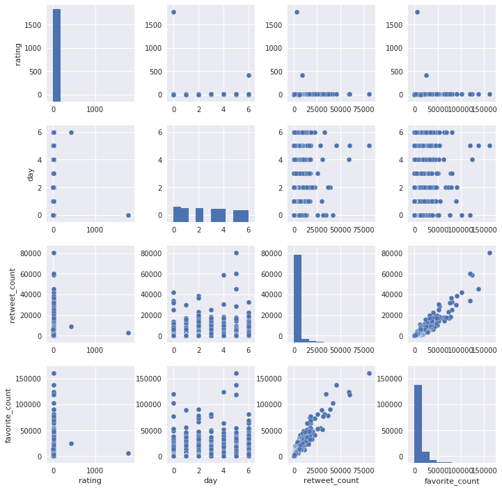

```python
# Overview visual sense of data
sns.pairplot(tweets.select_dtypes(include=[int, float]));
```

#### Insight: What are the Top Dog Names

An overview of popular dog names that appears on WeRateDogs

```python
# Get the top 30 names
# Exclude "dog doe" from query to ensure only valid names appear
names = tweets.query("name != 'dog doe'")
#names.name.value_counts().head(30)
```

[output not shown]

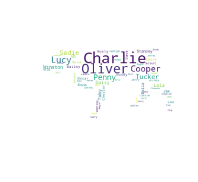

```python
# Create wordcloud for names

# read names to be used in wordcloud
text=" ".join(str(review) for review in tweets['name'])

# Retrieve image from URL programatically
url = "http://www.clker.com/cliparts/0/f/e/b/1433163706283394587dog%20silhoutte%20correct%20direction-md.png"

# mask the png image file
dog_mask = np.array(Image.open(requests.get(url, stream=True).raw))

# Set and add stopwords
#  Exclude dog doe from appearing since it has the highest frequency in name
stopwords = set(STOPWORDS)
stopwords.update(["dog", "doe"])

wc = WordCloud(background_color="white", mode="RGBA", max_words = 100, mask = dog_mask, stopwords=stopwords)

# generate word cloud
wc.generate(text)

#wordcloud in dog shape
plt.figure(figsize=[10,5])
plt.imshow(wc, interpolation="bilinear")
plt.axis("off")

# store to file
wc.to_file('wordcloud_name_dog_shape.png')
```

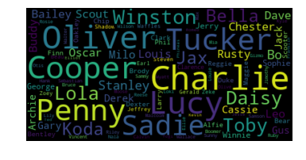

```
Cooper, Oliver, Charlie, Penny, Charlier, Sadie, Tucker are the big ticket holders in the name category
```

```python
#wordcloud without any shape
# This displays a clearer resolution compared to the prior
wc_random = WordCloud(max_font_size=50, max_words=100, background_color="black", stopwords=stopwords).generate(text)
# store to file
wc_random.to_file('wordcloud_name_no_shape.png')

plt.figure(figsize=[10,10])
plt.figure()
plt.imshow(wc_random, interpolation="bilinear")
plt.axis("off")
plt.show()
print('\033[91m\033[1m'"Cooper, Oliver, Charlie, Penny, Charlier, Sadie, Tucker are the big ticket holders in the name category")
```

#### Insight : How Confident is the Neural Network in its Predictions?

This insight shows the neural network's overall and respective confidence level in its predictions

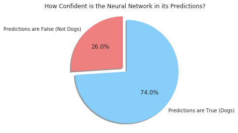

```
It looks like the Neural Network's overall confidence level is high
```

```python
#Plot pie chart to show the neural network's confidence in its overall predictions
values = predictions['dog'].value_counts().head(50)
colors = ['lightskyblue', 'lightcoral']
labels = ['Predictions are True (Dogs)','Predictions are False (Not Dogs)']
explode = (0.1,0)

plt.pie(values,colors=colors,labels=labels,explode=explode,autopct='%1.1f%%',
        counterclock=False, shadow=True, startangle=90)

plt.title('How Confident is the Neural Network in its Predictions?')

plt.axis('equal')
plt.tight_layout()
plt.savefig('confidence_overall.png');
plt.show()
print('\033[91m\033[1m'"It looks like the Neural Network's overall confidence level is high")
```

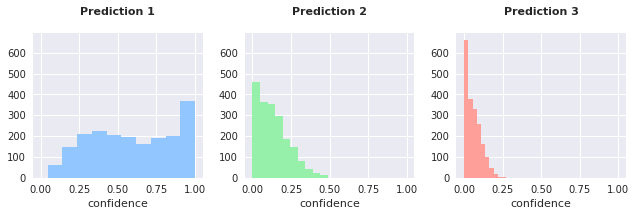

```
Here are the Neural Network's confidence level for each of the predictions.
Looks like Prediction 1 takes the win, having the maximum confidence.
```

```python
# Plot confidence level for the individual predictions
palette=sns.set_palette("pastel")
g=sns.FacetGrid(predictions, col="prediction_order", hue="prediction_order", palette=palette)
g.map(plt.hist, "confidence")
g.set_titles("Prediction {col_name}\n", weight='bold')

plt.savefig('confidence_predictions.png');
plt.show()
print('\033[91m\033[1m'"Here are the Neural Network's confidence level for each of the predictions.")
print ('\033[91m\033[1m'"Looks like Prediction 1 takes the win, having the maximum confidence.")
```

#### Insight : How does the Neural Network fare - What are the Top 50 Predictions?

In essence, this analysis is based on the neural network's predictions labeled as **True** with the highest confidence.

```python
# Create a df to segregate breed predictions that are true, from breed predictions that are false
#  Sort new df by the highest confidence and drop duplicate tweet_id
breeds = predictions.query("dog == True")
breeds= breeds.sort_values('confidence').drop_duplicates(['tweet_id'],keep='last').reset_index(drop=True)
```

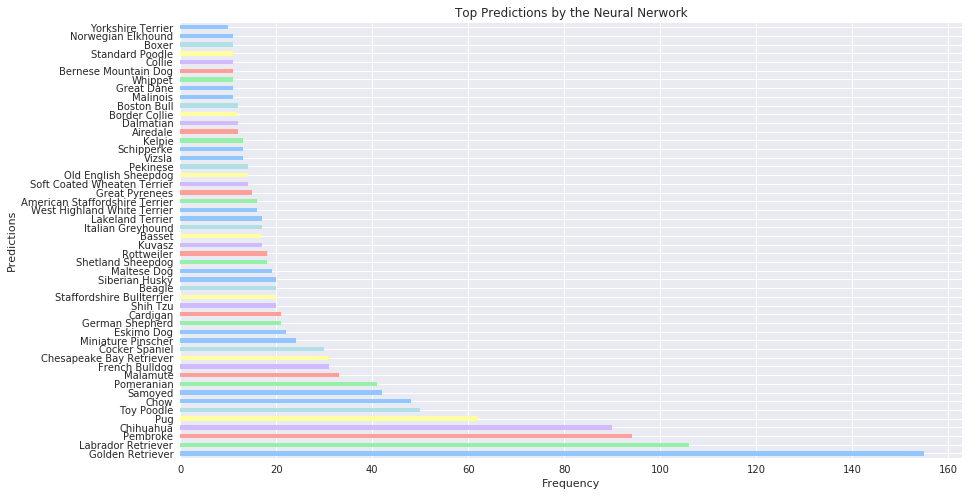

```
Looks like the neural network did well! The top 50 predictions were indeed dog breeds.
```

```python
# Plot a bar chart for the top 50 predictions by the Neural Network
ax = breeds['prediction'].value_counts().head(50).plot(kind='barh',
                                                       figsize=(14,8),
                                                       title="Top Predictions by the Neural Nerwork")
ax.set_xlabel("Frequency")
ax.set_ylabel("Predictions")
plt.show()
plt.savefig('top50_predictions_neural.png');
print('\033[91m\033[1m'"Looks like the neural network did well! The top 50 predictions were indeed dog breeds.")
```